# Table of Contents

**토픽모델링: k-means vs LDA**

- k-means도 토픽 모델링으로 이용 가능 (LDA와 같은 토픽 모델링과 k-means의 차이는 문서의 토픽 개수에 대한 가정)
  - **LDA**는 한 문서에 **여러 종류**의 토픽이 존재할 수 있다 가정
    - 한 영화에 대한 여러 관점의 리뷰 -> 여러 토픽이 섞여있을 수 있음
  - **k-means**는 하나의 문서가 **하나의 토픽**이라 가정
    - 주로 뉴스는 한 기사에 하나의 토픽이 있음
- 따라서, 한 문서에 하나의 토픽이 존재한다고 가정한다면, 굳이 over-spec인 LDA를 이용할 필요는 없음
- 출처: https://lovit.github.io/nlp/2018/09/27/pyldavis_kmeans/

```python
import pandas as pd
import numpy as np

import matplotlib
import matplotlib.pyplot as plt
import seaborn as sns

# 그래프 한글 폰트
from matplotlib import font_manager, rc
font_name = font_manager.FontProperties(fname="c:/Windows/Fonts/malgun.ttf").get_name()
rc('font', family=font_name)

# 그래프 마이너스 폰트 깨지는 문제 대처
import matplotlib as mpl
mpl.rcParams['axes.unicode_minus'] = False

# plotly
import chart_studio
import chart_studio.plotly as py   # import plotly.plotly  => chart_studio.plotly 로 변경됨
import plotly.graph_objects as go
import plotly.express as px
import cufflinks as cf
cf.go_offline(connected=True)
from plotly.subplots import make_subplots
import plotly.io as pio
pio.renderers.default = 'notebook_connected'

# plotly login
chart_studio.tools.set_credentials_file(username='***', api_key='***')

import nltk
from konlpy.tag import Okt
from konlpy.tag import Komoran

from sklearn.feature_extraction.text import CountVectorizer
from sklearn.feature_extraction.text import TfidfVectorizer

from sklearn.cluster import KMeans
```

# 대회 유형별 분류

- 대회 이름, 키워드에 들어가는 단어로 조건화하여, 대회 유형('분류','회귀','시각화' 등) 분류

## 데이터 불러오기 및 필요 컬럼만 남기기

```python
train = pd.read_csv('data/train2.csv', encoding='cp949')
train
```

|  | ds | 사용자 | 세션 | 신규방문자 | 페이지뷰 | year | month | week | holiday | period_start | period_end | merge_deadline |
| --- | --- | --- | --- | --- | --- | --- | --- | --- | --- | --- | --- | --- |
| 0 | 2018-09-09 | 281 | 266 | 73 | 1826 | 2018 | 9 | 6 | 0 | 0 | 0 | 0 |
| 1 | 2018-09-10 | 264 | 247 | 51 | 2092 | 2018 | 9 | 0 | 0 | 0 | 0 | 0 |
| 2 | 2018-09-11 | 329 | 310 | 58 | 1998 | 2018 | 9 | 1 | 0 | 0 | 0 | 0 |
| 3 | 2018-09-12 | 300 | 287 | 45 | 2595 | 2018 | 9 | 2 | 0 | 0 | 0 | 0 |
| 4 | 2018-09-13 | 378 | 344 | 50 | 3845 | 2018 | 9 | 3 | 0 | 0 | 1 | 1 |
| ... | ... | ... | ... | ... | ... | ... | ... | ... | ... | ... | ... | ... |
| 817 | 2020-12-04 | 3189 | 3068 | 743 | 75730 | 2020 | 12 | 4 | 0 | 0 | 1 | 0 |
| 818 | 2020-12-05 | 2055 | 2019 | 497 | 47638 | 2020 | 12 | 5 | 0 | 0 | 0 | 0 |
| 819 | 2020-12-06 | 2119 | 2077 | 460 | 46914 | 2020 | 12 | 6 | 0 | 0 | 0 | 0 |
| 820 | 2020-12-07 | 2979 | 2988 | 753 | 77443 | 2020 | 12 | 0 | 0 | 0 | 0 | 0 |
| 821 | 2020-12-08 | 3033 | 2990 | 772 | 68857 | 2020 | 12 | 1 | 0 | 0 | 0 | 0 |

822 rows × 12 columns

```python
info_compet = pd.read_csv('data/info_compet.csv', encoding='cp949')
info_compet
```

|  | cpt_id | period_start | period_end | name | name_eng | keyword | keyword_eng | participants | max_team_member | max_file_per_day | prize | merge_deadline | winner_show |
| --- | --- | --- | --- | --- | --- | --- | --- | --- | --- | --- | --- | --- | --- |
| 0 | 136.0 | 2018-08-14 | 2018-09-13 | 대출 상점 총 매출 예측 경진대회 | Shop Total Sales Forecast | 금융 \| 소상공인 신용카드 가맹점 빅데이터와 AI로 매출 예측 \| 시계열, 회귀 ... | [Finance] Small Business Credit Card Merchant ... | 321 | 5 | 5 | 850 | 2018-09-13 | 3 |
| 1 | 9565.0 | 2018-09-15 | 2018-10-13 | 병원 개/폐업 분류 예측 경진대회 | hospital opening / closing classification pred... | 금융 \| 병원 재무 데이터와 AI로 개업\|폐업 예측 분석 \| 분류 \| Accuracy | [Financial] Hospital financial data and openin... | 482 | 10 | 3 | 350 | 2018-10-13 | 3 |
| 2 | 17801.0 | 2018-10-18 | 2018-12-31 | 아파트 경매가격 예측 경진대회 | Apartment Auction Price Forecast | 금융 \| 부동산 아파트 경매 빅데이터와 AI로 경매가 예측 분석 \| 회귀 \| RMSE | [Finance] Real Estate Apartment Auction Big Da... | 327 | 10 | 3 | 1000 | 2018-12-31 | 3 |
| 3 | 21265.0 | 2018-11-13 | 2019-01-31 | 아파트 실거래가 예측 | apartment real price forecast | 금융 \| 부동산 빅데이터와 AI를 이용하여 실거래가를 예측 분석 \| 회귀 \| RMSE | [Finance] Predictive analysis of real transact... | 584 | 10 | 3 | 800 | 2019-01-31 | 3 |
| 4 | 42473.0 | 2018-12-25 | 2019-01-10 | 신용카드 거래 데이터 시각화 | credit card transaction data visualization | 금융 \| 신용카드, 시계열, 시각화 \| Python, R, Tableau, Spot... | [Finance] Credit cards, time series, visualiza... | 270 | 5 | 3 | 100 | 2019-01-10 | 3 |
| 5 | 62540.0 | 2019-02-08 | 2019-07-18 | KBO 타자 OPS 예측 경진대회 | KBO batter OPS modeling | 스포츠 \| KBO 타자 빅데이터와 AI로 OPS 예측 \| 시계열, 회귀 \| RMSE... | [Sports] KBO hitter big data and AI predict OP... | 354 | 5 | 3 | 800 | 2019-07-18 | 3 |
| 6 | 68346.0 | 2019-03-26 | 2019-05-20 | KBO 외국인 투수 스카우팅 최적화 경진대회 | KBO foreign pitcher scouting optimization | 스포츠 \| MLB 데이터와 AI를 이용 투수 스카우트 분석 \| KBO, 회귀 \| ... | [Sports] Pitcher Scout Analysis using MLB data... | 105 | 1 | 3 | 200 | 2019-05-20 | 3 |
| 7 | 82407.0 | 2019-05-06 | 2019-07-08 | KCB 금융스타일 시각화 경진대회 | KCB Financial Style Visualization Contest | 금융 \| 구인 \| 개인 신용카드 빅데이터 AI 분석 시각화 \| Python, R, ... | Finance \| Job offer \| Analysis visualization w... | 277 | 5 | 3 | 1000 | 2019-07-08 | 3 |
| 8 | 140472.0 | 2019-07-11 | 2019-10-21 | 상점 신용카드 매출 예측 경진대회 | Store Credit Card Sales Forecast Contest | 금융 \| 구인 \| 소상공인 가맹점 신용카드 빅데이터와 AI로 매출 예측 분석 \| 시... | [Finance, Job Offers] Small business merchant ... | 652 | 5 | 15 | 200 | NaN | 3 |
| 9 | 196878.0 | 2019-10-01 | 2019-10-27 | 전력 수요량 예측 경진대회 | Electric Power Demand Forecast Contest | 공공 \| 전력 기상 빅데이터와 AI로 수요량 분석 \| 시계열, 회귀 \| SMAPE | [Public] Analyzing demand by power weather big... | 502 | 4 | 3 | 600 | 2019-10-27 | 3 |
| 10 | 229255.0 | 2019-11-11 | 2019-12-06 | 퇴근시간 버스승차인원 예측 경진대회 | Bus Time Estimated Contest | 교통 \| 제주시 \| 공공 교통 위치 빅데이터와 AI로 버스 승객 이용 분석 \| 회귀... | Transportation \| Bus transportation use analys... | 923 | 5 | 10 | 700 | NaN | 3 |
| 11 | 229611.0 | 2019-11-11 | 2019-12-06 | 버스 운행시간 예측 경진대회 | Bus time prediction competition | 교통 \| 공공 교통 위치 빅데이터와 AI로 버스 운행 시간 분석 \| 회귀 \| RMSE | [Transport] Public transportation location Big... | 412 | 5 | 10 | 300 | 2019-12-06 | 3 |
| 12 | 235401.0 | 2019-11-21 | 2020-01-12 | 금융 문자 분석 경진대회 | Financial Character Analysis Contest | 금융 \| KB금융그룹 \| 금융 Mobile 문자 빅데이터와 AI로 스팸을 분류 \| ... | Finance \| Classify Spam by Financial Mobile Ch... | 944 | 5 | 3 | 2000 | 2020-01-12 | 3 |
| 13 | 235492.0 | 2019-11-20 | 2020-03-20 | 위성 이미지 객체 검출 경진대회 | Satellite Image Object Detection Contest | 국방 \| 국방과학연구소 \| 항공우주 빅데이터와 AI를 이용하여 이미지를 분석 \| 위... | [Defense] Analyze images using aerospace big d... | 354 | 5 | 5 | 0 | 2020-03-20 | 3 |
| 14 | 235546.0 | 2019-02-05 | 2019-07-19 | KBO 타자 OPS 시각화 경진대회 | KBO batter OPS visualization | 스포츠 \| 스포츠 빅데이터와 AI를 이용하여 타자 OPS 예측 시각화 \| Pytho... | [Sports] Visualizing batter OPS predictions us... | 184 | 5 | 3 | 200 | 2019-07-19 | 3 |
| 15 | 235551.0 | 2020-01-16 | 2020-02-12 | 원자력발전소 상태 판단 경진대회 | Nuclear Power Plant Status Contest Competition | 산업 \| 한국수력원자력 \| 발전소 빅데이터, AI 활용 발전소 상태 분류 \| Log... | Industry \| Nuclear power plants sort thousands... | 1149 | 5 | 3 | 1000 | 2020-02-12 | 5 |
| 16 | 235554.0 | 2020-01-02 | 2020-02-02 | 반도체 박막 두께 분석 경진대회 | Semiconductor thin film thickness analysis con... | 월간 데이콘 1 \| 산업 \| 반도체 광스펙트럼 빅데이터와 AI로 박막 두께 측정 \|... | Monthly Daycon 1 \| Industry \| Thin film thickn... | 866 | 3 | 15 | 83 | 2020-02-02 | 3 |
| 17 | 235573.0 | 2020-02-01 | 2020-02-29 | 천체 유형 분류 대회 | Astro Type Classification Competition | 월간 데이콘 2 \| 과학 \| 슬론 디지털 천체 관측 빅데이터와 AI로 천체 분류 ... | Monthly Daycon 2 \| Science \| Sloane Digital As... | 918 | 3 | 10 | 154 | 2020-02-29 | 3 |
| 18 | 235583.0 | 2020-03-01 | 2020-04-15 | 행동 데이터 분석 인공지능 AI 경진대회 | Behavior Data Analysis Contest | 월간 데이콘 3 \| 게임 \| 스타크래프트2 게임 빅데이터와 AI를 활용 승패 예측... | Monthly Day 3 \| Games \| StarCraft 2 game big d... | 903 | 3 | 3 | 100 | 2020-03-31 | 3 |
| 19 | 235584.0 | 2020-03-01 | 2020-04-13 | 공공 데이터 활용 온도 추정 AI 경진대회 | Public data utilization temperature estimation... | AI프렌즈 시즌1 \| 기상 \| 한국기계연구원 \| 지역별 Small 공공 데이터와 ... | AI Friends Season 1 \| Weather \| Creating 'My M... | 1197 | 5 | 10 | 250 | 2020-03-29 | 3 |
| 20 | 235585.0 | 2020-10-20 | 2020-11-16 | 랜드마크 분류 AI 경진대회 | pandas tutorial | 컴퓨터 비전 \| 이미지 분류 \| GAP | NaN | 398 | 5 | 5 | 1500 | 2020-10-31 | 3 |
| 21 | 235590.0 | 2020-03-29 | 2020-05-10 | 코로나 데이터 시각화 AI 경진대회 | Corona Data Visualization Contest | 월간 데이콘 4 \| 의료 \| 마이크로소프트 \| 코로나 빅데이터를 AI로 시각화 \|... | Monthly Daycon 4 \| Medical \| Visualize Corona ... | 1793 | 5 | 10 | 250 | 2020-05-03 | 10 |
| 22 | 235591.0 | 2020-04-01 | 2020-05-25 | 위성관측 데이터 활용 강수량 산출 AI 경진대회 | Precipitation calculation contest using satell... | AI프렌즈 2 \| 기상 \| 한국원자력연구원 \| 위성 이미지 빅데이터와 인공지능 ... | AI Friends Season 2 \| Weather \| Satellite imag... | 802 | 5 | 10 | 250 | 2020-05-06 | 3 |
| 23 | 235606.0 | 2020-05-01 | 2020-05-25 | 공공 데이터 활용 전력수요 및 SMP 예측 AI 경진대회 | Electric Data Utilization Electric Power Deman... | AI프렌즈 시즌3 \| 에너지 \| 한국전력연구원 \| 공공 데이터 AI를 활용 전력 ... | AI Friends Season 3 \| Energy \| Predicting futu... | 431 | 5 | 10 | 250 | 2020-05-15 | 3 |
| 24 | 235608.0 | 2020-05-15 | 2020-06-26 | 생체 광학 데이터 분석 AI 경진대회 | Bio-optical Data Analysis Contest | 월간 데이콘 5 \| 바이오 \| 코리아스타트업포럼 \| 인공지능 AI 활용 생체 광학 ... | Monthly Daycon 5 \| Bio \| AI-assisted bio-optic... | 781 | 3 | 10 | 360 | 2020-06-11 | 10 |
| 25 | 235612.0 | 2020-06-01 | 2020-06-30 | 블럭 장난감 제조 공정 최적화 AI경진대회 | NaN | 산업 \| LG \| 인공지능 AI 활용 제조 공정 최적화 알고리즘 \| 강화학습 | NaN | 665 | 5 | 10 | 600 | 2020-06-20 | 3 |
| 26 | 235614.0 | 2020-06-01 | 2020-07-10 | 진동데이터 활용 충돌체 탐지 AI 경진대회 | NaN | 산업 \| 한국원자력연구원 \| 인공지능 AI 활용 충돌체 탐지 알고리즘 \| MSPE | NaN | 668 | 5 | 3 | 600 | 2020-06-26 | 3 |
| 27 | 235615.0 | 2020-06-22 | 2020-07-31 | 제주 신용카드 빅데이터 경진대회 | NaN | 금융 \| 제주테크노파크 \| 공공데이터 AI 활용 카드 사용량 예측 \| RMSLE | NaN | 1555 | 5 | 3 | 600 | 2020-07-17 | 3 |
| 28 | 235616.0 | 2020-06-25 | 2020-08-14 | 음성 중첩 데이터 분류 AI 경진대회 | NaN | 월간 데이콘 6 \| 소리 \| 인공지능 AI 활용 목소리 분류 알고리즘 \| KL Di... | NaN | 445 | 3 | 3 | 103 | 2020-07-24 | 3 |
| 29 | 235618.0 | 2020-07-01 | 2020-07-31 | 포스트 코로나 데이터 시각화 경진대회 | NaN | KT \| 유동인구 \| 소비 \| 포스트 코로나 \| 투표 및 심사 평가 | NaN | 2017 | 5 | 15 | 600 | 2020-07-20 | 10 |
| 30 | 235622.0 | 2020-07-14 | 2020-09-04 | 국토교통 빅데이터 온라인 해커톤 경진대회 | NaN | 국토교통부 \| 빅데이터 \| 포스트코로나 \| 시각화 \| 투표 및 심사평가 | NaN | 966 | 5 | 10 | 1100 | 2020-09-04 | 5 |
| 31 | 235624.0 | 2020-08-17 | 2020-09-29 | 산업제어시스템 보안위협 탐지 AI 경진대회 | NaN | 산업 \| 국가보안기술연구소 \| 인공지능 AI 활용 위협 탐지 알고리즘 \| TaPR ... | NaN | 919 | 5 | 3 | 2000 | 2020-09-14 | 5 |
| 32 | 235626.0 | 2020-08-03 | 2020-09-14 | 컴퓨터 비전 학습 경진대회 | NaN | 월간 데이콘 7 \| 글자에 숨겨진 숫자 이미지 예측 \| MNIST \| Accura... | NaN | 970 | 3 | 3 | 100 | 2020-08-31 | 10 |
| 33 | 235640.0 | 2020-09-01 | 2020-10-09 | 분자구조 이미지 SMILES 변환 AI 경진대회 | NaN | 산업 \| LG \| 화학분자 이미지 텍스트 변환 SMILES \| Similarity | NaN | 574 | 5 | 3 | 1000 | 2020-09-26 | 3 |
| 34 | 235644.0 | 2020-09-23 | 2020-10-30 | 아리랑 위성영상 AI 객체 검출 경진대회 | NaN | 컴퓨터 비전 \| 객체 검출 \| mAP | NaN | 424 | 5 | 5 | 1000 | 2020-10-18 | 3 |
| 35 | 235646.0 | 2020-10-05 | 2020-11-13 | 공공데이터 활용 수력 댐 강우예측 AI 경진대회 | NaN | 한국수력원자력 \| 강우예측 \| MAE/CSI | NaN | 462 | 5 | 3 | 1100 | 2020-11-13 | 3 |
| 36 | 235647.0 | 2020-09-28 | 2020-11-16 | 심리 성향 예측 AI 경진대회 | NaN | 월간 데이콘 8 \| 심리 테스트 분석 \| AUC \| 분류 | NaN | 1298 | 3 | 3 | 100 | 2020-11-02 | 11 |
| 37 | 235655.0 | 2020-10-19 | 2020-11-19 | 딥페이크 변조 영상 탐지 AI 경진대회 | NaN | 서울대 \| 영상 \| GAN \| 분류 \| Accuracy | NaN | 331 | 5 | 3 | 1000 | 2020-11-14 | 3 |
| 38 | 235658.0 | 2020-11-23 | 2020-12-31 | AI야 , 진짜 뉴스를 찾아줘! AI 경진대회 | NaN | 금융 \| NH투자증권 \| 텍스트 분류 \| Accuracy + Time \| 중복 참가... | NaN | 544 | 3 | 3 | 2500 | 2020-12-18 | 3 |
| 39 | 235663.0 | 2020-11-23 | 2020-12-31 | Y&Z세대 투자자 프로파일링 시각화 경진대회 | NaN | 금융 \| NH투자증권 \| 시각화 \| 투표 및 심사평가 \| 중복참가 불가, 대학 재학... | NaN | 473 | 3 | 10 | 2500 | 2020-12-31 | 3 |
| 40 | 235668.0 | 2020-10-29 | 2020-11-13 | 꿈꾸는아이(AI) 전력 수요량 예측 경진대회 | NaN | 전력 수요량 \| 시계열 \| SMAPE | NaN | 87 | 4 | 3 | 4850 | 2020-11-13 | 1 |
| 41 | 235670.0 | 2020-10-29 | 2020-12-04 | 소설 작가 분류 AI 경진대회 | NaN | 월간 데이콘 9 \| 소설 문체 \| NLP \| Logloss | NaN | 707 | 10 | 3 | 100 | 2020-11-27 | 11 |
| 42 | 235671.0 | 2020-11-11 | 2020-12-09 | 한국어 문서 추출요약 AI 경진대회 | NaN | Bflysoft \| 추출 요약 \| ROUGE-N | NaN | 419 | 5 | 3 | 1000 | 2020-11-25 | 3 |
| 43 | 235672.0 | 2020-11-02 | 2020-11-20 | K-Fashion AI 경진대회 | NaN | 컴퓨터 비전 \| 이미지 세분화 \| mAP | NaN | 381 | 5 | 5 | 1000 | 2020-11-17 | 3 |
| 44 | 235673.0 | 2020-11-11 | 2020-12-09 | 한국어 문서 생성요약 AI 경진대회 | NaN | Bflysoft \| 생성 요약 \| ROUGE-N | NaN | 263 | 5 | 3 | 1000 | 2020-11-25 | 3 |
| 45 | 235679.0 | 2020-11-24 | 2020-12-28 | 국회 입법활동 빅데이터 시각화 경진대회 | NaN | 월간 데이콘 10 \| 입법 \| 시각화 \| 유저평가 | NaN | 498 | 3 | 3 | 100 | 2020-12-15 | 3 |
| 46 | 235680.0 | 2020-12-09 | 2021-01-26 | 태양광 발전량 예측 AI 경진대회 | NaN | 태양광 발전량 \| 시계열ㅣPinball Loss | NaN | 1318 | 4 | 3 | 600 | 2021-01-11 | 3 |
| 47 | 235682.0 | 2020-12-14 | 2020-12-27 | 공간정보 탐색적 데이터 분석 경진대회 | NaN | 국토도시 빅데이터 윈터스쿨 \| 국토연구원 \| 시각화 \| 유저평가 | NaN | 409 | 10 | 10 | 100 | 2020-12-23 | 3 |
| 48 | 235683.0 | 2020-12-18 | 2021-01-22 | 2020 DACON CUP | NaN | 월간 데이콘 \| 시계열 \| 정형 \| 데이콘 데이터 | NaN | 420 | 3 | 3 | 100 | 2021-01-11 | 10 |
| 49 | 235687.0 | 2021-01-06 | 2021-02-03 | 시스템 품질 변화로 인한 사용자 불편 예지 AI 경진대회 | NaN | LG \| 채용 \| 시스템 \| 사용자 불편 \| 정형 \| AUC | NaN | 1207 | 5 | 3 | 1000 | 2021-01-24 | 3 |

```python
compet_start = info_compet[['period_start','prize','name','keyword']].copy()
compet_start
```

|  | period_start | prize | name | keyword |
| --- | --- | --- | --- | --- |
| 0 | 2018-08-14 | 850 | 대출 상점 총 매출 예측 경진대회 | 금융 \| 소상공인 신용카드 가맹점 빅데이터와 AI로 매출 예측 \| 시계열, 회귀 ... |
| 1 | 2018-09-15 | 350 | 병원 개/폐업 분류 예측 경진대회 | 금융 \| 병원 재무 데이터와 AI로 개업\|폐업 예측 분석 \| 분류 \| Accuracy |
| 2 | 2018-10-18 | 1000 | 아파트 경매가격 예측 경진대회 | 금융 \| 부동산 아파트 경매 빅데이터와 AI로 경매가 예측 분석 \| 회귀 \| RMSE |
| 3 | 2018-11-13 | 800 | 아파트 실거래가 예측 | 금융 \| 부동산 빅데이터와 AI를 이용하여 실거래가를 예측 분석 \| 회귀 \| RMSE |
| 4 | 2018-12-25 | 100 | 신용카드 거래 데이터 시각화 | 금융 \| 신용카드, 시계열, 시각화 \| Python, R, Tableau, Spot... |
| 5 | 2019-02-08 | 800 | KBO 타자 OPS 예측 경진대회 | 스포츠 \| KBO 타자 빅데이터와 AI로 OPS 예측 \| 시계열, 회귀 \| RMSE... |
| 6 | 2019-03-26 | 200 | KBO 외국인 투수 스카우팅 최적화 경진대회 | 스포츠 \| MLB 데이터와 AI를 이용 투수 스카우트 분석 \| KBO, 회귀 \| ... |
| 7 | 2019-05-06 | 1000 | KCB 금융스타일 시각화 경진대회 | 금융 \| 구인 \| 개인 신용카드 빅데이터 AI 분석 시각화 \| Python, R, ... |
| 8 | 2019-07-11 | 200 | 상점 신용카드 매출 예측 경진대회 | 금융 \| 구인 \| 소상공인 가맹점 신용카드 빅데이터와 AI로 매출 예측 분석 \| 시... |
| 9 | 2019-10-01 | 600 | 전력 수요량 예측 경진대회 | 공공 \| 전력 기상 빅데이터와 AI로 수요량 분석 \| 시계열, 회귀 \| SMAPE |
| 10 | 2019-11-11 | 700 | 퇴근시간 버스승차인원 예측 경진대회 | 교통 \| 제주시 \| 공공 교통 위치 빅데이터와 AI로 버스 승객 이용 분석 \| 회귀... |
| 11 | 2019-11-11 | 300 | 버스 운행시간 예측 경진대회 | 교통 \| 공공 교통 위치 빅데이터와 AI로 버스 운행 시간 분석 \| 회귀 \| RMSE |
| 12 | 2019-11-21 | 2000 | 금융 문자 분석 경진대회 | 금융 \| KB금융그룹 \| 금융 Mobile 문자 빅데이터와 AI로 스팸을 분류 \| ... |
| 13 | 2019-11-20 | 0 | 위성 이미지 객체 검출 경진대회 | 국방 \| 국방과학연구소 \| 항공우주 빅데이터와 AI를 이용하여 이미지를 분석 \| 위... |
| 14 | 2019-02-05 | 200 | KBO 타자 OPS 시각화 경진대회 | 스포츠 \| 스포츠 빅데이터와 AI를 이용하여 타자 OPS 예측 시각화 \| Pytho... |
| 15 | 2020-01-16 | 1000 | 원자력발전소 상태 판단 경진대회 | 산업 \| 한국수력원자력 \| 발전소 빅데이터, AI 활용 발전소 상태 분류 \| Log... |
| 16 | 2020-01-02 | 83 | 반도체 박막 두께 분석 경진대회 | 월간 데이콘 1 \| 산업 \| 반도체 광스펙트럼 빅데이터와 AI로 박막 두께 측정 \|... |
| 17 | 2020-02-01 | 154 | 천체 유형 분류 대회 | 월간 데이콘 2 \| 과학 \| 슬론 디지털 천체 관측 빅데이터와 AI로 천체 분류 ... |
| 18 | 2020-03-01 | 100 | 행동 데이터 분석 인공지능 AI 경진대회 | 월간 데이콘 3 \| 게임 \| 스타크래프트2 게임 빅데이터와 AI를 활용 승패 예측... |
| 19 | 2020-03-01 | 250 | 공공 데이터 활용 온도 추정 AI 경진대회 | AI프렌즈 시즌1 \| 기상 \| 한국기계연구원 \| 지역별 Small 공공 데이터와 ... |
| 20 | 2020-10-20 | 1500 | 랜드마크 분류 AI 경진대회 | 컴퓨터 비전 \| 이미지 분류 \| GAP |
| 21 | 2020-03-29 | 250 | 코로나 데이터 시각화 AI 경진대회 | 월간 데이콘 4 \| 의료 \| 마이크로소프트 \| 코로나 빅데이터를 AI로 시각화 \|... |
| 22 | 2020-04-01 | 250 | 위성관측 데이터 활용 강수량 산출 AI 경진대회 | AI프렌즈 2 \| 기상 \| 한국원자력연구원 \| 위성 이미지 빅데이터와 인공지능 ... |
| 23 | 2020-05-01 | 250 | 공공 데이터 활용 전력수요 및 SMP 예측 AI 경진대회 | AI프렌즈 시즌3 \| 에너지 \| 한국전력연구원 \| 공공 데이터 AI를 활용 전력 ... |
| 24 | 2020-05-15 | 360 | 생체 광학 데이터 분석 AI 경진대회 | 월간 데이콘 5 \| 바이오 \| 코리아스타트업포럼 \| 인공지능 AI 활용 생체 광학 ... |
| 25 | 2020-06-01 | 600 | 블럭 장난감 제조 공정 최적화 AI경진대회 | 산업 \| LG \| 인공지능 AI 활용 제조 공정 최적화 알고리즘 \| 강화학습 |
| 26 | 2020-06-01 | 600 | 진동데이터 활용 충돌체 탐지 AI 경진대회 | 산업 \| 한국원자력연구원 \| 인공지능 AI 활용 충돌체 탐지 알고리즘 \| MSPE |
| 27 | 2020-06-22 | 600 | 제주 신용카드 빅데이터 경진대회 | 금융 \| 제주테크노파크 \| 공공데이터 AI 활용 카드 사용량 예측 \| RMSLE |
| 28 | 2020-06-25 | 103 | 음성 중첩 데이터 분류 AI 경진대회 | 월간 데이콘 6 \| 소리 \| 인공지능 AI 활용 목소리 분류 알고리즘 \| KL Di... |
| 29 | 2020-07-01 | 600 | 포스트 코로나 데이터 시각화 경진대회 | KT \| 유동인구 \| 소비 \| 포스트 코로나 \| 투표 및 심사 평가 |
| 30 | 2020-07-14 | 1100 | 국토교통 빅데이터 온라인 해커톤 경진대회 | 국토교통부 \| 빅데이터 \| 포스트코로나 \| 시각화 \| 투표 및 심사평가 |
| 31 | 2020-08-17 | 2000 | 산업제어시스템 보안위협 탐지 AI 경진대회 | 산업 \| 국가보안기술연구소 \| 인공지능 AI 활용 위협 탐지 알고리즘 \| TaPR ... |
| 32 | 2020-08-03 | 100 | 컴퓨터 비전 학습 경진대회 | 월간 데이콘 7 \| 글자에 숨겨진 숫자 이미지 예측 \| MNIST \| Accura... |
| 33 | 2020-09-01 | 1000 | 분자구조 이미지 SMILES 변환 AI 경진대회 | 산업 \| LG \| 화학분자 이미지 텍스트 변환 SMILES \| Similarity |
| 34 | 2020-09-23 | 1000 | 아리랑 위성영상 AI 객체 검출 경진대회 | 컴퓨터 비전 \| 객체 검출 \| mAP |
| 35 | 2020-10-05 | 1100 | 공공데이터 활용 수력 댐 강우예측 AI 경진대회 | 한국수력원자력 \| 강우예측 \| MAE/CSI |
| 36 | 2020-09-28 | 100 | 심리 성향 예측 AI 경진대회 | 월간 데이콘 8 \| 심리 테스트 분석 \| AUC \| 분류 |
| 37 | 2020-10-19 | 1000 | 딥페이크 변조 영상 탐지 AI 경진대회 | 서울대 \| 영상 \| GAN \| 분류 \| Accuracy |
| 38 | 2020-11-23 | 2500 | AI야 , 진짜 뉴스를 찾아줘! AI 경진대회 | 금융 \| NH투자증권 \| 텍스트 분류 \| Accuracy + Time \| 중복 참가... |
| 39 | 2020-11-23 | 2500 | Y&Z세대 투자자 프로파일링 시각화 경진대회 | 금융 \| NH투자증권 \| 시각화 \| 투표 및 심사평가 \| 중복참가 불가, 대학 재학... |
| 40 | 2020-10-29 | 4850 | 꿈꾸는아이(AI) 전력 수요량 예측 경진대회 | 전력 수요량 \| 시계열 \| SMAPE |
| 41 | 2020-10-29 | 100 | 소설 작가 분류 AI 경진대회 | 월간 데이콘 9 \| 소설 문체 \| NLP \| Logloss |
| 42 | 2020-11-11 | 1000 | 한국어 문서 추출요약 AI 경진대회 | Bflysoft \| 추출 요약 \| ROUGE-N |
| 43 | 2020-11-02 | 1000 | K-Fashion AI 경진대회 | 컴퓨터 비전 \| 이미지 세분화 \| mAP |
| 44 | 2020-11-11 | 1000 | 한국어 문서 생성요약 AI 경진대회 | Bflysoft \| 생성 요약 \| ROUGE-N |
| 45 | 2020-11-24 | 100 | 국회 입법활동 빅데이터 시각화 경진대회 | 월간 데이콘 10 \| 입법 \| 시각화 \| 유저평가 |
| 46 | 2020-12-09 | 600 | 태양광 발전량 예측 AI 경진대회 | 태양광 발전량 \| 시계열ㅣPinball Loss |
| 47 | 2020-12-14 | 100 | 공간정보 탐색적 데이터 분석 경진대회 | 국토도시 빅데이터 윈터스쿨 \| 국토연구원 \| 시각화 \| 유저평가 |
| 48 | 2020-12-18 | 100 | 2020 DACON CUP | 월간 데이콘 \| 시계열 \| 정형 \| 데이콘 데이터 |
| 49 | 2021-01-06 | 1000 | 시스템 품질 변화로 인한 사용자 불편 예지 AI 경진대회 | LG \| 채용 \| 시스템 \| 사용자 불편 \| 정형 \| AUC |

```python
# name, keyword 합친 후, 조건화 해서 대회 유형 분류
compet_start['document'] = compet_start['name'] + ' ' + compet_start['keyword']
```

## 대회 유형 분류

```python
# 수정된 조건 - 분류, 회귀, 시각화, 이미지/영상/음성 식별, 이상탐지, 문서 요약, 공정 최적화
compet_start['type'] = np.nan

for i in compet_start.index:
    # 시각화
    if '시각화' in compet_start['document'][i]:
        if ('분류' not in compet_start['document'][i]) and ('예측' not in compet_start['document'][i]):
            compet_start.loc[i, 'type'] = '시각화'
        elif ('예측' in compet_start['document'][i]) or ('회귀' in compet_start['document'][i]):
            compet_start.loc[i, 'type'] = '회귀'
        elif '분류' in compet_start['document'][i]:
            compet_start.loc[i, 'type'] = '분류'
    # 이미지/영상/음성 식별
    elif ('이미지' in compet_start['document'][i]) or ('영상' in compet_start['document'][i]) or ('음성' in compet_start['document'][i]):
        compet_start.loc[i, 'type'] = '이미지/영상/음성 식별'
    # 문서 요약
    elif '문서' in compet_start['document'][i]:
        compet_start.loc[i, 'type'] = '문서 요약'
    # 이상탐지
    elif '탐지 알고리즘' in compet_start['document'][i]:
        compet_start.loc[i, 'type'] = '이상 탐지'
    # 공정 최적화
    elif '공정' in compet_start['document'][i]:
        compet_start.loc[i, 'type'] = '공정 최적화'
    # 회귀
    elif ('예측' in compet_start['document'][i]) or ('회귀' in compet_start['document'][i]) or ('정형' in compet_start['document'][i]):
        if ('분류' not in compet_start['document'][i]):
            compet_start.loc[i, 'type'] = '회귀'
        else:
            compet_start.loc[i, 'type'] = '분류'
    elif ('MAE' in compet_start['document'][i]) or ('MSE' in compet_start['document'][i]):
        compet_start.loc[i, 'type'] = '회귀'
    # 분류
    elif '분류' in compet_start['document'][i]:
        compet_start.loc[i, 'type'] = '분류'
```

```python
compet_start[compet_start['type'].isnull()]
```

|  | period_start | prize | name | keyword | document | type |
| --- | --- | --- | --- | --- | --- | --- |

```python
compet_start['type'].value_counts()
```

```
회귀              21
이미지/영상/음성 식별     9
시각화              8
분류               7
문서 요약            2
이상 탐지            2
공정 최적화           1
Name: type, dtype: int64
```

```python
# 확인
compet_start.sort_values(by='period_start')
```

|  | period_start | prize | name | keyword | document | type |
| --- | --- | --- | --- | --- | --- | --- |
| 0 | 2018-08-14 | 850 | 대출 상점 총 매출 예측 경진대회 | 금융 \| 소상공인 신용카드 가맹점 빅데이터와 AI로 매출 예측 \| 시계열, 회귀 ... | 대출 상점 총 매출 예측 경진대회 금융 \| 소상공인 신용카드 가맹점 빅데이터와 AI... | 회귀 |
| 1 | 2018-09-15 | 350 | 병원 개/폐업 분류 예측 경진대회 | 금융 \| 병원 재무 데이터와 AI로 개업\|폐업 예측 분석 \| 분류 \| Accuracy | 병원 개/폐업 분류 예측 경진대회 금융 \| 병원 재무 데이터와 AI로 개업\|폐업 예... | 분류 |
| 2 | 2018-10-18 | 1000 | 아파트 경매가격 예측 경진대회 | 금융 \| 부동산 아파트 경매 빅데이터와 AI로 경매가 예측 분석 \| 회귀 \| RMSE | 아파트 경매가격 예측 경진대회 금융 \| 부동산 아파트 경매 빅데이터와 AI로 경매가... | 회귀 |
| 3 | 2018-11-13 | 800 | 아파트 실거래가 예측 | 금융 \| 부동산 빅데이터와 AI를 이용하여 실거래가를 예측 분석 \| 회귀 \| RMSE | 아파트 실거래가 예측 금융 \| 부동산 빅데이터와 AI를 이용하여 실거래가를 예측 분... | 회귀 |
| 4 | 2018-12-25 | 100 | 신용카드 거래 데이터 시각화 | 금융 \| 신용카드, 시계열, 시각화 \| Python, R, Tableau, Spot... | 신용카드 거래 데이터 시각화 금융 \| 신용카드, 시계열, 시각화 \| Python, ... | 시각화 |
| 14 | 2019-02-05 | 200 | KBO 타자 OPS 시각화 경진대회 | 스포츠 \| 스포츠 빅데이터와 AI를 이용하여 타자 OPS 예측 시각화 \| Pytho... | KBO 타자 OPS 시각화 경진대회 스포츠 \| 스포츠 빅데이터와 AI를 이용하여 타... | 회귀 |
| 5 | 2019-02-08 | 800 | KBO 타자 OPS 예측 경진대회 | 스포츠 \| KBO 타자 빅데이터와 AI로 OPS 예측 \| 시계열, 회귀 \| RMSE... | KBO 타자 OPS 예측 경진대회 스포츠 \| KBO 타자 빅데이터와 AI로 OPS ... | 회귀 |
| 6 | 2019-03-26 | 200 | KBO 외국인 투수 스카우팅 최적화 경진대회 | 스포츠 \| MLB 데이터와 AI를 이용 투수 스카우트 분석 \| KBO, 회귀 \| ... | KBO 외국인 투수 스카우팅 최적화 경진대회 스포츠 \| MLB 데이터와 AI를 이... | 회귀 |
| 7 | 2019-05-06 | 1000 | KCB 금융스타일 시각화 경진대회 | 금융 \| 구인 \| 개인 신용카드 빅데이터 AI 분석 시각화 \| Python, R, ... | KCB 금융스타일 시각화 경진대회 금융 \| 구인 \| 개인 신용카드 빅데이터 AI 분... | 시각화 |
| 8 | 2019-07-11 | 200 | 상점 신용카드 매출 예측 경진대회 | 금융 \| 구인 \| 소상공인 가맹점 신용카드 빅데이터와 AI로 매출 예측 분석 \| 시... | 상점 신용카드 매출 예측 경진대회 금융 \| 구인 \| 소상공인 가맹점 신용카드 빅데이... | 회귀 |
| 9 | 2019-10-01 | 600 | 전력 수요량 예측 경진대회 | 공공 \| 전력 기상 빅데이터와 AI로 수요량 분석 \| 시계열, 회귀 \| SMAPE | 전력 수요량 예측 경진대회 공공 \| 전력 기상 빅데이터와 AI로 수요량 분석 \| 시... | 회귀 |
| 11 | 2019-11-11 | 300 | 버스 운행시간 예측 경진대회 | 교통 \| 공공 교통 위치 빅데이터와 AI로 버스 운행 시간 분석 \| 회귀 \| RMSE | 버스 운행시간 예측 경진대회 교통 \| 공공 교통 위치 빅데이터와 AI로 버스 운행 ... | 회귀 |
| 10 | 2019-11-11 | 700 | 퇴근시간 버스승차인원 예측 경진대회 | 교통 \| 제주시 \| 공공 교통 위치 빅데이터와 AI로 버스 승객 이용 분석 \| 회귀... | 퇴근시간 버스승차인원 예측 경진대회 교통 \| 제주시 \| 공공 교통 위치 빅데이터와 ... | 회귀 |
| 13 | 2019-11-20 | 0 | 위성 이미지 객체 검출 경진대회 | 국방 \| 국방과학연구소 \| 항공우주 빅데이터와 AI를 이용하여 이미지를 분석 \| 위... | 위성 이미지 객체 검출 경진대회 국방 \| 국방과학연구소 \| 항공우주 빅데이터와 AI... | 이미지/영상/음성 식별 |
| 12 | 2019-11-21 | 2000 | 금융 문자 분석 경진대회 | 금융 \| KB금융그룹 \| 금융 Mobile 문자 빅데이터와 AI로 스팸을 분류 \| ... | 금융 문자 분석 경진대회 금융 \| KB금융그룹 \| 금융 Mobile 문자 빅데이터와... | 분류 |
| 16 | 2020-01-02 | 83 | 반도체 박막 두께 분석 경진대회 | 월간 데이콘 1 \| 산업 \| 반도체 광스펙트럼 빅데이터와 AI로 박막 두께 측정 \|... | 반도체 박막 두께 분석 경진대회 월간 데이콘 1 \| 산업 \| 반도체 광스펙트럼 빅데... | 회귀 |
| 15 | 2020-01-16 | 1000 | 원자력발전소 상태 판단 경진대회 | 산업 \| 한국수력원자력 \| 발전소 빅데이터, AI 활용 발전소 상태 분류 \| Log... | 원자력발전소 상태 판단 경진대회 산업 \| 한국수력원자력 \| 발전소 빅데이터, AI ... | 분류 |
| 17 | 2020-02-01 | 154 | 천체 유형 분류 대회 | 월간 데이콘 2 \| 과학 \| 슬론 디지털 천체 관측 빅데이터와 AI로 천체 분류 ... | 천체 유형 분류 대회 월간 데이콘 2 \| 과학 \| 슬론 디지털 천체 관측 빅데이터... | 분류 |
| 18 | 2020-03-01 | 100 | 행동 데이터 분석 인공지능 AI 경진대회 | 월간 데이콘 3 \| 게임 \| 스타크래프트2 게임 빅데이터와 AI를 활용 승패 예측... | 행동 데이터 분석 인공지능 AI 경진대회 월간 데이콘 3 \| 게임 \| 스타크래프트... | 회귀 |
| 19 | 2020-03-01 | 250 | 공공 데이터 활용 온도 추정 AI 경진대회 | AI프렌즈 시즌1 \| 기상 \| 한국기계연구원 \| 지역별 Small 공공 데이터와 ... | 공공 데이터 활용 온도 추정 AI 경진대회 AI프렌즈 시즌1 \| 기상 \| 한국기계... | 회귀 |
| 21 | 2020-03-29 | 250 | 코로나 데이터 시각화 AI 경진대회 | 월간 데이콘 4 \| 의료 \| 마이크로소프트 \| 코로나 빅데이터를 AI로 시각화 \|... | 코로나 데이터 시각화 AI 경진대회 월간 데이콘 4 \| 의료 \| 마이크로소프트 \|... | 시각화 |
| 22 | 2020-04-01 | 250 | 위성관측 데이터 활용 강수량 산출 AI 경진대회 | AI프렌즈 2 \| 기상 \| 한국원자력연구원 \| 위성 이미지 빅데이터와 인공지능 ... | 위성관측 데이터 활용 강수량 산출 AI 경진대회 AI프렌즈 2 \| 기상 \| 한... | 이미지/영상/음성 식별 |
| 23 | 2020-05-01 | 250 | 공공 데이터 활용 전력수요 및 SMP 예측 AI 경진대회 | AI프렌즈 시즌3 \| 에너지 \| 한국전력연구원 \| 공공 데이터 AI를 활용 전력 ... | 공공 데이터 활용 전력수요 및 SMP 예측 AI 경진대회 AI프렌즈 시즌3 \| 에너... | 회귀 |
| 24 | 2020-05-15 | 360 | 생체 광학 데이터 분석 AI 경진대회 | 월간 데이콘 5 \| 바이오 \| 코리아스타트업포럼 \| 인공지능 AI 활용 생체 광학 ... | 생체 광학 데이터 분석 AI 경진대회 월간 데이콘 5 \| 바이오 \| 코리아스타트업포... | 회귀 |
| 25 | 2020-06-01 | 600 | 블럭 장난감 제조 공정 최적화 AI경진대회 | 산업 \| LG \| 인공지능 AI 활용 제조 공정 최적화 알고리즘 \| 강화학습 | 블럭 장난감 제조 공정 최적화 AI경진대회 산업 \| LG \| 인공지능 AI 활용 제... | 공정 최적화 |
| 26 | 2020-06-01 | 600 | 진동데이터 활용 충돌체 탐지 AI 경진대회 | 산업 \| 한국원자력연구원 \| 인공지능 AI 활용 충돌체 탐지 알고리즘 \| MSPE | 진동데이터 활용 충돌체 탐지 AI 경진대회 산업 \| 한국원자력연구원 \| 인공지능 A... | 이상 탐지 |
| 27 | 2020-06-22 | 600 | 제주 신용카드 빅데이터 경진대회 | 금융 \| 제주테크노파크 \| 공공데이터 AI 활용 카드 사용량 예측 \| RMSLE | 제주 신용카드 빅데이터 경진대회 금융 \| 제주테크노파크 \| 공공데이터 AI 활용 카... | 회귀 |
| 28 | 2020-06-25 | 103 | 음성 중첩 데이터 분류 AI 경진대회 | 월간 데이콘 6 \| 소리 \| 인공지능 AI 활용 목소리 분류 알고리즘 \| KL Di... | 음성 중첩 데이터 분류 AI 경진대회 월간 데이콘 6 \| 소리 \| 인공지능 AI 활... | 이미지/영상/음성 식별 |
| 29 | 2020-07-01 | 600 | 포스트 코로나 데이터 시각화 경진대회 | KT \| 유동인구 \| 소비 \| 포스트 코로나 \| 투표 및 심사 평가 | 포스트 코로나 데이터 시각화 경진대회 KT \| 유동인구 \| 소비 \| 포스트 코로나 ... | 시각화 |
| 30 | 2020-07-14 | 1100 | 국토교통 빅데이터 온라인 해커톤 경진대회 | 국토교통부 \| 빅데이터 \| 포스트코로나 \| 시각화 \| 투표 및 심사평가 | 국토교통 빅데이터 온라인 해커톤 경진대회 국토교통부 \| 빅데이터 \| 포스트코로나 \|... | 시각화 |
| 32 | 2020-08-03 | 100 | 컴퓨터 비전 학습 경진대회 | 월간 데이콘 7 \| 글자에 숨겨진 숫자 이미지 예측 \| MNIST \| Accura... | 컴퓨터 비전 학습 경진대회 월간 데이콘 7 \| 글자에 숨겨진 숫자 이미지 예측 \|... | 이미지/영상/음성 식별 |
| 31 | 2020-08-17 | 2000 | 산업제어시스템 보안위협 탐지 AI 경진대회 | 산업 \| 국가보안기술연구소 \| 인공지능 AI 활용 위협 탐지 알고리즘 \| TaPR ... | 산업제어시스템 보안위협 탐지 AI 경진대회 산업 \| 국가보안기술연구소 \| 인공지능 ... | 이상 탐지 |
| 33 | 2020-09-01 | 1000 | 분자구조 이미지 SMILES 변환 AI 경진대회 | 산업 \| LG \| 화학분자 이미지 텍스트 변환 SMILES \| Similarity | 분자구조 이미지 SMILES 변환 AI 경진대회 산업 \| LG \| 화학분자 이미지 ... | 이미지/영상/음성 식별 |
| 34 | 2020-09-23 | 1000 | 아리랑 위성영상 AI 객체 검출 경진대회 | 컴퓨터 비전 \| 객체 검출 \| mAP | 아리랑 위성영상 AI 객체 검출 경진대회 컴퓨터 비전 \| 객체 검출 \| mAP | 이미지/영상/음성 식별 |
| 36 | 2020-09-28 | 100 | 심리 성향 예측 AI 경진대회 | 월간 데이콘 8 \| 심리 테스트 분석 \| AUC \| 분류 | 심리 성향 예측 AI 경진대회 월간 데이콘 8 \| 심리 테스트 분석 \| AUC \| 분류 | 분류 |
| 35 | 2020-10-05 | 1100 | 공공데이터 활용 수력 댐 강우예측 AI 경진대회 | 한국수력원자력 \| 강우예측 \| MAE/CSI | 공공데이터 활용 수력 댐 강우예측 AI 경진대회 한국수력원자력 \| 강우예측 \| MA... | 회귀 |
| 37 | 2020-10-19 | 1000 | 딥페이크 변조 영상 탐지 AI 경진대회 | 서울대 \| 영상 \| GAN \| 분류 \| Accuracy | 딥페이크 변조 영상 탐지 AI 경진대회 서울대 \| 영상 \| GAN \| 분류 \| Ac... | 이미지/영상/음성 식별 |
| 20 | 2020-10-20 | 1500 | 랜드마크 분류 AI 경진대회 | 컴퓨터 비전 \| 이미지 분류 \| GAP | 랜드마크 분류 AI 경진대회 컴퓨터 비전 \| 이미지 분류 \| GAP | 이미지/영상/음성 식별 |
| 40 | 2020-10-29 | 4850 | 꿈꾸는아이(AI) 전력 수요량 예측 경진대회 | 전력 수요량 \| 시계열 \| SMAPE | 꿈꾸는아이(AI) 전력 수요량 예측 경진대회 전력 수요량 \| 시계열 \| SMAPE | 회귀 |
| 41 | 2020-10-29 | 100 | 소설 작가 분류 AI 경진대회 | 월간 데이콘 9 \| 소설 문체 \| NLP \| Logloss | 소설 작가 분류 AI 경진대회 월간 데이콘 9 \| 소설 문체 \| NLP \| Logloss | 분류 |
| 43 | 2020-11-02 | 1000 | K-Fashion AI 경진대회 | 컴퓨터 비전 \| 이미지 세분화 \| mAP | K-Fashion AI 경진대회 컴퓨터 비전 \| 이미지 세분화 \| mAP | 이미지/영상/음성 식별 |
| 42 | 2020-11-11 | 1000 | 한국어 문서 추출요약 AI 경진대회 | Bflysoft \| 추출 요약 \| ROUGE-N | 한국어 문서 추출요약 AI 경진대회 Bflysoft \| 추출 요약 \| ROUGE-N | 문서 요약 |
| 44 | 2020-11-11 | 1000 | 한국어 문서 생성요약 AI 경진대회 | Bflysoft \| 생성 요약 \| ROUGE-N | 한국어 문서 생성요약 AI 경진대회 Bflysoft \| 생성 요약 \| ROUGE-N | 문서 요약 |
| 38 | 2020-11-23 | 2500 | AI야 , 진짜 뉴스를 찾아줘! AI 경진대회 | 금융 \| NH투자증권 \| 텍스트 분류 \| Accuracy + Time \| 중복 참가... | AI야 , 진짜 뉴스를 찾아줘! AI 경진대회 금융 \| NH투자증권 \| 텍스트 분... | 분류 |
| 39 | 2020-11-23 | 2500 | Y&Z세대 투자자 프로파일링 시각화 경진대회 | 금융 \| NH투자증권 \| 시각화 \| 투표 및 심사평가 \| 중복참가 불가, 대학 재학... | Y&Z세대 투자자 프로파일링 시각화 경진대회 금융 \| NH투자증권 \| 시각화 \| 투... | 시각화 |
| 45 | 2020-11-24 | 100 | 국회 입법활동 빅데이터 시각화 경진대회 | 월간 데이콘 10 \| 입법 \| 시각화 \| 유저평가 | 국회 입법활동 빅데이터 시각화 경진대회 월간 데이콘 10 \| 입법 \| 시각화 \| 유저평가 | 시각화 |
| 46 | 2020-12-09 | 600 | 태양광 발전량 예측 AI 경진대회 | 태양광 발전량 \| 시계열ㅣPinball Loss | 태양광 발전량 예측 AI 경진대회 태양광 발전량 \| 시계열ㅣPinball Loss | 회귀 |
| 47 | 2020-12-14 | 100 | 공간정보 탐색적 데이터 분석 경진대회 | 국토도시 빅데이터 윈터스쿨 \| 국토연구원 \| 시각화 \| 유저평가 | 공간정보 탐색적 데이터 분석 경진대회 국토도시 빅데이터 윈터스쿨 \| 국토연구원 \| ... | 시각화 |
| 48 | 2020-12-18 | 100 | 2020 DACON CUP | 월간 데이콘 \| 시계열 \| 정형 \| 데이콘 데이터 | 2020 DACON CUP 월간 데이콘 \| 시계열 \| 정형 \| 데이콘 데이터 | 회귀 |
| 49 | 2021-01-06 | 1000 | 시스템 품질 변화로 인한 사용자 불편 예지 AI 경진대회 | LG \| 채용 \| 시스템 \| 사용자 불편 \| 정형 \| AUC | 시스템 품질 변화로 인한 사용자 불편 예지 AI 경진대회 LG \| 채용 \| 시스템 ... | 회귀 |

```python
# 확인
compet_start.sort_values(by='type')
```

|  | period_start | prize | name | keyword | document | type |
| --- | --- | --- | --- | --- | --- | --- |
| 25 | 2020-06-01 | 600 | 블럭 장난감 제조 공정 최적화 AI경진대회 | 산업 \| LG \| 인공지능 AI 활용 제조 공정 최적화 알고리즘 \| 강화학습 | 블럭 장난감 제조 공정 최적화 AI경진대회 산업 \| LG \| 인공지능 AI 활용 제... | 공정 최적화 |
| 44 | 2020-11-11 | 1000 | 한국어 문서 생성요약 AI 경진대회 | Bflysoft \| 생성 요약 \| ROUGE-N | 한국어 문서 생성요약 AI 경진대회 Bflysoft \| 생성 요약 \| ROUGE-N | 문서 요약 |
| 42 | 2020-11-11 | 1000 | 한국어 문서 추출요약 AI 경진대회 | Bflysoft \| 추출 요약 \| ROUGE-N | 한국어 문서 추출요약 AI 경진대회 Bflysoft \| 추출 요약 \| ROUGE-N | 문서 요약 |
| 38 | 2020-11-23 | 2500 | AI야 , 진짜 뉴스를 찾아줘! AI 경진대회 | 금융 \| NH투자증권 \| 텍스트 분류 \| Accuracy + Time \| 중복 참가... | AI야 , 진짜 뉴스를 찾아줘! AI 경진대회 금융 \| NH투자증권 \| 텍스트 분... | 분류 |
| 36 | 2020-09-28 | 100 | 심리 성향 예측 AI 경진대회 | 월간 데이콘 8 \| 심리 테스트 분석 \| AUC \| 분류 | 심리 성향 예측 AI 경진대회 월간 데이콘 8 \| 심리 테스트 분석 \| AUC \| 분류 | 분류 |
| 17 | 2020-02-01 | 154 | 천체 유형 분류 대회 | 월간 데이콘 2 \| 과학 \| 슬론 디지털 천체 관측 빅데이터와 AI로 천체 분류 ... | 천체 유형 분류 대회 월간 데이콘 2 \| 과학 \| 슬론 디지털 천체 관측 빅데이터... | 분류 |
| 15 | 2020-01-16 | 1000 | 원자력발전소 상태 판단 경진대회 | 산업 \| 한국수력원자력 \| 발전소 빅데이터, AI 활용 발전소 상태 분류 \| Log... | 원자력발전소 상태 판단 경진대회 산업 \| 한국수력원자력 \| 발전소 빅데이터, AI ... | 분류 |
| 12 | 2019-11-21 | 2000 | 금융 문자 분석 경진대회 | 금융 \| KB금융그룹 \| 금융 Mobile 문자 빅데이터와 AI로 스팸을 분류 \| ... | 금융 문자 분석 경진대회 금융 \| KB금융그룹 \| 금융 Mobile 문자 빅데이터와... | 분류 |
| 41 | 2020-10-29 | 100 | 소설 작가 분류 AI 경진대회 | 월간 데이콘 9 \| 소설 문체 \| NLP \| Logloss | 소설 작가 분류 AI 경진대회 월간 데이콘 9 \| 소설 문체 \| NLP \| Logloss | 분류 |
| 1 | 2018-09-15 | 350 | 병원 개/폐업 분류 예측 경진대회 | 금융 \| 병원 재무 데이터와 AI로 개업\|폐업 예측 분석 \| 분류 \| Accuracy | 병원 개/폐업 분류 예측 경진대회 금융 \| 병원 재무 데이터와 AI로 개업\|폐업 예... | 분류 |
| 7 | 2019-05-06 | 1000 | KCB 금융스타일 시각화 경진대회 | 금융 \| 구인 \| 개인 신용카드 빅데이터 AI 분석 시각화 \| Python, R, ... | KCB 금융스타일 시각화 경진대회 금융 \| 구인 \| 개인 신용카드 빅데이터 AI 분... | 시각화 |
| 45 | 2020-11-24 | 100 | 국회 입법활동 빅데이터 시각화 경진대회 | 월간 데이콘 10 \| 입법 \| 시각화 \| 유저평가 | 국회 입법활동 빅데이터 시각화 경진대회 월간 데이콘 10 \| 입법 \| 시각화 \| 유저평가 | 시각화 |
| 39 | 2020-11-23 | 2500 | Y&Z세대 투자자 프로파일링 시각화 경진대회 | 금융 \| NH투자증권 \| 시각화 \| 투표 및 심사평가 \| 중복참가 불가, 대학 재학... | Y&Z세대 투자자 프로파일링 시각화 경진대회 금융 \| NH투자증권 \| 시각화 \| 투... | 시각화 |
| 4 | 2018-12-25 | 100 | 신용카드 거래 데이터 시각화 | 금융 \| 신용카드, 시계열, 시각화 \| Python, R, Tableau, Spot... | 신용카드 거래 데이터 시각화 금융 \| 신용카드, 시계열, 시각화 \| Python, ... | 시각화 |
| 30 | 2020-07-14 | 1100 | 국토교통 빅데이터 온라인 해커톤 경진대회 | 국토교통부 \| 빅데이터 \| 포스트코로나 \| 시각화 \| 투표 및 심사평가 | 국토교통 빅데이터 온라인 해커톤 경진대회 국토교통부 \| 빅데이터 \| 포스트코로나 \|... | 시각화 |
| 47 | 2020-12-14 | 100 | 공간정보 탐색적 데이터 분석 경진대회 | 국토도시 빅데이터 윈터스쿨 \| 국토연구원 \| 시각화 \| 유저평가 | 공간정보 탐색적 데이터 분석 경진대회 국토도시 빅데이터 윈터스쿨 \| 국토연구원 \| ... | 시각화 |
| 29 | 2020-07-01 | 600 | 포스트 코로나 데이터 시각화 경진대회 | KT \| 유동인구 \| 소비 \| 포스트 코로나 \| 투표 및 심사 평가 | 포스트 코로나 데이터 시각화 경진대회 KT \| 유동인구 \| 소비 \| 포스트 코로나 ... | 시각화 |
| 21 | 2020-03-29 | 250 | 코로나 데이터 시각화 AI 경진대회 | 월간 데이콘 4 \| 의료 \| 마이크로소프트 \| 코로나 빅데이터를 AI로 시각화 \|... | 코로나 데이터 시각화 AI 경진대회 월간 데이콘 4 \| 의료 \| 마이크로소프트 \|... | 시각화 |
| 22 | 2020-04-01 | 250 | 위성관측 데이터 활용 강수량 산출 AI 경진대회 | AI프렌즈 2 \| 기상 \| 한국원자력연구원 \| 위성 이미지 빅데이터와 인공지능 ... | 위성관측 데이터 활용 강수량 산출 AI 경진대회 AI프렌즈 2 \| 기상 \| 한... | 이미지/영상/음성 식별 |
| 28 | 2020-06-25 | 103 | 음성 중첩 데이터 분류 AI 경진대회 | 월간 데이콘 6 \| 소리 \| 인공지능 AI 활용 목소리 분류 알고리즘 \| KL Di... | 음성 중첩 데이터 분류 AI 경진대회 월간 데이콘 6 \| 소리 \| 인공지능 AI 활... | 이미지/영상/음성 식별 |
| 33 | 2020-09-01 | 1000 | 분자구조 이미지 SMILES 변환 AI 경진대회 | 산업 \| LG \| 화학분자 이미지 텍스트 변환 SMILES \| Similarity | 분자구조 이미지 SMILES 변환 AI 경진대회 산업 \| LG \| 화학분자 이미지 ... | 이미지/영상/음성 식별 |
| 34 | 2020-09-23 | 1000 | 아리랑 위성영상 AI 객체 검출 경진대회 | 컴퓨터 비전 \| 객체 검출 \| mAP | 아리랑 위성영상 AI 객체 검출 경진대회 컴퓨터 비전 \| 객체 검출 \| mAP | 이미지/영상/음성 식별 |
| 32 | 2020-08-03 | 100 | 컴퓨터 비전 학습 경진대회 | 월간 데이콘 7 \| 글자에 숨겨진 숫자 이미지 예측 \| MNIST \| Accura... | 컴퓨터 비전 학습 경진대회 월간 데이콘 7 \| 글자에 숨겨진 숫자 이미지 예측 \|... | 이미지/영상/음성 식별 |
| 37 | 2020-10-19 | 1000 | 딥페이크 변조 영상 탐지 AI 경진대회 | 서울대 \| 영상 \| GAN \| 분류 \| Accuracy | 딥페이크 변조 영상 탐지 AI 경진대회 서울대 \| 영상 \| GAN \| 분류 \| Ac... | 이미지/영상/음성 식별 |
| 13 | 2019-11-20 | 0 | 위성 이미지 객체 검출 경진대회 | 국방 \| 국방과학연구소 \| 항공우주 빅데이터와 AI를 이용하여 이미지를 분석 \| 위... | 위성 이미지 객체 검출 경진대회 국방 \| 국방과학연구소 \| 항공우주 빅데이터와 AI... | 이미지/영상/음성 식별 |
| 43 | 2020-11-02 | 1000 | K-Fashion AI 경진대회 | 컴퓨터 비전 \| 이미지 세분화 \| mAP | K-Fashion AI 경진대회 컴퓨터 비전 \| 이미지 세분화 \| mAP | 이미지/영상/음성 식별 |
| 20 | 2020-10-20 | 1500 | 랜드마크 분류 AI 경진대회 | 컴퓨터 비전 \| 이미지 분류 \| GAP | 랜드마크 분류 AI 경진대회 컴퓨터 비전 \| 이미지 분류 \| GAP | 이미지/영상/음성 식별 |
| 31 | 2020-08-17 | 2000 | 산업제어시스템 보안위협 탐지 AI 경진대회 | 산업 \| 국가보안기술연구소 \| 인공지능 AI 활용 위협 탐지 알고리즘 \| TaPR ... | 산업제어시스템 보안위협 탐지 AI 경진대회 산업 \| 국가보안기술연구소 \| 인공지능 ... | 이상 탐지 |
| 26 | 2020-06-01 | 600 | 진동데이터 활용 충돌체 탐지 AI 경진대회 | 산업 \| 한국원자력연구원 \| 인공지능 AI 활용 충돌체 탐지 알고리즘 \| MSPE | 진동데이터 활용 충돌체 탐지 AI 경진대회 산업 \| 한국원자력연구원 \| 인공지능 A... | 이상 탐지 |
| 35 | 2020-10-05 | 1100 | 공공데이터 활용 수력 댐 강우예측 AI 경진대회 | 한국수력원자력 \| 강우예측 \| MAE/CSI | 공공데이터 활용 수력 댐 강우예측 AI 경진대회 한국수력원자력 \| 강우예측 \| MA... | 회귀 |
| 40 | 2020-10-29 | 4850 | 꿈꾸는아이(AI) 전력 수요량 예측 경진대회 | 전력 수요량 \| 시계열 \| SMAPE | 꿈꾸는아이(AI) 전력 수요량 예측 경진대회 전력 수요량 \| 시계열 \| SMAPE | 회귀 |
| 46 | 2020-12-09 | 600 | 태양광 발전량 예측 AI 경진대회 | 태양광 발전량 \| 시계열ㅣPinball Loss | 태양광 발전량 예측 AI 경진대회 태양광 발전량 \| 시계열ㅣPinball Loss | 회귀 |
| 0 | 2018-08-14 | 850 | 대출 상점 총 매출 예측 경진대회 | 금융 \| 소상공인 신용카드 가맹점 빅데이터와 AI로 매출 예측 \| 시계열, 회귀 ... | 대출 상점 총 매출 예측 경진대회 금융 \| 소상공인 신용카드 가맹점 빅데이터와 AI... | 회귀 |
| 24 | 2020-05-15 | 360 | 생체 광학 데이터 분석 AI 경진대회 | 월간 데이콘 5 \| 바이오 \| 코리아스타트업포럼 \| 인공지능 AI 활용 생체 광학 ... | 생체 광학 데이터 분석 AI 경진대회 월간 데이콘 5 \| 바이오 \| 코리아스타트업포... | 회귀 |
| 48 | 2020-12-18 | 100 | 2020 DACON CUP | 월간 데이콘 \| 시계열 \| 정형 \| 데이콘 데이터 | 2020 DACON CUP 월간 데이콘 \| 시계열 \| 정형 \| 데이콘 데이터 | 회귀 |
| 23 | 2020-05-01 | 250 | 공공 데이터 활용 전력수요 및 SMP 예측 AI 경진대회 | AI프렌즈 시즌3 \| 에너지 \| 한국전력연구원 \| 공공 데이터 AI를 활용 전력 ... | 공공 데이터 활용 전력수요 및 SMP 예측 AI 경진대회 AI프렌즈 시즌3 \| 에너... | 회귀 |
| 19 | 2020-03-01 | 250 | 공공 데이터 활용 온도 추정 AI 경진대회 | AI프렌즈 시즌1 \| 기상 \| 한국기계연구원 \| 지역별 Small 공공 데이터와 ... | 공공 데이터 활용 온도 추정 AI 경진대회 AI프렌즈 시즌1 \| 기상 \| 한국기계... | 회귀 |
| 18 | 2020-03-01 | 100 | 행동 데이터 분석 인공지능 AI 경진대회 | 월간 데이콘 3 \| 게임 \| 스타크래프트2 게임 빅데이터와 AI를 활용 승패 예측... | 행동 데이터 분석 인공지능 AI 경진대회 월간 데이콘 3 \| 게임 \| 스타크래프트... | 회귀 |
| 16 | 2020-01-02 | 83 | 반도체 박막 두께 분석 경진대회 | 월간 데이콘 1 \| 산업 \| 반도체 광스펙트럼 빅데이터와 AI로 박막 두께 측정 \|... | 반도체 박막 두께 분석 경진대회 월간 데이콘 1 \| 산업 \| 반도체 광스펙트럼 빅데... | 회귀 |
| 14 | 2019-02-05 | 200 | KBO 타자 OPS 시각화 경진대회 | 스포츠 \| 스포츠 빅데이터와 AI를 이용하여 타자 OPS 예측 시각화 \| Pytho... | KBO 타자 OPS 시각화 경진대회 스포츠 \| 스포츠 빅데이터와 AI를 이용하여 타... | 회귀 |
| 11 | 2019-11-11 | 300 | 버스 운행시간 예측 경진대회 | 교통 \| 공공 교통 위치 빅데이터와 AI로 버스 운행 시간 분석 \| 회귀 \| RMSE | 버스 운행시간 예측 경진대회 교통 \| 공공 교통 위치 빅데이터와 AI로 버스 운행 ... | 회귀 |
| 10 | 2019-11-11 | 700 | 퇴근시간 버스승차인원 예측 경진대회 | 교통 \| 제주시 \| 공공 교통 위치 빅데이터와 AI로 버스 승객 이용 분석 \| 회귀... | 퇴근시간 버스승차인원 예측 경진대회 교통 \| 제주시 \| 공공 교통 위치 빅데이터와 ... | 회귀 |
| 9 | 2019-10-01 | 600 | 전력 수요량 예측 경진대회 | 공공 \| 전력 기상 빅데이터와 AI로 수요량 분석 \| 시계열, 회귀 \| SMAPE | 전력 수요량 예측 경진대회 공공 \| 전력 기상 빅데이터와 AI로 수요량 분석 \| 시... | 회귀 |
| 8 | 2019-07-11 | 200 | 상점 신용카드 매출 예측 경진대회 | 금융 \| 구인 \| 소상공인 가맹점 신용카드 빅데이터와 AI로 매출 예측 분석 \| 시... | 상점 신용카드 매출 예측 경진대회 금융 \| 구인 \| 소상공인 가맹점 신용카드 빅데이... | 회귀 |
| 6 | 2019-03-26 | 200 | KBO 외국인 투수 스카우팅 최적화 경진대회 | 스포츠 \| MLB 데이터와 AI를 이용 투수 스카우트 분석 \| KBO, 회귀 \| ... | KBO 외국인 투수 스카우팅 최적화 경진대회 스포츠 \| MLB 데이터와 AI를 이... | 회귀 |
| 5 | 2019-02-08 | 800 | KBO 타자 OPS 예측 경진대회 | 스포츠 \| KBO 타자 빅데이터와 AI로 OPS 예측 \| 시계열, 회귀 \| RMSE... | KBO 타자 OPS 예측 경진대회 스포츠 \| KBO 타자 빅데이터와 AI로 OPS ... | 회귀 |
| 3 | 2018-11-13 | 800 | 아파트 실거래가 예측 | 금융 \| 부동산 빅데이터와 AI를 이용하여 실거래가를 예측 분석 \| 회귀 \| RMSE | 아파트 실거래가 예측 금융 \| 부동산 빅데이터와 AI를 이용하여 실거래가를 예측 분... | 회귀 |
| 2 | 2018-10-18 | 1000 | 아파트 경매가격 예측 경진대회 | 금융 \| 부동산 아파트 경매 빅데이터와 AI로 경매가 예측 분석 \| 회귀 \| RMSE | 아파트 경매가격 예측 경진대회 금융 \| 부동산 아파트 경매 빅데이터와 AI로 경매가... | 회귀 |
| 27 | 2020-06-22 | 600 | 제주 신용카드 빅데이터 경진대회 | 금융 \| 제주테크노파크 \| 공공데이터 AI 활용 카드 사용량 예측 \| RMSLE | 제주 신용카드 빅데이터 경진대회 금융 \| 제주테크노파크 \| 공공데이터 AI 활용 카... | 회귀 |
| 49 | 2021-01-06 | 1000 | 시스템 품질 변화로 인한 사용자 불편 예지 AI 경진대회 | LG \| 채용 \| 시스템 \| 사용자 불편 \| 정형 \| AUC | 시스템 품질 변화로 인한 사용자 불편 예지 AI 경진대회 LG \| 채용 \| 시스템 ... | 회귀 |

```python
# join 대상 컬럼만 남기기
compet_start2 = compet_start[['period_start','type','prize','name']].copy()
compet_start2.columns = ['ds','type','prize', 'name']
compet_start2
```

|  | ds | type | prize | name |
| --- | --- | --- | --- | --- |
| 0 | 2018-08-14 | 회귀 | 850 | 대출 상점 총 매출 예측 경진대회 |
| 1 | 2018-09-15 | 분류 | 350 | 병원 개/폐업 분류 예측 경진대회 |
| 2 | 2018-10-18 | 회귀 | 1000 | 아파트 경매가격 예측 경진대회 |
| 3 | 2018-11-13 | 회귀 | 800 | 아파트 실거래가 예측 |
| 4 | 2018-12-25 | 시각화 | 100 | 신용카드 거래 데이터 시각화 |
| 5 | 2019-02-08 | 회귀 | 800 | KBO 타자 OPS 예측 경진대회 |
| 6 | 2019-03-26 | 회귀 | 200 | KBO 외국인 투수 스카우팅 최적화 경진대회 |
| 7 | 2019-05-06 | 시각화 | 1000 | KCB 금융스타일 시각화 경진대회 |
| 8 | 2019-07-11 | 회귀 | 200 | 상점 신용카드 매출 예측 경진대회 |
| 9 | 2019-10-01 | 회귀 | 600 | 전력 수요량 예측 경진대회 |
| 10 | 2019-11-11 | 회귀 | 700 | 퇴근시간 버스승차인원 예측 경진대회 |
| 11 | 2019-11-11 | 회귀 | 300 | 버스 운행시간 예측 경진대회 |
| 12 | 2019-11-21 | 분류 | 2000 | 금융 문자 분석 경진대회 |
| 13 | 2019-11-20 | 이미지/영상/음성 식별 | 0 | 위성 이미지 객체 검출 경진대회 |
| 14 | 2019-02-05 | 회귀 | 200 | KBO 타자 OPS 시각화 경진대회 |
| 15 | 2020-01-16 | 분류 | 1000 | 원자력발전소 상태 판단 경진대회 |
| 16 | 2020-01-02 | 회귀 | 83 | 반도체 박막 두께 분석 경진대회 |
| 17 | 2020-02-01 | 분류 | 154 | 천체 유형 분류 대회 |
| 18 | 2020-03-01 | 회귀 | 100 | 행동 데이터 분석 인공지능 AI 경진대회 |
| 19 | 2020-03-01 | 회귀 | 250 | 공공 데이터 활용 온도 추정 AI 경진대회 |
| 20 | 2020-10-20 | 이미지/영상/음성 식별 | 1500 | 랜드마크 분류 AI 경진대회 |
| 21 | 2020-03-29 | 시각화 | 250 | 코로나 데이터 시각화 AI 경진대회 |
| 22 | 2020-04-01 | 이미지/영상/음성 식별 | 250 | 위성관측 데이터 활용 강수량 산출 AI 경진대회 |
| 23 | 2020-05-01 | 회귀 | 250 | 공공 데이터 활용 전력수요 및 SMP 예측 AI 경진대회 |
| 24 | 2020-05-15 | 회귀 | 360 | 생체 광학 데이터 분석 AI 경진대회 |
| 25 | 2020-06-01 | 공정 최적화 | 600 | 블럭 장난감 제조 공정 최적화 AI경진대회 |
| 26 | 2020-06-01 | 이상 탐지 | 600 | 진동데이터 활용 충돌체 탐지 AI 경진대회 |
| 27 | 2020-06-22 | 회귀 | 600 | 제주 신용카드 빅데이터 경진대회 |
| 28 | 2020-06-25 | 이미지/영상/음성 식별 | 103 | 음성 중첩 데이터 분류 AI 경진대회 |
| 29 | 2020-07-01 | 시각화 | 600 | 포스트 코로나 데이터 시각화 경진대회 |
| 30 | 2020-07-14 | 시각화 | 1100 | 국토교통 빅데이터 온라인 해커톤 경진대회 |
| 31 | 2020-08-17 | 이상 탐지 | 2000 | 산업제어시스템 보안위협 탐지 AI 경진대회 |
| 32 | 2020-08-03 | 이미지/영상/음성 식별 | 100 | 컴퓨터 비전 학습 경진대회 |
| 33 | 2020-09-01 | 이미지/영상/음성 식별 | 1000 | 분자구조 이미지 SMILES 변환 AI 경진대회 |
| 34 | 2020-09-23 | 이미지/영상/음성 식별 | 1000 | 아리랑 위성영상 AI 객체 검출 경진대회 |
| 35 | 2020-10-05 | 회귀 | 1100 | 공공데이터 활용 수력 댐 강우예측 AI 경진대회 |
| 36 | 2020-09-28 | 분류 | 100 | 심리 성향 예측 AI 경진대회 |
| 37 | 2020-10-19 | 이미지/영상/음성 식별 | 1000 | 딥페이크 변조 영상 탐지 AI 경진대회 |
| 38 | 2020-11-23 | 분류 | 2500 | AI야 , 진짜 뉴스를 찾아줘! AI 경진대회 |
| 39 | 2020-11-23 | 시각화 | 2500 | Y&Z세대 투자자 프로파일링 시각화 경진대회 |
| 40 | 2020-10-29 | 회귀 | 4850 | 꿈꾸는아이(AI) 전력 수요량 예측 경진대회 |
| 41 | 2020-10-29 | 분류 | 100 | 소설 작가 분류 AI 경진대회 |
| 42 | 2020-11-11 | 문서 요약 | 1000 | 한국어 문서 추출요약 AI 경진대회 |
| 43 | 2020-11-02 | 이미지/영상/음성 식별 | 1000 | K-Fashion AI 경진대회 |
| 44 | 2020-11-11 | 문서 요약 | 1000 | 한국어 문서 생성요약 AI 경진대회 |
| 45 | 2020-11-24 | 시각화 | 100 | 국회 입법활동 빅데이터 시각화 경진대회 |
| 46 | 2020-12-09 | 회귀 | 600 | 태양광 발전량 예측 AI 경진대회 |
| 47 | 2020-12-14 | 시각화 | 100 | 공간정보 탐색적 데이터 분석 경진대회 |
| 48 | 2020-12-18 | 회귀 | 100 | 2020 DACON CUP |
| 49 | 2021-01-06 | 회귀 | 1000 | 시스템 품질 변화로 인한 사용자 불편 예지 AI 경진대회 |

```python
compet_cnt = pd.DataFrame(compet_start2['ds'].value_counts()).reset_index()
compet_cnt.columns = ['ds','cnt']
compet_cnt
```

|  | ds | cnt |
| --- | --- | --- |
| 0 | 2020-11-11 | 2 |
| 1 | 2020-06-01 | 2 |
| 2 | 2020-03-01 | 2 |
| 3 | 2019-11-11 | 2 |
| 4 | 2020-10-29 | 2 |
| 5 | 2020-11-23 | 2 |
| 6 | 2018-12-25 | 1 |
| 7 | 2019-03-26 | 1 |
| 8 | 2019-05-06 | 1 |
| 9 | 2020-01-16 | 1 |
| 10 | 2020-09-23 | 1 |
| 11 | 2019-11-20 | 1 |
| 12 | 2020-10-20 | 1 |
| 13 | 2019-02-08 | 1 |
| 14 | 2020-02-01 | 1 |
| 15 | 2019-11-21 | 1 |
| 16 | 2020-04-01 | 1 |
| 17 | 2019-07-11 | 1 |
| 18 | 2020-03-29 | 1 |
| 19 | 2019-02-05 | 1 |
| 20 | 2020-11-24 | 1 |
| 21 | 2020-09-28 | 1 |
| 22 | 2020-07-01 | 1 |
| 23 | 2018-10-18 | 1 |
| 24 | 2018-11-13 | 1 |
| 25 | 2020-08-03 | 1 |
| 26 | 2020-08-17 | 1 |
| 27 | 2018-08-14 | 1 |
| 28 | 2020-05-01 | 1 |
| 29 | 2020-07-14 | 1 |
| 30 | 2021-01-06 | 1 |
| 31 | 2020-06-22 | 1 |
| 32 | 2020-01-02 | 1 |
| 33 | 2020-12-14 | 1 |
| 34 | 2020-05-15 | 1 |
| 35 | 2018-09-15 | 1 |
| 36 | 2020-12-18 | 1 |
| 37 | 2020-10-19 | 1 |
| 38 | 2020-12-09 | 1 |
| 39 | 2020-11-02 | 1 |
| 40 | 2020-06-25 | 1 |
| 41 | 2020-10-05 | 1 |
| 42 | 2020-09-01 | 1 |
| 43 | 2019-10-01 | 1 |

```python
compet_start2 = pd.merge(compet_start2, compet_cnt, on='ds', how='left')
compet_start2
```

|  | ds | type | prize | name | cnt |
| --- | --- | --- | --- | --- | --- |
| 0 | 2018-08-14 | 회귀 | 850 | 대출 상점 총 매출 예측 경진대회 | 1 |
| 1 | 2018-09-15 | 분류 | 350 | 병원 개/폐업 분류 예측 경진대회 | 1 |
| 2 | 2018-10-18 | 회귀 | 1000 | 아파트 경매가격 예측 경진대회 | 1 |
| 3 | 2018-11-13 | 회귀 | 800 | 아파트 실거래가 예측 | 1 |
| 4 | 2018-12-25 | 시각화 | 100 | 신용카드 거래 데이터 시각화 | 1 |
| 5 | 2019-02-08 | 회귀 | 800 | KBO 타자 OPS 예측 경진대회 | 1 |
| 6 | 2019-03-26 | 회귀 | 200 | KBO 외국인 투수 스카우팅 최적화 경진대회 | 1 |
| 7 | 2019-05-06 | 시각화 | 1000 | KCB 금융스타일 시각화 경진대회 | 1 |
| 8 | 2019-07-11 | 회귀 | 200 | 상점 신용카드 매출 예측 경진대회 | 1 |
| 9 | 2019-10-01 | 회귀 | 600 | 전력 수요량 예측 경진대회 | 1 |
| 10 | 2019-11-11 | 회귀 | 700 | 퇴근시간 버스승차인원 예측 경진대회 | 2 |
| 11 | 2019-11-11 | 회귀 | 300 | 버스 운행시간 예측 경진대회 | 2 |
| 12 | 2019-11-21 | 분류 | 2000 | 금융 문자 분석 경진대회 | 1 |
| 13 | 2019-11-20 | 이미지/영상/음성 식별 | 0 | 위성 이미지 객체 검출 경진대회 | 1 |
| 14 | 2019-02-05 | 회귀 | 200 | KBO 타자 OPS 시각화 경진대회 | 1 |
| 15 | 2020-01-16 | 분류 | 1000 | 원자력발전소 상태 판단 경진대회 | 1 |
| 16 | 2020-01-02 | 회귀 | 83 | 반도체 박막 두께 분석 경진대회 | 1 |
| 17 | 2020-02-01 | 분류 | 154 | 천체 유형 분류 대회 | 1 |
| 18 | 2020-03-01 | 회귀 | 100 | 행동 데이터 분석 인공지능 AI 경진대회 | 2 |
| 19 | 2020-03-01 | 회귀 | 250 | 공공 데이터 활용 온도 추정 AI 경진대회 | 2 |
| 20 | 2020-10-20 | 이미지/영상/음성 식별 | 1500 | 랜드마크 분류 AI 경진대회 | 1 |
| 21 | 2020-03-29 | 시각화 | 250 | 코로나 데이터 시각화 AI 경진대회 | 1 |
| 22 | 2020-04-01 | 이미지/영상/음성 식별 | 250 | 위성관측 데이터 활용 강수량 산출 AI 경진대회 | 1 |
| 23 | 2020-05-01 | 회귀 | 250 | 공공 데이터 활용 전력수요 및 SMP 예측 AI 경진대회 | 1 |
| 24 | 2020-05-15 | 회귀 | 360 | 생체 광학 데이터 분석 AI 경진대회 | 1 |
| 25 | 2020-06-01 | 공정 최적화 | 600 | 블럭 장난감 제조 공정 최적화 AI경진대회 | 2 |
| 26 | 2020-06-01 | 이상 탐지 | 600 | 진동데이터 활용 충돌체 탐지 AI 경진대회 | 2 |
| 27 | 2020-06-22 | 회귀 | 600 | 제주 신용카드 빅데이터 경진대회 | 1 |
| 28 | 2020-06-25 | 이미지/영상/음성 식별 | 103 | 음성 중첩 데이터 분류 AI 경진대회 | 1 |
| 29 | 2020-07-01 | 시각화 | 600 | 포스트 코로나 데이터 시각화 경진대회 | 1 |
| 30 | 2020-07-14 | 시각화 | 1100 | 국토교통 빅데이터 온라인 해커톤 경진대회 | 1 |
| 31 | 2020-08-17 | 이상 탐지 | 2000 | 산업제어시스템 보안위협 탐지 AI 경진대회 | 1 |
| 32 | 2020-08-03 | 이미지/영상/음성 식별 | 100 | 컴퓨터 비전 학습 경진대회 | 1 |
| 33 | 2020-09-01 | 이미지/영상/음성 식별 | 1000 | 분자구조 이미지 SMILES 변환 AI 경진대회 | 1 |
| 34 | 2020-09-23 | 이미지/영상/음성 식별 | 1000 | 아리랑 위성영상 AI 객체 검출 경진대회 | 1 |
| 35 | 2020-10-05 | 회귀 | 1100 | 공공데이터 활용 수력 댐 강우예측 AI 경진대회 | 1 |
| 36 | 2020-09-28 | 분류 | 100 | 심리 성향 예측 AI 경진대회 | 1 |
| 37 | 2020-10-19 | 이미지/영상/음성 식별 | 1000 | 딥페이크 변조 영상 탐지 AI 경진대회 | 1 |
| 38 | 2020-11-23 | 분류 | 2500 | AI야 , 진짜 뉴스를 찾아줘! AI 경진대회 | 2 |
| 39 | 2020-11-23 | 시각화 | 2500 | Y&Z세대 투자자 프로파일링 시각화 경진대회 | 2 |
| 40 | 2020-10-29 | 회귀 | 4850 | 꿈꾸는아이(AI) 전력 수요량 예측 경진대회 | 2 |
| 41 | 2020-10-29 | 분류 | 100 | 소설 작가 분류 AI 경진대회 | 2 |
| 42 | 2020-11-11 | 문서 요약 | 1000 | 한국어 문서 추출요약 AI 경진대회 | 2 |
| 43 | 2020-11-02 | 이미지/영상/음성 식별 | 1000 | K-Fashion AI 경진대회 | 1 |
| 44 | 2020-11-11 | 문서 요약 | 1000 | 한국어 문서 생성요약 AI 경진대회 | 2 |
| 45 | 2020-11-24 | 시각화 | 100 | 국회 입법활동 빅데이터 시각화 경진대회 | 1 |
| 46 | 2020-12-09 | 회귀 | 600 | 태양광 발전량 예측 AI 경진대회 | 1 |
| 47 | 2020-12-14 | 시각화 | 100 | 공간정보 탐색적 데이터 분석 경진대회 | 1 |
| 48 | 2020-12-18 | 회귀 | 100 | 2020 DACON CUP | 1 |
| 49 | 2021-01-06 | 회귀 | 1000 | 시스템 품질 변화로 인한 사용자 불편 예지 AI 경진대회 | 1 |

```python
compet_start2[compet_start2['cnt'] == 2]
```

|  | ds | type | prize | name | cnt |
| --- | --- | --- | --- | --- | --- |
| 10 | 2019-11-11 | 회귀 | 700 | 퇴근시간 버스승차인원 예측 경진대회 | 2 |
| 11 | 2019-11-11 | 회귀 | 300 | 버스 운행시간 예측 경진대회 | 2 |
| 18 | 2020-03-01 | 회귀 | 100 | 행동 데이터 분석 인공지능 AI 경진대회 | 2 |
| 19 | 2020-03-01 | 회귀 | 250 | 공공 데이터 활용 온도 추정 AI 경진대회 | 2 |
| 25 | 2020-06-01 | 공정 최적화 | 600 | 블럭 장난감 제조 공정 최적화 AI경진대회 | 2 |
| 26 | 2020-06-01 | 이상 탐지 | 600 | 진동데이터 활용 충돌체 탐지 AI 경진대회 | 2 |
| 38 | 2020-11-23 | 분류 | 2500 | AI야 , 진짜 뉴스를 찾아줘! AI 경진대회 | 2 |
| 39 | 2020-11-23 | 시각화 | 2500 | Y&Z세대 투자자 프로파일링 시각화 경진대회 | 2 |
| 40 | 2020-10-29 | 회귀 | 4850 | 꿈꾸는아이(AI) 전력 수요량 예측 경진대회 | 2 |
| 41 | 2020-10-29 | 분류 | 100 | 소설 작가 분류 AI 경진대회 | 2 |
| 42 | 2020-11-11 | 문서 요약 | 1000 | 한국어 문서 추출요약 AI 경진대회 | 2 |
| 44 | 2020-11-11 | 문서 요약 | 1000 | 한국어 문서 생성요약 AI 경진대회 | 2 |

```python
# train과 merge
train2 = pd.merge(train, compet_start2, on='ds', how='left')
train2
```

|  | ds | 사용자 | 세션 | 신규방문자 | 페이지뷰 | year | month | week | holiday | period_start | period_end | merge_deadline | type | prize | name | cnt |
| --- | --- | --- | --- | --- | --- | --- | --- | --- | --- | --- | --- | --- | --- | --- | --- | --- |
| 0 | 2018-09-09 | 281 | 266 | 73 | 1826 | 2018 | 9 | 6 | 0 | 0 | 0 | 0 | NaN | NaN | NaN | NaN |
| 1 | 2018-09-10 | 264 | 247 | 51 | 2092 | 2018 | 9 | 0 | 0 | 0 | 0 | 0 | NaN | NaN | NaN | NaN |
| 2 | 2018-09-11 | 329 | 310 | 58 | 1998 | 2018 | 9 | 1 | 0 | 0 | 0 | 0 | NaN | NaN | NaN | NaN |
| 3 | 2018-09-12 | 300 | 287 | 45 | 2595 | 2018 | 9 | 2 | 0 | 0 | 0 | 0 | NaN | NaN | NaN | NaN |
| 4 | 2018-09-13 | 378 | 344 | 50 | 3845 | 2018 | 9 | 3 | 0 | 0 | 1 | 1 | NaN | NaN | NaN | NaN |
| ... | ... | ... | ... | ... | ... | ... | ... | ... | ... | ... | ... | ... | ... | ... | ... | ... |
| 823 | 2020-12-04 | 3189 | 3068 | 743 | 75730 | 2020 | 12 | 4 | 0 | 0 | 1 | 0 | NaN | NaN | NaN | NaN |
| 824 | 2020-12-05 | 2055 | 2019 | 497 | 47638 | 2020 | 12 | 5 | 0 | 0 | 0 | 0 | NaN | NaN | NaN | NaN |
| 825 | 2020-12-06 | 2119 | 2077 | 460 | 46914 | 2020 | 12 | 6 | 0 | 0 | 0 | 0 | NaN | NaN | NaN | NaN |
| 826 | 2020-12-07 | 2979 | 2988 | 753 | 77443 | 2020 | 12 | 0 | 0 | 0 | 0 | 0 | NaN | NaN | NaN | NaN |
| 827 | 2020-12-08 | 3033 | 2990 | 772 | 68857 | 2020 | 12 | 1 | 0 | 0 | 0 | 0 | NaN | NaN | NaN | NaN |

828 rows × 16 columns

- 같은날 대회 2개 열린 것까지 join하여, 행 수 늘어남

```python
train2['type'].value_counts()
```

```
회귀              17
이미지/영상/음성 식별     9
시각화              7
분류               7
이상 탐지            2
문서 요약            2
공정 최적화           1
Name: type, dtype: int64
```

- 이상탐지, 문서요약, 공정 회적화는 데이터 수가 적으니 참고해서 판단

## 확인

### 대회 유형별 - 대회 시작일 시점의 target변수별 차이 확인(boxplot)

```python
# period_start - box plot
fig = make_subplots(
    rows=2, cols=2,
    subplot_titles=('사용자','세션','신규방문자','페이지뷰'), horizontal_spacing=0.08, vertical_spacing=0.12
)
fig.add_trace(go.Box(x=train2['type'], y=train2['사용자'],boxpoints='all',name="사용자",showlegend=False), row=1, col=1)
fig.add_trace(go.Box(x=train2['type'], y=train2['세션'],boxpoints='all',name="세션",showlegend=False), row=1, col=2)
fig.add_trace(go.Box(x=train2['type'], y=train2['신규방문자'],boxpoints='all',name="신규방문자",showlegend=False), row=2, col=1)
fig.add_trace(go.Box(x=train2['type'], y=train2['페이지뷰'],boxpoints='all',name="페이지뷰",showlegend=False), row=2, col=2)
fig.update_layout(height=600, width=1100, template='plotly_white', title_text='대회 시작일')  # template='ggplot2'
fig.show()
```

[interactive chart not shown]

- 회귀 문제 대회가 상대적으로 4개 예측값 모두에서 낮은 수치를 보임

```python
train2.groupby(['year','type'])[['ds']].count().style.bar()
```

| year | type | ds |
| --- | --- | --- |
| 2018 | 분류 | 1 |
|  | 시각화 | 1 |
|  | 회귀 | 2 |
| 2019 | 분류 | 1 |
|  | 시각화 | 1 |
|  | 이미지/영상/음성 식별 | 1 |
|  | 회귀 | 7 |
| 2020 | 공정 최적화 | 1 |
|  | 문서 요약 | 2 |
|  | 분류 | 5 |
|  | 시각화 | 5 |
|  | 이미지/영상/음성 식별 | 8 |
|  | 이상 탐지 | 2 |
|  | 회귀 | 8 |

- 2018, 2019년도에 '회귀' 유형 대회가 많이 개최됨
- 2020년도부터는 다양한 유형의 대회가 개최됨

##### 같은날 대회 2개인 것 제거

```python
# 같은날 대회 2개인 것 제거
compet_start2.drop(compet_start2[compet_start2['cnt'] == 2].index, inplace=True)
compet_start2.shape
```

```
(38, 5)
```

```python
# train과 merge
train2 = pd.merge(train, compet_start2, on='ds', how='left')
train2
```

|  | ds | 사용자 | 세션 | 신규방문자 | 페이지뷰 | year | month | week | holiday | period_start | period_end | merge_deadline | type | prize | name | cnt |
| --- | --- | --- | --- | --- | --- | --- | --- | --- | --- | --- | --- | --- | --- | --- | --- | --- |
| 0 | 2018-09-09 | 281 | 266 | 73 | 1826 | 2018 | 9 | 6 | 0 | 0 | 0 | 0 | NaN | NaN | NaN | NaN |
| 1 | 2018-09-10 | 264 | 247 | 51 | 2092 | 2018 | 9 | 0 | 0 | 0 | 0 | 0 | NaN | NaN | NaN | NaN |
| 2 | 2018-09-11 | 329 | 310 | 58 | 1998 | 2018 | 9 | 1 | 0 | 0 | 0 | 0 | NaN | NaN | NaN | NaN |
| 3 | 2018-09-12 | 300 | 287 | 45 | 2595 | 2018 | 9 | 2 | 0 | 0 | 0 | 0 | NaN | NaN | NaN | NaN |
| 4 | 2018-09-13 | 378 | 344 | 50 | 3845 | 2018 | 9 | 3 | 0 | 0 | 1 | 1 | NaN | NaN | NaN | NaN |
| ... | ... | ... | ... | ... | ... | ... | ... | ... | ... | ... | ... | ... | ... | ... | ... | ... |
| 817 | 2020-12-04 | 3189 | 3068 | 743 | 75730 | 2020 | 12 | 4 | 0 | 0 | 1 | 0 | NaN | NaN | NaN | NaN |
| 818 | 2020-12-05 | 2055 | 2019 | 497 | 47638 | 2020 | 12 | 5 | 0 | 0 | 0 | 0 | NaN | NaN | NaN | NaN |
| 819 | 2020-12-06 | 2119 | 2077 | 460 | 46914 | 2020 | 12 | 6 | 0 | 0 | 0 | 0 | NaN | NaN | NaN | NaN |
| 820 | 2020-12-07 | 2979 | 2988 | 753 | 77443 | 2020 | 12 | 0 | 0 | 0 | 0 | 0 | NaN | NaN | NaN | NaN |
| 821 | 2020-12-08 | 3033 | 2990 | 772 | 68857 | 2020 | 12 | 1 | 0 | 0 | 0 | 0 | NaN | NaN | NaN | NaN |

822 rows × 16 columns

```python
train2['type'].value_counts()
```

```
회귀              12
이미지/영상/음성 식별     9
시각화              6
분류               5
이상 탐지            1
Name: type, dtype: int64
```

```python
# 같은날 대회 2개인 것 제거
# period_start - box plot
fig = make_subplots(
    rows=2, cols=2,
    subplot_titles=('사용자','세션','신규방문자','페이지뷰'), horizontal_spacing=0.08, vertical_spacing=0.12
)
fig.add_trace(go.Box(x=train2['type'], y=train2['사용자'],boxpoints='all',name="사용자",showlegend=False), row=1, col=1)
fig.add_trace(go.Box(x=train2['type'], y=train2['세션'],boxpoints='all',name="세션",showlegend=False), row=1, col=2)
fig.add_trace(go.Box(x=train2['type'], y=train2['신규방문자'],boxpoints='all',name="신규방문자",showlegend=False), row=2, col=1)
fig.add_trace(go.Box(x=train2['type'], y=train2['페이지뷰'],boxpoints='all',name="페이지뷰",showlegend=False), row=2, col=2)
fig.update_layout(height=600, width=1100, template='plotly_white', title_text='대회 시작일')  # template='ggplot2'
fig.show()
```

[interactive chart not shown]

- 유형이 '회귀'인 대회에서 target 변수의 값들이 낮게 나타남
- 이전 데이터 탐색에서 연도별로 증가하는 추세를 보였으므로, 나눠서 볼 필요가 있음

##### year별

```python
# 같은날 대회 2개인 것 제거 + year별 나눠서 시각화
fig = px.box(train2, x="type", y="사용자", color="year")
fig.update_layout(template='plotly_white', title_text='대회 시작일')
fig.show()
```

[interactive chart not shown]

```python
# 같은날 대회 2개인 것 제거 + year별 나눠서 시각화
fig = px.box(train2, x="type", y="세션", color="year")
fig.update_layout(template='plotly_white', title_text='대회 시작일')
fig.show()
```

[interactive chart not shown]

```python
# 같은날 대회 2개인 것 제거 + year별 나눠서 시각화
fig = px.box(train2, x="type", y="신규방문자", color="year")
fig.update_layout(template='plotly_white', title_text='대회 시작일')
fig.show()
```

[interactive chart not shown]

```python
# 같은날 대회 2개인 것 제거 + year별 나눠서 시각화
fig = px.box(train2, x="type", y="페이지뷰", color="year")
fig.update_layout(template='plotly_white', title_text='대회 시작일')
fig.show()
```

[interactive chart not shown]

### 대회 유형별 - 대회 시작일 시점의 target변수별 추이 확인(line, point plot)

#### 회귀

```python
tmp = train2[train2['type'] == '회귀'][['ds','name','사용자','세션','신규방문자','페이지뷰']].copy()

# 추이 & event_point
fig = make_subplots(
    rows=2, cols=2,
    subplot_titles=('사용자','세션','신규방문자','페이지뷰'), horizontal_spacing=0.08, vertical_spacing=0.12
)
fig.add_trace(go.Scatter(x=train['ds'], y=train['사용자'],name="사용자",showlegend=True, line=dict(color='#BDBDBD')), row=1, col=1)
fig.add_trace(go.Scatter(x=tmp['ds'], y = tmp['사용자'], text=tmp['name'], hoverinfo=['x','text'], mode = 'markers', name = '대회 시작일', marker=dict(size=5)), row=1, col=1)

fig.add_trace(go.Scatter(x=train['ds'], y=train['세션'],name="세션",showlegend=True, line=dict(color='#f08069')), row=1, col=2)
fig.add_trace(go.Scatter(x=tmp['ds'], y = tmp['세션'], text=tmp['name'], hoverinfo=['x','text'], mode = 'markers', name = '대회 시작일', marker=dict(size=5)), row=1, col=2)

fig.add_trace(go.Scatter(x=train['ds'], y=train['신규방문자'],name="신규방문자",showlegend=True, line=dict(color='#edab4e')), row=2, col=1)
fig.add_trace(go.Scatter(x=tmp['ds'], y = tmp['신규방문자'], text=tmp['name'], hoverinfo=['x','text'], mode = 'markers', name = '대회 시작일', marker=dict(size=5)), row=2, col=1)

fig.add_trace(go.Scatter(x=train['ds'], y=train['페이지뷰'],name="페이지뷰",showlegend=True, line=dict(color='#89d69e')), row=2, col=2)
fig.add_trace(go.Scatter(x=tmp['ds'], y = tmp['페이지뷰'], text=tmp['name'], hoverinfo=['x','text'], mode = 'markers', name = '대회 시작일', marker=dict(size=5, color='#f08069')), row=2, col=2)

fig.update_layout(height=600, width =1100, template='plotly_white', title_text='대회 시작일')
fig.show()
```

[interactive chart not shown]

- '회귀' 유형의 대회의 경우 수치가 높게 나타날 때도 있고, 낮게 나타날 때도 있음

#### 분류

```python
tmp = train2[train2['type'] == '분류'][['ds','name','사용자','세션','신규방문자','페이지뷰']].copy()

# 추이 & event_point
fig = make_subplots(
    rows=2, cols=2,
    subplot_titles=('사용자','세션','신규방문자','페이지뷰'), horizontal_spacing=0.08, vertical_spacing=0.12
)
fig.add_trace(go.Scatter(x=train['ds'], y=train['사용자'],name="사용자",showlegend=True, line=dict(color='#BDBDBD')), row=1, col=1)
fig.add_trace(go.Scatter(x=tmp['ds'], y = tmp['사용자'], text=tmp['name'], hoverinfo=['x','text'], mode = 'markers', name = '대회 시작일', marker=dict(size=5)), row=1, col=1)

fig.add_trace(go.Scatter(x=train['ds'], y=train['세션'],name="세션",showlegend=True, line=dict(color='#f08069')), row=1, col=2)
fig.add_trace(go.Scatter(x=tmp['ds'], y = tmp['세션'], text=tmp['name'], hoverinfo=['x','text'], mode = 'markers', name = '대회 시작일', marker=dict(size=5)), row=1, col=2)

fig.add_trace(go.Scatter(x=train['ds'], y=train['신규방문자'],name="신규방문자",showlegend=True, line=dict(color='#edab4e')), row=2, col=1)
fig.add_trace(go.Scatter(x=tmp['ds'], y = tmp['신규방문자'], text=tmp['name'], hoverinfo=['x','text'], mode = 'markers', name = '대회 시작일', marker=dict(size=5)), row=2, col=1)

fig.add_trace(go.Scatter(x=train['ds'], y=train['페이지뷰'],name="페이지뷰",showlegend=True, line=dict(color='#89d69e')), row=2, col=2)
fig.add_trace(go.Scatter(x=tmp['ds'], y = tmp['페이지뷰'], text=tmp['name'], hoverinfo=['x','text'], mode = 'markers', name = '대회 시작일', marker=dict(size=5, color='#f08069')), row=2, col=2)

fig.update_layout(height=600, width =1100, template='plotly_white', title_text='대회 시작일')
fig.show()
```

[interactive chart not shown]

- '분류' 대회의 경우 대부분 높은 수치를 보이나, 2020-02-01(토요일)에 열린 대회는 주말이여서 낮은 수치가 나타남

#### 이미지/영상/음성 식별

```python
tmp = train2[train2['type'] == '이미지/영상/음성 식별'][['ds','name','사용자','세션','신규방문자','페이지뷰']].copy()

# 추이 & event_point
fig = make_subplots(
    rows=2, cols=2,
    subplot_titles=('사용자','세션','신규방문자','페이지뷰'), horizontal_spacing=0.08, vertical_spacing=0.12
)
fig.add_trace(go.Scatter(x=train['ds'], y=train['사용자'],name="사용자",showlegend=True, line=dict(color='#BDBDBD')), row=1, col=1)
fig.add_trace(go.Scatter(x=tmp['ds'], y = tmp['사용자'], text=tmp['name'], hoverinfo=['x','text'], mode = 'markers', name = '대회 시작일', marker=dict(size=5)), row=1, col=1)

fig.add_trace(go.Scatter(x=train['ds'], y=train['세션'],name="세션",showlegend=True, line=dict(color='#f08069')), row=1, col=2)
fig.add_trace(go.Scatter(x=tmp['ds'], y = tmp['세션'], text=tmp['name'], hoverinfo=['x','text'], mode = 'markers', name = '대회 시작일', marker=dict(size=5)), row=1, col=2)

fig.add_trace(go.Scatter(x=train['ds'], y=train['신규방문자'],name="신규방문자",showlegend=True, line=dict(color='#edab4e')), row=2, col=1)
fig.add_trace(go.Scatter(x=tmp['ds'], y = tmp['신규방문자'], text=tmp['name'], hoverinfo=['x','text'], mode = 'markers', name = '대회 시작일', marker=dict(size=5)), row=2, col=1)

fig.add_trace(go.Scatter(x=train['ds'], y=train['페이지뷰'],name="페이지뷰",showlegend=True, line=dict(color='#89d69e')), row=2, col=2)
fig.add_trace(go.Scatter(x=tmp['ds'], y = tmp['페이지뷰'], text=tmp['name'], hoverinfo=['x','text'], mode = 'markers', name = '대회 시작일', marker=dict(size=5, color='#f08069')), row=2, col=2)

fig.update_layout(height=600, width =1100, template='plotly_white', title_text='대회 시작일')
fig.show()
```

[interactive chart not shown]

- '이미지/영상/음성 식별' 대회는 모두 높은 수치가 나타남

#### 시각화

```python
tmp = train2[train2['type'] == '시각화'][['ds','name','사용자','세션','신규방문자','페이지뷰']].copy()

# 추이 & event_point
fig = make_subplots(
    rows=2, cols=2,
    subplot_titles=('사용자','세션','신규방문자','페이지뷰'), horizontal_spacing=0.08, vertical_spacing=0.12
)
fig.add_trace(go.Scatter(x=train['ds'], y=train['사용자'],name="사용자",showlegend=True, line=dict(color='#BDBDBD')), row=1, col=1)
fig.add_trace(go.Scatter(x=tmp['ds'], y = tmp['사용자'], text=tmp['name'], hoverinfo=['x','text'], mode = 'markers', name = '대회 시작일', marker=dict(size=5)), row=1, col=1)

fig.add_trace(go.Scatter(x=train['ds'], y=train['세션'],name="세션",showlegend=True, line=dict(color='#f08069')), row=1, col=2)
fig.add_trace(go.Scatter(x=tmp['ds'], y = tmp['세션'], text=tmp['name'], hoverinfo=['x','text'], mode = 'markers', name = '대회 시작일', marker=dict(size=5)), row=1, col=2)

fig.add_trace(go.Scatter(x=train['ds'], y=train['신규방문자'],name="신규방문자",showlegend=True, line=dict(color='#edab4e')), row=2, col=1)
fig.add_trace(go.Scatter(x=tmp['ds'], y = tmp['신규방문자'], text=tmp['name'], hoverinfo=['x','text'], mode = 'markers', name = '대회 시작일', marker=dict(size=5)), row=2, col=1)

fig.add_trace(go.Scatter(x=train['ds'], y=train['페이지뷰'],name="페이지뷰",showlegend=True, line=dict(color='#89d69e')), row=2, col=2)
fig.add_trace(go.Scatter(x=tmp['ds'], y = tmp['페이지뷰'], text=tmp['name'], hoverinfo=['x','text'], mode = 'markers', name = '대회 시작일', marker=dict(size=5, color='#f08069')), row=2, col=2)

fig.update_layout(height=600, width =1100, template='plotly_white', title_text='대회 시작일')
fig.show()
```

[interactive chart not shown]

- '시각화' 대회는 주말/공휴일인 '2018-12-25, 2019-05-06(대체공휴일), 2020-03-29'자 제외하면 모두 높은 수치가 나타남

#### 이상 탐지

```python
tmp = train2[train2['type'] == '이상 탐지'][['ds','name','사용자','세션','신규방문자','페이지뷰']].copy()

# 추이 & event_point
fig = make_subplots(
    rows=2, cols=2,
    subplot_titles=('사용자','세션','신규방문자','페이지뷰'), horizontal_spacing=0.08, vertical_spacing=0.12
)
fig.add_trace(go.Scatter(x=train['ds'], y=train['사용자'],name="사용자",showlegend=True, line=dict(color='#BDBDBD')), row=1, col=1)
fig.add_trace(go.Scatter(x=tmp['ds'], y = tmp['사용자'], text=tmp['name'], hoverinfo=['x','text'], mode = 'markers', name = '대회 시작일', marker=dict(size=5)), row=1, col=1)

fig.add_trace(go.Scatter(x=train['ds'], y=train['세션'],name="세션",showlegend=True, line=dict(color='#f08069')), row=1, col=2)
fig.add_trace(go.Scatter(x=tmp['ds'], y = tmp['세션'], text=tmp['name'], hoverinfo=['x','text'], mode = 'markers', name = '대회 시작일', marker=dict(size=5)), row=1, col=2)

fig.add_trace(go.Scatter(x=train['ds'], y=train['신규방문자'],name="신규방문자",showlegend=True, line=dict(color='#edab4e')), row=2, col=1)
fig.add_trace(go.Scatter(x=tmp['ds'], y = tmp['신규방문자'], text=tmp['name'], hoverinfo=['x','text'], mode = 'markers', name = '대회 시작일', marker=dict(size=5)), row=2, col=1)

fig.add_trace(go.Scatter(x=train['ds'], y=train['페이지뷰'],name="페이지뷰",showlegend=True, line=dict(color='#89d69e')), row=2, col=2)
fig.add_trace(go.Scatter(x=tmp['ds'], y = tmp['페이지뷰'], text=tmp['name'], hoverinfo=['x','text'], mode = 'markers', name = '대회 시작일', marker=dict(size=5, color='#f08069')), row=2, col=2)

fig.update_layout(height=600, width =1100, template='plotly_white', title_text='대회 시작일')
fig.show()
```

[interactive chart not shown]

- '이상 탐지' 대회는 다른 대회에 비해 조금 낮은 수치를 보임

## 대회 상금과 함께 시각화

### 대회 유형, 상금 - 대회 시작일 시점의 target별 분포 확인(scatter plot)

```python
tmp = train2[train2['type'].notnull()].copy()

fig = go.Figure(data=px.scatter(tmp, x="prize", y="사용자", color="type", hover_name='name'))
fig.update_layout(template='plotly_white', title_text='사용자')
fig.show()
```

[interactive chart not shown]

- 대회 유형 중 '회귀'가 낮은 수치 쪽에 많이 분포해 있으나, 특정 주제 유형에서만 y값의 낮은 수치가 나타나는 것이 아님(다른 대회 유형도 뒤섞여 있음)

```python
# 주말, 공휴일에 해당되는 것 제외
tmp = train2[(train2['type'].notnull()) & (train2['week'] != 5) & (train2['week'] != 6) & (train2['holiday'] != 1)].copy()

fig = go.Figure(data=px.scatter(tmp, x="prize", y="사용자", color="type", hover_name='name'))
fig.update_layout(template='plotly_white', title_text='사용자')
fig.show()
```

[interactive chart not shown]

- 낮은 y값 쪽에 '회귀' 유형 대회 몰려있음
- '이미지/영상/음성 식별' 대회 일부 낮은 수치를 보이는 것 처럼 보이나, 이전 추이 시각화에서 추이와 비교했을 때, 모두 증가하는/높은 수치 쪽에 point가 있었기 때문에 낮다고 판단 X

```python
fig = go.Figure(data=px.scatter(tmp, x="prize", y="세션", color="type", hover_name='name'))
fig.update_layout(template='plotly_white', title_text='세션')
fig.show()
```

[interactive chart not shown]

```python
# 주말, 공휴일에 해당되는 것 제외
tmp = train2[(train2['type'].notnull()) & (train2['week'] != 5) & (train2['week'] != 6) & (train2['holiday'] != 1)].copy()

fig = go.Figure(data=px.scatter(tmp, x="prize", y="세션", color="type", hover_name='name'))
fig.update_layout(template='plotly_white', title_text='세션')
fig.show()
```

[interactive chart not shown]

```python
fig = go.Figure(data=px.scatter(tmp, x="prize", y="신규방문자", color="type", hover_name='name'))
fig.update_layout(template='plotly_white', title_text='신규방문자')
fig.show()
```

[interactive chart not shown]

```python
# 주말, 공휴일에 해당되는 것 제외
tmp = train2[(train2['type'].notnull()) & (train2['week'] != 5) & (train2['week'] != 6) & (train2['holiday'] != 1)].copy()

fig = go.Figure(data=px.scatter(tmp, x="prize", y="신규방문자", color="type", hover_name='name'))
fig.update_layout(template='plotly_white', title_text='신규방문자')
fig.show()
```

[interactive chart not shown]

```python
fig = go.Figure(data=px.scatter(tmp, x="prize", y="페이지뷰", color="type", hover_name='name'))
fig.update_layout(template='plotly_white', title_text='페이지뷰')
fig.show()
```

[interactive chart not shown]

```python
# 주말, 공휴일에 해당되는 것 제외
tmp = train2[(train2['type'].notnull()) & (train2['week'] != 5) & (train2['week'] != 6) & (train2['holiday'] != 1)].copy()

fig = go.Figure(data=px.scatter(tmp, x="prize", y="페이지뷰", color="type", hover_name='name'))
fig.update_layout(template='plotly_white', title_text='페이지뷰')
fig.show()
```

[interactive chart not shown]

### 대회 유형 + 상금 n이하 조합 (주말/공휴일 제외)

- 회귀 + 상금 250이하

```python
tmp = train2[(train2['type'] == '회귀') & (train2['prize'] <= 250)][['ds','name', 'week','holiday','사용자','세션','신규방문자','페이지뷰']].copy()
tmp = tmp[(tmp['week'] != 5) & (tmp['week'] != 6) & (tmp['holiday'] != 1)]  # 주말,공휴일 제외

# 추이 & event_point
fig = make_subplots(
    rows=2, cols=2,
    subplot_titles=('사용자','세션','신규방문자','페이지뷰'), horizontal_spacing=0.08, vertical_spacing=0.12
)
fig.add_trace(go.Scatter(x=train['ds'], y=train['사용자'],name="사용자",showlegend=True, line=dict(width=1.5, color='#BDBDBD')), row=1, col=1)
fig.add_trace(go.Scatter(x=tmp['ds'], y = tmp['사용자'], text=tmp['name'], hoverinfo=['x','text'], mode = 'markers', name = '대회 시작일(회귀 유형, 상금 250이하)', marker=dict(size=5, color='#0091EA')), row=1, col=1)

fig.add_trace(go.Scatter(x=train['ds'], y=train['세션'],name="세션",showlegend=True, line=dict(color='#f08069')), row=1, col=2)
fig.add_trace(go.Scatter(x=tmp['ds'], y = tmp['세션'], text=tmp['name'], hoverinfo=['x','text'], mode = 'markers', name = '대회 시작일', marker=dict(size=5)), row=1, col=2)

fig.add_trace(go.Scatter(x=train['ds'], y=train['신규방문자'],name="신규방문자",showlegend=True, line=dict(color='#edab4e')), row=2, col=1)
fig.add_trace(go.Scatter(x=tmp['ds'], y = tmp['신규방문자'], text=tmp['name'], hoverinfo=['x','text'], mode = 'markers', name = '대회 시작일', marker=dict(size=5)), row=2, col=1)

fig.add_trace(go.Scatter(x=train['ds'], y=train['페이지뷰'],name="페이지뷰",showlegend=True, line=dict(color='#89d69e')), row=2, col=2)
fig.add_trace(go.Scatter(x=tmp['ds'], y = tmp['페이지뷰'], text=tmp['name'], hoverinfo=['x','text'], mode = 'markers', name = '대회 시작일', marker=dict(size=5, color='#f08069')), row=2, col=2)

fig.update_layout(height=600, width =1100, template='plotly_white', title_text='대회 시작일')  # template='ggplot2'
fig.show()
```

[interactive chart not shown]

- 2020-01-02, 2020-05-01 낮은 수치 분류해냄 -> 주말, 공휴일과 합치면 될 듯
  - 2020-01-02의 수치는 회귀뿐만이 아니라, 연초인 점도 영향을 미친 것 같다
- 2019-07-11 수치는 비교적 높게 나타나, 완벽히 구분해내지는 못함
  - 2019년도에는 이 조건이 맞이 않을 수 있지만, 앞으로의 2020, 2021년 예측에는 이 조건이 맞을 수도?

```python
# 대회 유형별 연도별 개최 수 ('회귀' 2020년 이전에 다수 개최되어 관심도가 비교적 낮게 나타난 건가?)
train2.groupby(['year','type'])[['ds']].count().style.bar()
```

| year | type | ds |
| --- | --- | --- |
| 2018 | 분류 | 1 |
|  | 시각화 | 1 |
|  | 회귀 | 2 |
| 2019 | 분류 | 1 |
|  | 시각화 | 1 |
|  | 이미지/영상/음성 식별 | 1 |
|  | 회귀 | 5 |
| 2020 | 분류 | 3 |
|  | 시각화 | 4 |
|  | 이미지/영상/음성 식별 | 8 |
|  | 이상 탐지 | 1 |
|  | 회귀 | 5 |

- 2018, 2019년도에 '회귀' 유형 대회가 다수 개최됨
- 2020년도부터는 다양한 유형의 대회가 개최됨

# 대회 주제별 분류 (군집화 kmeans)

## 데이터 불러오기 및 필요 컬럼만 남기기

```python
compet_start
```

|  | period_start | prize | name | keyword | document | type |
| --- | --- | --- | --- | --- | --- | --- |
| 0 | 2018-08-14 | 850 | 대출 상점 총 매출 예측 경진대회 | 금융 \| 소상공인 신용카드 가맹점 빅데이터와 AI로 매출 예측 \| 시계열, 회귀 ... | 대출 상점 총 매출 예측 경진대회 금융 \| 소상공인 신용카드 가맹점 빅데이터와 AI... | 회귀 |
| 1 | 2018-09-15 | 350 | 병원 개/폐업 분류 예측 경진대회 | 금융 \| 병원 재무 데이터와 AI로 개업\|폐업 예측 분석 \| 분류 \| Accuracy | 병원 개/폐업 분류 예측 경진대회 금융 \| 병원 재무 데이터와 AI로 개업\|폐업 예... | 분류 |
| 2 | 2018-10-18 | 1000 | 아파트 경매가격 예측 경진대회 | 금융 \| 부동산 아파트 경매 빅데이터와 AI로 경매가 예측 분석 \| 회귀 \| RMSE | 아파트 경매가격 예측 경진대회 금융 \| 부동산 아파트 경매 빅데이터와 AI로 경매가... | 회귀 |
| 3 | 2018-11-13 | 800 | 아파트 실거래가 예측 | 금융 \| 부동산 빅데이터와 AI를 이용하여 실거래가를 예측 분석 \| 회귀 \| RMSE | 아파트 실거래가 예측 금융 \| 부동산 빅데이터와 AI를 이용하여 실거래가를 예측 분... | 회귀 |
| 4 | 2018-12-25 | 100 | 신용카드 거래 데이터 시각화 | 금융 \| 신용카드, 시계열, 시각화 \| Python, R, Tableau, Spot... | 신용카드 거래 데이터 시각화 금융 \| 신용카드, 시계열, 시각화 \| Python, ... | 시각화 |
| 5 | 2019-02-08 | 800 | KBO 타자 OPS 예측 경진대회 | 스포츠 \| KBO 타자 빅데이터와 AI로 OPS 예측 \| 시계열, 회귀 \| RMSE... | KBO 타자 OPS 예측 경진대회 스포츠 \| KBO 타자 빅데이터와 AI로 OPS ... | 회귀 |
| 6 | 2019-03-26 | 200 | KBO 외국인 투수 스카우팅 최적화 경진대회 | 스포츠 \| MLB 데이터와 AI를 이용 투수 스카우트 분석 \| KBO, 회귀 \| ... | KBO 외국인 투수 스카우팅 최적화 경진대회 스포츠 \| MLB 데이터와 AI를 이... | 회귀 |
| 7 | 2019-05-06 | 1000 | KCB 금융스타일 시각화 경진대회 | 금융 \| 구인 \| 개인 신용카드 빅데이터 AI 분석 시각화 \| Python, R, ... | KCB 금융스타일 시각화 경진대회 금융 \| 구인 \| 개인 신용카드 빅데이터 AI 분... | 시각화 |
| 8 | 2019-07-11 | 200 | 상점 신용카드 매출 예측 경진대회 | 금융 \| 구인 \| 소상공인 가맹점 신용카드 빅데이터와 AI로 매출 예측 분석 \| 시... | 상점 신용카드 매출 예측 경진대회 금융 \| 구인 \| 소상공인 가맹점 신용카드 빅데이... | 회귀 |
| 9 | 2019-10-01 | 600 | 전력 수요량 예측 경진대회 | 공공 \| 전력 기상 빅데이터와 AI로 수요량 분석 \| 시계열, 회귀 \| SMAPE | 전력 수요량 예측 경진대회 공공 \| 전력 기상 빅데이터와 AI로 수요량 분석 \| 시... | 회귀 |
| 10 | 2019-11-11 | 700 | 퇴근시간 버스승차인원 예측 경진대회 | 교통 \| 제주시 \| 공공 교통 위치 빅데이터와 AI로 버스 승객 이용 분석 \| 회귀... | 퇴근시간 버스승차인원 예측 경진대회 교통 \| 제주시 \| 공공 교통 위치 빅데이터와 ... | 회귀 |
| 11 | 2019-11-11 | 300 | 버스 운행시간 예측 경진대회 | 교통 \| 공공 교통 위치 빅데이터와 AI로 버스 운행 시간 분석 \| 회귀 \| RMSE | 버스 운행시간 예측 경진대회 교통 \| 공공 교통 위치 빅데이터와 AI로 버스 운행 ... | 회귀 |
| 12 | 2019-11-21 | 2000 | 금융 문자 분석 경진대회 | 금융 \| KB금융그룹 \| 금융 Mobile 문자 빅데이터와 AI로 스팸을 분류 \| ... | 금융 문자 분석 경진대회 금융 \| KB금융그룹 \| 금융 Mobile 문자 빅데이터와... | 분류 |
| 13 | 2019-11-20 | 0 | 위성 이미지 객체 검출 경진대회 | 국방 \| 국방과학연구소 \| 항공우주 빅데이터와 AI를 이용하여 이미지를 분석 \| 위... | 위성 이미지 객체 검출 경진대회 국방 \| 국방과학연구소 \| 항공우주 빅데이터와 AI... | 이미지/영상/음성 식별 |
| 14 | 2019-02-05 | 200 | KBO 타자 OPS 시각화 경진대회 | 스포츠 \| 스포츠 빅데이터와 AI를 이용하여 타자 OPS 예측 시각화 \| Pytho... | KBO 타자 OPS 시각화 경진대회 스포츠 \| 스포츠 빅데이터와 AI를 이용하여 타... | 회귀 |
| 15 | 2020-01-16 | 1000 | 원자력발전소 상태 판단 경진대회 | 산업 \| 한국수력원자력 \| 발전소 빅데이터, AI 활용 발전소 상태 분류 \| Log... | 원자력발전소 상태 판단 경진대회 산업 \| 한국수력원자력 \| 발전소 빅데이터, AI ... | 분류 |
| 16 | 2020-01-02 | 83 | 반도체 박막 두께 분석 경진대회 | 월간 데이콘 1 \| 산업 \| 반도체 광스펙트럼 빅데이터와 AI로 박막 두께 측정 \|... | 반도체 박막 두께 분석 경진대회 월간 데이콘 1 \| 산업 \| 반도체 광스펙트럼 빅데... | 회귀 |
| 17 | 2020-02-01 | 154 | 천체 유형 분류 대회 | 월간 데이콘 2 \| 과학 \| 슬론 디지털 천체 관측 빅데이터와 AI로 천체 분류 ... | 천체 유형 분류 대회 월간 데이콘 2 \| 과학 \| 슬론 디지털 천체 관측 빅데이터... | 분류 |
| 18 | 2020-03-01 | 100 | 행동 데이터 분석 인공지능 AI 경진대회 | 월간 데이콘 3 \| 게임 \| 스타크래프트2 게임 빅데이터와 AI를 활용 승패 예측... | 행동 데이터 분석 인공지능 AI 경진대회 월간 데이콘 3 \| 게임 \| 스타크래프트... | 회귀 |
| 19 | 2020-03-01 | 250 | 공공 데이터 활용 온도 추정 AI 경진대회 | AI프렌즈 시즌1 \| 기상 \| 한국기계연구원 \| 지역별 Small 공공 데이터와 ... | 공공 데이터 활용 온도 추정 AI 경진대회 AI프렌즈 시즌1 \| 기상 \| 한국기계... | 회귀 |
| 20 | 2020-10-20 | 1500 | 랜드마크 분류 AI 경진대회 | 컴퓨터 비전 \| 이미지 분류 \| GAP | 랜드마크 분류 AI 경진대회 컴퓨터 비전 \| 이미지 분류 \| GAP | 이미지/영상/음성 식별 |
| 21 | 2020-03-29 | 250 | 코로나 데이터 시각화 AI 경진대회 | 월간 데이콘 4 \| 의료 \| 마이크로소프트 \| 코로나 빅데이터를 AI로 시각화 \|... | 코로나 데이터 시각화 AI 경진대회 월간 데이콘 4 \| 의료 \| 마이크로소프트 \|... | 시각화 |
| 22 | 2020-04-01 | 250 | 위성관측 데이터 활용 강수량 산출 AI 경진대회 | AI프렌즈 2 \| 기상 \| 한국원자력연구원 \| 위성 이미지 빅데이터와 인공지능 ... | 위성관측 데이터 활용 강수량 산출 AI 경진대회 AI프렌즈 2 \| 기상 \| 한... | 이미지/영상/음성 식별 |
| 23 | 2020-05-01 | 250 | 공공 데이터 활용 전력수요 및 SMP 예측 AI 경진대회 | AI프렌즈 시즌3 \| 에너지 \| 한국전력연구원 \| 공공 데이터 AI를 활용 전력 ... | 공공 데이터 활용 전력수요 및 SMP 예측 AI 경진대회 AI프렌즈 시즌3 \| 에너... | 회귀 |
| 24 | 2020-05-15 | 360 | 생체 광학 데이터 분석 AI 경진대회 | 월간 데이콘 5 \| 바이오 \| 코리아스타트업포럼 \| 인공지능 AI 활용 생체 광학 ... | 생체 광학 데이터 분석 AI 경진대회 월간 데이콘 5 \| 바이오 \| 코리아스타트업포... | 회귀 |
| 25 | 2020-06-01 | 600 | 블럭 장난감 제조 공정 최적화 AI경진대회 | 산업 \| LG \| 인공지능 AI 활용 제조 공정 최적화 알고리즘 \| 강화학습 | 블럭 장난감 제조 공정 최적화 AI경진대회 산업 \| LG \| 인공지능 AI 활용 제... | 공정 최적화 |
| 26 | 2020-06-01 | 600 | 진동데이터 활용 충돌체 탐지 AI 경진대회 | 산업 \| 한국원자력연구원 \| 인공지능 AI 활용 충돌체 탐지 알고리즘 \| MSPE | 진동데이터 활용 충돌체 탐지 AI 경진대회 산업 \| 한국원자력연구원 \| 인공지능 A... | 이상 탐지 |
| 27 | 2020-06-22 | 600 | 제주 신용카드 빅데이터 경진대회 | 금융 \| 제주테크노파크 \| 공공데이터 AI 활용 카드 사용량 예측 \| RMSLE | 제주 신용카드 빅데이터 경진대회 금융 \| 제주테크노파크 \| 공공데이터 AI 활용 카... | 회귀 |
| 28 | 2020-06-25 | 103 | 음성 중첩 데이터 분류 AI 경진대회 | 월간 데이콘 6 \| 소리 \| 인공지능 AI 활용 목소리 분류 알고리즘 \| KL Di... | 음성 중첩 데이터 분류 AI 경진대회 월간 데이콘 6 \| 소리 \| 인공지능 AI 활... | 이미지/영상/음성 식별 |
| 29 | 2020-07-01 | 600 | 포스트 코로나 데이터 시각화 경진대회 | KT \| 유동인구 \| 소비 \| 포스트 코로나 \| 투표 및 심사 평가 | 포스트 코로나 데이터 시각화 경진대회 KT \| 유동인구 \| 소비 \| 포스트 코로나 ... | 시각화 |
| 30 | 2020-07-14 | 1100 | 국토교통 빅데이터 온라인 해커톤 경진대회 | 국토교통부 \| 빅데이터 \| 포스트코로나 \| 시각화 \| 투표 및 심사평가 | 국토교통 빅데이터 온라인 해커톤 경진대회 국토교통부 \| 빅데이터 \| 포스트코로나 \|... | 시각화 |
| 31 | 2020-08-17 | 2000 | 산업제어시스템 보안위협 탐지 AI 경진대회 | 산업 \| 국가보안기술연구소 \| 인공지능 AI 활용 위협 탐지 알고리즘 \| TaPR ... | 산업제어시스템 보안위협 탐지 AI 경진대회 산업 \| 국가보안기술연구소 \| 인공지능 ... | 이상 탐지 |
| 32 | 2020-08-03 | 100 | 컴퓨터 비전 학습 경진대회 | 월간 데이콘 7 \| 글자에 숨겨진 숫자 이미지 예측 \| MNIST \| Accura... | 컴퓨터 비전 학습 경진대회 월간 데이콘 7 \| 글자에 숨겨진 숫자 이미지 예측 \|... | 이미지/영상/음성 식별 |
| 33 | 2020-09-01 | 1000 | 분자구조 이미지 SMILES 변환 AI 경진대회 | 산업 \| LG \| 화학분자 이미지 텍스트 변환 SMILES \| Similarity | 분자구조 이미지 SMILES 변환 AI 경진대회 산업 \| LG \| 화학분자 이미지 ... | 이미지/영상/음성 식별 |
| 34 | 2020-09-23 | 1000 | 아리랑 위성영상 AI 객체 검출 경진대회 | 컴퓨터 비전 \| 객체 검출 \| mAP | 아리랑 위성영상 AI 객체 검출 경진대회 컴퓨터 비전 \| 객체 검출 \| mAP | 이미지/영상/음성 식별 |
| 35 | 2020-10-05 | 1100 | 공공데이터 활용 수력 댐 강우예측 AI 경진대회 | 한국수력원자력 \| 강우예측 \| MAE/CSI | 공공데이터 활용 수력 댐 강우예측 AI 경진대회 한국수력원자력 \| 강우예측 \| MA... | 회귀 |
| 36 | 2020-09-28 | 100 | 심리 성향 예측 AI 경진대회 | 월간 데이콘 8 \| 심리 테스트 분석 \| AUC \| 분류 | 심리 성향 예측 AI 경진대회 월간 데이콘 8 \| 심리 테스트 분석 \| AUC \| 분류 | 분류 |
| 37 | 2020-10-19 | 1000 | 딥페이크 변조 영상 탐지 AI 경진대회 | 서울대 \| 영상 \| GAN \| 분류 \| Accuracy | 딥페이크 변조 영상 탐지 AI 경진대회 서울대 \| 영상 \| GAN \| 분류 \| Ac... | 이미지/영상/음성 식별 |
| 38 | 2020-11-23 | 2500 | AI야 , 진짜 뉴스를 찾아줘! AI 경진대회 | 금융 \| NH투자증권 \| 텍스트 분류 \| Accuracy + Time \| 중복 참가... | AI야 , 진짜 뉴스를 찾아줘! AI 경진대회 금융 \| NH투자증권 \| 텍스트 분... | 분류 |
| 39 | 2020-11-23 | 2500 | Y&Z세대 투자자 프로파일링 시각화 경진대회 | 금융 \| NH투자증권 \| 시각화 \| 투표 및 심사평가 \| 중복참가 불가, 대학 재학... | Y&Z세대 투자자 프로파일링 시각화 경진대회 금융 \| NH투자증권 \| 시각화 \| 투... | 시각화 |
| 40 | 2020-10-29 | 4850 | 꿈꾸는아이(AI) 전력 수요량 예측 경진대회 | 전력 수요량 \| 시계열 \| SMAPE | 꿈꾸는아이(AI) 전력 수요량 예측 경진대회 전력 수요량 \| 시계열 \| SMAPE | 회귀 |
| 41 | 2020-10-29 | 100 | 소설 작가 분류 AI 경진대회 | 월간 데이콘 9 \| 소설 문체 \| NLP \| Logloss | 소설 작가 분류 AI 경진대회 월간 데이콘 9 \| 소설 문체 \| NLP \| Logloss | 분류 |
| 42 | 2020-11-11 | 1000 | 한국어 문서 추출요약 AI 경진대회 | Bflysoft \| 추출 요약 \| ROUGE-N | 한국어 문서 추출요약 AI 경진대회 Bflysoft \| 추출 요약 \| ROUGE-N | 문서 요약 |
| 43 | 2020-11-02 | 1000 | K-Fashion AI 경진대회 | 컴퓨터 비전 \| 이미지 세분화 \| mAP | K-Fashion AI 경진대회 컴퓨터 비전 \| 이미지 세분화 \| mAP | 이미지/영상/음성 식별 |
| 44 | 2020-11-11 | 1000 | 한국어 문서 생성요약 AI 경진대회 | Bflysoft \| 생성 요약 \| ROUGE-N | 한국어 문서 생성요약 AI 경진대회 Bflysoft \| 생성 요약 \| ROUGE-N | 문서 요약 |
| 45 | 2020-11-24 | 100 | 국회 입법활동 빅데이터 시각화 경진대회 | 월간 데이콘 10 \| 입법 \| 시각화 \| 유저평가 | 국회 입법활동 빅데이터 시각화 경진대회 월간 데이콘 10 \| 입법 \| 시각화 \| 유저평가 | 시각화 |
| 46 | 2020-12-09 | 600 | 태양광 발전량 예측 AI 경진대회 | 태양광 발전량 \| 시계열ㅣPinball Loss | 태양광 발전량 예측 AI 경진대회 태양광 발전량 \| 시계열ㅣPinball Loss | 회귀 |
| 47 | 2020-12-14 | 100 | 공간정보 탐색적 데이터 분석 경진대회 | 국토도시 빅데이터 윈터스쿨 \| 국토연구원 \| 시각화 \| 유저평가 | 공간정보 탐색적 데이터 분석 경진대회 국토도시 빅데이터 윈터스쿨 \| 국토연구원 \| ... | 시각화 |
| 48 | 2020-12-18 | 100 | 2020 DACON CUP | 월간 데이콘 \| 시계열 \| 정형 \| 데이콘 데이터 | 2020 DACON CUP 월간 데이콘 \| 시계열 \| 정형 \| 데이콘 데이터 | 회귀 |
| 49 | 2021-01-06 | 1000 | 시스템 품질 변화로 인한 사용자 불편 예지 AI 경진대회 | LG \| 채용 \| 시스템 \| 사용자 불편 \| 정형 \| AUC | 시스템 품질 변화로 인한 사용자 불편 예지 AI 경진대회 LG \| 채용 \| 시스템 ... | 회귀 |

```python
text = compet_start[['document']].copy()
text
```

|  | document |
| --- | --- |
| 0 | 대출 상점 총 매출 예측 경진대회 금융 \| 소상공인 신용카드 가맹점 빅데이터와 AI... |
| 1 | 병원 개/폐업 분류 예측 경진대회 금융 \| 병원 재무 데이터와 AI로 개업\|폐업 예... |
| 2 | 아파트 경매가격 예측 경진대회 금융 \| 부동산 아파트 경매 빅데이터와 AI로 경매가... |
| 3 | 아파트 실거래가 예측 금융 \| 부동산 빅데이터와 AI를 이용하여 실거래가를 예측 분... |
| 4 | 신용카드 거래 데이터 시각화 금융 \| 신용카드, 시계열, 시각화 \| Python, ... |
| 5 | KBO 타자 OPS 예측 경진대회 스포츠 \| KBO 타자 빅데이터와 AI로 OPS ... |
| 6 | KBO 외국인 투수 스카우팅 최적화 경진대회 스포츠 \| MLB 데이터와 AI를 이... |
| 7 | KCB 금융스타일 시각화 경진대회 금융 \| 구인 \| 개인 신용카드 빅데이터 AI 분... |
| 8 | 상점 신용카드 매출 예측 경진대회 금융 \| 구인 \| 소상공인 가맹점 신용카드 빅데이... |
| 9 | 전력 수요량 예측 경진대회 공공 \| 전력 기상 빅데이터와 AI로 수요량 분석 \| 시... |
| 10 | 퇴근시간 버스승차인원 예측 경진대회 교통 \| 제주시 \| 공공 교통 위치 빅데이터와 ... |
| 11 | 버스 운행시간 예측 경진대회 교통 \| 공공 교통 위치 빅데이터와 AI로 버스 운행 ... |
| 12 | 금융 문자 분석 경진대회 금융 \| KB금융그룹 \| 금융 Mobile 문자 빅데이터와... |
| 13 | 위성 이미지 객체 검출 경진대회 국방 \| 국방과학연구소 \| 항공우주 빅데이터와 AI... |
| 14 | KBO 타자 OPS 시각화 경진대회 스포츠 \| 스포츠 빅데이터와 AI를 이용하여 타... |
| 15 | 원자력발전소 상태 판단 경진대회 산업 \| 한국수력원자력 \| 발전소 빅데이터, AI ... |
| 16 | 반도체 박막 두께 분석 경진대회 월간 데이콘 1 \| 산업 \| 반도체 광스펙트럼 빅데... |
| 17 | 천체 유형 분류 대회 월간 데이콘 2 \| 과학 \| 슬론 디지털 천체 관측 빅데이터... |
| 18 | 행동 데이터 분석 인공지능 AI 경진대회 월간 데이콘 3 \| 게임 \| 스타크래프트... |
| 19 | 공공 데이터 활용 온도 추정 AI 경진대회 AI프렌즈 시즌1 \| 기상 \| 한국기계... |
| 20 | 랜드마크 분류 AI 경진대회 컴퓨터 비전 \| 이미지 분류 \| GAP |
| 21 | 코로나 데이터 시각화 AI 경진대회 월간 데이콘 4 \| 의료 \| 마이크로소프트 \|... |
| 22 | 위성관측 데이터 활용 강수량 산출 AI 경진대회 AI프렌즈 2 \| 기상 \| 한... |
| 23 | 공공 데이터 활용 전력수요 및 SMP 예측 AI 경진대회 AI프렌즈 시즌3 \| 에너... |
| 24 | 생체 광학 데이터 분석 AI 경진대회 월간 데이콘 5 \| 바이오 \| 코리아스타트업포... |
| 25 | 블럭 장난감 제조 공정 최적화 AI경진대회 산업 \| LG \| 인공지능 AI 활용 제... |
| 26 | 진동데이터 활용 충돌체 탐지 AI 경진대회 산업 \| 한국원자력연구원 \| 인공지능 A... |
| 27 | 제주 신용카드 빅데이터 경진대회 금융 \| 제주테크노파크 \| 공공데이터 AI 활용 카... |
| 28 | 음성 중첩 데이터 분류 AI 경진대회 월간 데이콘 6 \| 소리 \| 인공지능 AI 활... |
| 29 | 포스트 코로나 데이터 시각화 경진대회 KT \| 유동인구 \| 소비 \| 포스트 코로나 ... |
| 30 | 국토교통 빅데이터 온라인 해커톤 경진대회 국토교통부 \| 빅데이터 \| 포스트코로나 \|... |
| 31 | 산업제어시스템 보안위협 탐지 AI 경진대회 산업 \| 국가보안기술연구소 \| 인공지능 ... |
| 32 | 컴퓨터 비전 학습 경진대회 월간 데이콘 7 \| 글자에 숨겨진 숫자 이미지 예측 \|... |
| 33 | 분자구조 이미지 SMILES 변환 AI 경진대회 산업 \| LG \| 화학분자 이미지 ... |
| 34 | 아리랑 위성영상 AI 객체 검출 경진대회 컴퓨터 비전 \| 객체 검출 \| mAP |
| 35 | 공공데이터 활용 수력 댐 강우예측 AI 경진대회 한국수력원자력 \| 강우예측 \| MA... |
| 36 | 심리 성향 예측 AI 경진대회 월간 데이콘 8 \| 심리 테스트 분석 \| AUC \| 분류 |
| 37 | 딥페이크 변조 영상 탐지 AI 경진대회 서울대 \| 영상 \| GAN \| 분류 \| Ac... |
| 38 | AI야 , 진짜 뉴스를 찾아줘! AI 경진대회 금융 \| NH투자증권 \| 텍스트 분... |
| 39 | Y&Z세대 투자자 프로파일링 시각화 경진대회 금융 \| NH투자증권 \| 시각화 \| 투... |
| 40 | 꿈꾸는아이(AI) 전력 수요량 예측 경진대회 전력 수요량 \| 시계열 \| SMAPE |
| 41 | 소설 작가 분류 AI 경진대회 월간 데이콘 9 \| 소설 문체 \| NLP \| Logloss |
| 42 | 한국어 문서 추출요약 AI 경진대회 Bflysoft \| 추출 요약 \| ROUGE-N |
| 43 | K-Fashion AI 경진대회 컴퓨터 비전 \| 이미지 세분화 \| mAP |
| 44 | 한국어 문서 생성요약 AI 경진대회 Bflysoft \| 생성 요약 \| ROUGE-N |
| 45 | 국회 입법활동 빅데이터 시각화 경진대회 월간 데이콘 10 \| 입법 \| 시각화 \| 유저평가 |
| 46 | 태양광 발전량 예측 AI 경진대회 태양광 발전량 \| 시계열ㅣPinball Loss |
| 47 | 공간정보 탐색적 데이터 분석 경진대회 국토도시 빅데이터 윈터스쿨 \| 국토연구원 \| ... |
| 48 | 2020 DACON CUP 월간 데이콘 \| 시계열 \| 정형 \| 데이콘 데이터 |
| 49 | 시스템 품질 변화로 인한 사용자 불편 예지 AI 경진대회 LG \| 채용 \| 시스템 ... |

```python
text[text['document'].str.contains('예측')]
```

|  | document |
| --- | --- |
| 0 | 대출 상점 총 매출 예측 경진대회 금융 \| 소상공인 신용카드 가맹점 빅데이터와 AI... |
| 1 | 병원 개/폐업 분류 예측 경진대회 금융 \| 병원 재무 데이터와 AI로 개업\|폐업 예... |
| 2 | 아파트 경매가격 예측 경진대회 금융 \| 부동산 아파트 경매 빅데이터와 AI로 경매가... |
| 3 | 아파트 실거래가 예측 금융 \| 부동산 빅데이터와 AI를 이용하여 실거래가를 예측 분... |
| 5 | KBO 타자 OPS 예측 경진대회 스포츠 \| KBO 타자 빅데이터와 AI로 OPS ... |
| 8 | 상점 신용카드 매출 예측 경진대회 금융 \| 구인 \| 소상공인 가맹점 신용카드 빅데이... |
| 9 | 전력 수요량 예측 경진대회 공공 \| 전력 기상 빅데이터와 AI로 수요량 분석 \| 시... |
| 10 | 퇴근시간 버스승차인원 예측 경진대회 교통 \| 제주시 \| 공공 교통 위치 빅데이터와 ... |
| 11 | 버스 운행시간 예측 경진대회 교통 \| 공공 교통 위치 빅데이터와 AI로 버스 운행 ... |
| 14 | KBO 타자 OPS 시각화 경진대회 스포츠 \| 스포츠 빅데이터와 AI를 이용하여 타... |
| 18 | 행동 데이터 분석 인공지능 AI 경진대회 월간 데이콘 3 \| 게임 \| 스타크래프트... |
| 23 | 공공 데이터 활용 전력수요 및 SMP 예측 AI 경진대회 AI프렌즈 시즌3 \| 에너... |
| 27 | 제주 신용카드 빅데이터 경진대회 금융 \| 제주테크노파크 \| 공공데이터 AI 활용 카... |
| 32 | 컴퓨터 비전 학습 경진대회 월간 데이콘 7 \| 글자에 숨겨진 숫자 이미지 예측 \|... |
| 35 | 공공데이터 활용 수력 댐 강우예측 AI 경진대회 한국수력원자력 \| 강우예측 \| MA... |
| 36 | 심리 성향 예측 AI 경진대회 월간 데이콘 8 \| 심리 테스트 분석 \| AUC \| 분류 |
| 40 | 꿈꾸는아이(AI) 전력 수요량 예측 경진대회 전력 수요량 \| 시계열 \| SMAPE |
| 46 | 태양광 발전량 예측 AI 경진대회 태양광 발전량 \| 시계열ㅣPinball Loss |

## 텍스트 전처리 및 벡터화

- 명사만 추출
- 2글자 이상만 남기기?
- countvectorizer 적용 or tf-idf

```python
# okt
okt = Okt()

stop_words_en = ['logloss','auc','rmse', 'mse','mae', 'map','rouge-n','accuracy','similarity','score', 'rouge',
                 'ai', 'dacon','loss','mspe','smape','tableau','powerbi','python','r','power','bi','spotfire','my','small'
                'gap','f','rmsle','smp','wrmsse','chrono','kl','divergence','tapr','csi','pinball']
stop_words_ko = ['빅데이터', '빅', '데이터','경진','대회','참가','중복', '불가', '제출', '인공','지능','시계열', '유저','산출',
                 '평가','심사','심사평','가능','월간','데이콘','데','이콘','회귀','시각화','시각','투표','대학','재학생','학생',
                 '정형','분류', '예측', '분석', '예측 분석', '이용','활용','로','를','및','공공','한국','제주','연구원','용량']

def text_preprocessing(documents):
    # 영문, 숫자 처리: 소문자로 변환 -> 토큰화
    doc_en = documents.lower()
    tokenized_doc_en = nltk.regexp_tokenize(doc_en, '[A-Za-z]+')
    # stop words 제거
    tokenized_doc_en = [word for word in tokenized_doc_en if word not in stop_words_en]

    # 한국어 처리: 명사만 추출
    tokenized_doc_ko = okt.nouns(documents)
    # stop words 제거
    tokenized_doc_ko = [word for word in tokenized_doc_ko if word not in stop_words_ko]

    return tokenized_doc_en + tokenized_doc_ko
```

```python
tokenized_doc = [text_preprocessing(s) for s in text['document']]
tokenized_doc
```

```
[['대출', '상점', '총', '매출', '금융', '소상', '공인', '신용카드', '가맹', '점', '매출'],
 ['병원', '개', '폐업', '금융', '병원', '재무', '개업', '폐업'],
 ['아파트', '경매', '가격', '금융', '부동산', '아파트', '경매', '경매'],
 ['아파트', '실', '거래', '금융', '부동산', '실', '거래'],
 ['신용카드', '거래', '금융', '신용카드'],
 ['kbo', 'ops', 'kbo', 'ops', '타자', '스포츠', '타자'],
 ['kbo', 'mlb', 'kbo', '외국인', '투수', '스카우팅', '최적화', '스포츠', '투수', '스카우트'],
 ['kcb', '금융', '스타일', '금융', '구인', '개인', '신용카드'],
 ['상점', '신용카드', '매출', '금융', '구인', '소상', '공인', '가맹', '점', '신용카드', '매출'],
 ['전력', '요량', '전력', '기상', '요량'],
 ['퇴근', '시간', '버스', '승차', '인원', '교통', '제주시', '교통', '위치', '버스', '승객'],
 ['버스', '운행', '시간', '교통', '교통', '위치', '버스', '운행', '시간'],
 ['kb', 'mobile', 'nlp', '금융', '문자', '금융', '금융', '그룹', '금융', '문자', '스팸'],
 ['위성', '이미지', '객체', '검', '국방', '국방', '과학', '연구소', '항공우주', '이미지', '위치'],
 ['kbo', 'ops', 'ops', '타자', '스포츠', '스포츠', '타자'],
 ['log', '원자력발전소', '상태', '판단', '산업', '수력', '원자력', '발전소', '발전소', '상태'],
 ['반도체', '박막', '두께', '산업', '반도체', '광', '스펙트럼', '박막', '두께', '측정'],
 ['천체', '유형', '과학', '슬론', '디지털', '천체', '관측', '천체'],
 ['행동', '게임', '스타크래프트', '게임', '승패', '알고리즘'],
 ['small', '온도', '추정', '프렌즈', '시즌', '기상', '기계', '지역별', '기상청', '만들기'],
 ['gap', '랜드마크', '컴퓨터', '이미지'],
 ['코로나', '의료', '마이크로소프트', '코로나'],
 ['위성', '관측', '강수량', '프렌즈', '기상', '원자력', '위성', '이미지', '강수량'],
 ['전력', '수요', '프렌즈', '시즌', '에너지', '한국전력', '전력', '수요', '알고리즘'],
 ['생체', '광학', '바이오', '코리아', '스타트업', '포럼', '생체', '광학', '알고리즘'],
 ['lg',
  '블럭',
  '장난감',
  '제조',
  '공정',
  '최적화',
  '산업',
  '제조',
  '공정',
  '최적화',
  '알고리즘',
  '강화',
  '학습'],
 ['진동', '충돌', '체', '탐지', '산업', '원자력', '충돌', '체', '탐지', '알고리즘'],
 ['신용카드', '금융', '테크노', '파크', '카드'],
```

[output cut: 34 more lines]

```
 ['수력', '댐', '강우', '수력', '원자력', '강우'],
 ['심리', '성향', '심리', '테스트'],
 ['gan', '딥', '페이크', '변조', '영상', '탐지', '서울대', '영상'],
 ['nh', 'time', '진짜', '뉴스', '금융', '투자', '증권', '텍스트'],
 ['y', 'z', 'nh', '세대', '투자자', '프로파일링', '금융', '투자', '증권'],
 ['전력', '요량', '전력', '요량'],
 ['nlp', '소설', '작가', '소설', '문체'],
 ['bflysoft', 'n', '한국어', '문서', '추출', '요약', '추출', '요약'],
 ['k', 'fashion', '컴퓨터', '이미지', '세분'],
 ['bflysoft', 'n', '한국어', '문서', '생', '요약', '생', '요약'],
 ['국회', '입법', '활동', '입법'],
 ['태양광', '발', '전량', '태양광', '발', '전량'],
 ['공간', '정보', '탐색', '국토', '도시', '윈터', '스쿨', '국토'],
 ['cup'],
 ['lg', '시스템', '품질', '변화', '사용자', '불편', '예지', '채용', '시스템', '사용자', '불편']]
```

- 검출 -> '검', 해커톤-> '해커','톤', 생성 -> '생', ...

```python
# # 코모란(일반적으로 뉴스, 논문분석 등은 komoran 사용)
# komoran = Komoran()

# stop_words_en = ['logloss','auc','rmse', 'mse','mae', 'map','rouge-n','accuracy', 'ai', 'dacon']
# stop_words_ko = ['빅데이터', '빅', '데이터','경진','대회','참가','중복', '불가', '제출',
#                  '평가','심사', '월간', '데이콘', '데','이콘','회귀', '투표','시각화', '대학', '재학생', '학생',
#                  '정형','분류', '예측', '분석', '예측 분석', '이용','활용']  # '시계열'

# def text_preprocessing(documents):
#     # 영문, 숫자 처리: 소문자로 변환 -> 토큰화
#     doc_en = documents.lower()
#     tokenized_doc_en = nltk.regexp_tokenize(doc_en, '[A-Za-z]+')
#     # stop words 제거
#     tokenized_doc_en = [word for word in tokenized_doc_en if word not in stop_words_en]

#     # 한국어 처리: 명사만 추출
#     tokenized_doc_ko = komoran.nouns(documents)
#     # stop words 제거
#     tokenized_doc_ko = [word for word in tokenized_doc_ko if word not in stop_words_ko]

#     return tokenized_doc_en + tokenized_doc_ko
```

```python
# tokenized_doc = [text_preprocessing(s) for s in text['document']]
# tokenized_doc
```

- 전문 용어 느낌의 단어(해커톤, 실거래)는 코모란으로 명사 추출하는 것이 더 잘 나오나, 비교적 신단어/영어의 한국말 (ex. 딥페이크, 유저) 등은 okt가 더 나음

```python
contents_for_vectorize = []

# 단어간 공백 넣어서 한 문장으로 합치기
for content in tokenized_doc:
    contents_for_vectorize.append(' '.join(content))

contents_for_vectorize
```

```
['대출 상점 총 매출 금융 소상 공인 신용카드 가맹 점 매출',
 '병원 개 폐업 금융 병원 재무 개업 폐업',
 '아파트 경매 가격 금융 부동산 아파트 경매 경매',
 '아파트 실 거래 금융 부동산 실 거래',
 '신용카드 거래 금융 신용카드',
 'kbo ops kbo ops 타자 스포츠 타자',
 'kbo mlb kbo 외국인 투수 스카우팅 최적화 스포츠 투수 스카우트',
 'kcb 금융 스타일 금융 구인 개인 신용카드',
 '상점 신용카드 매출 금융 구인 소상 공인 가맹 점 신용카드 매출',
 '전력 요량 전력 기상 요량',
 '퇴근 시간 버스 승차 인원 교통 제주시 교통 위치 버스 승객',
 '버스 운행 시간 교통 교통 위치 버스 운행 시간',
 'kb mobile nlp 금융 문자 금융 금융 그룹 금융 문자 스팸',
 '위성 이미지 객체 검 국방 국방 과학 연구소 항공우주 이미지 위치',
 'kbo ops ops 타자 스포츠 스포츠 타자',
 'log 원자력발전소 상태 판단 산업 수력 원자력 발전소 발전소 상태',
 '반도체 박막 두께 산업 반도체 광 스펙트럼 박막 두께 측정',
 '천체 유형 과학 슬론 디지털 천체 관측 천체',
 '행동 게임 스타크래프트 게임 승패 알고리즘',
 'small 온도 추정 프렌즈 시즌 기상 기계 지역별 기상청 만들기',
 'gap 랜드마크 컴퓨터 이미지',
 '코로나 의료 마이크로소프트 코로나',
 '위성 관측 강수량 프렌즈 기상 원자력 위성 이미지 강수량',
 '전력 수요 프렌즈 시즌 에너지 한국전력 전력 수요 알고리즘',
 '생체 광학 바이오 코리아 스타트업 포럼 생체 광학 알고리즘',
 'lg 블럭 장난감 제조 공정 최적화 산업 제조 공정 최적화 알고리즘 강화 학습',
 '진동 충돌 체 탐지 산업 원자력 충돌 체 탐지 알고리즘',
 '신용카드 금융 테크노 파크 카드',
 '음성 중첩 소리 목소리 알고리즘',
 'kt 포스트 코로나 유동 인구 소비 포스트 코로나',
 '국토 교통 온라인 해커 톤 국토교통부 포스트 코로나',
 '산업 제어 시스템 보안 위협 탐지 산업 국가 보안 기술 연구소 위협 탐지 알고리즘 비지 학습',
 'mnist 컴퓨터 학습 글자 숫자 이미지',
 'smiles lg smiles 분자 구조 이미지 변환 산업 화학 분자 이미지 텍스트 변환',
 '아리랑 위성영상 객체 검 컴퓨터 객체 검',
 '수력 댐 강우 수력 원자력 강우',
 '심리 성향 심리 테스트',
 'gan 딥 페이크 변조 영상 탐지 서울대 영상',
 'nh time 진짜 뉴스 금융 투자 증권 텍스트',
 'y z nh 세대 투자자 프로파일링 금융 투자 증권',
 '전력 요량 전력 요량',
 'nlp 소설 작가 소설 문체',
 'bflysoft n 한국어 문서 추출 요약 추출 요약',
 'k fashion 컴퓨터 이미지 세분',
 'bflysoft n 한국어 문서 생 요약 생 요약',
 '국회 입법 활동 입법',
 '태양광 발 전량 태양광 발 전량',
 '공간 정보 탐색 국토 도시 윈터 스쿨 국토',
 'cup',
 'lg 시스템 품질 변화 사용자 불편 예지 채용 시스템 사용자 불편']
```

```python
contents_for_vectorize[3] = '아파트 실거래 금융 부동산 실거래' # '실 거래' -> '실거래'
contents_for_vectorize[13] = '위성 이미지 객체 검 국방 국방 과학 연구소 항공 우주 이미지 위치' # 항공, 우주
```

```python
# 정보가 충분하지 않은 대회에, 대회 설명을 참고해, 추가 키워드 넣기
contents_for_vectorize[46] = '태양광 발 전량 태양광 발 전량 전력'
contents_for_vectorize[47] = '공간 정보 탐색 국토 도시 윈터 스쿨 국토 소비 지역 거래'
contents_for_vectorize[48] = 'cup 행동 사용자'
contents_for_vectorize[41] = 'nlp 소설 작가 소설 문체 문서'
contents_for_vectorize[17] = '천체 과학 슬론 디지털 천체 관측 천체 우주 천문학'
contents_for_vectorize[36] = '심리 성향 심리 테스트 국가 선거 투표'
```

```python
# CountVectorizer vs TfidfVectorizer
# cv = CountVectorizer() # -> 한 군집으로 쏠림 현상 빈번
cv = TfidfVectorizer()   # ngram_range = (1, 2),sublinear_tf=True
X = cv.fit_transform(contents_for_vectorize)  # 학습 & 변환
X.shape
```

```
(50, 200)
```

```python
X.toarray()
```

```
array([[0.        , 0.        , 0.        , ..., 0.        , 0.        ,
        0.        ],
       [0.        , 0.        , 0.        , ..., 0.        , 0.        ,
        0.        ],
       [0.        , 0.        , 0.        , ..., 0.        , 0.        ,
        0.        ],
       ...,
       [0.        , 0.        , 0.        , ..., 0.        , 0.        ,
        0.        ],
       [0.        , 0.61596309, 0.        , ..., 0.55704106, 0.        ,
        0.        ],
       [0.        , 0.        , 0.        , ..., 0.        , 0.        ,
        0.        ]])
```

```python
cv.get_feature_names()   # 컬럼별 이름(단어)확인
```

```
['bflysoft',
 'cup',
 'fashion',
 'gan',
 'gap',
 'kb',
 'kbo',
 'kcb',
 'kt',
 'lg',
 'log',
 'mlb',
 'mnist',
 'mobile',
 'nh',
 'nlp',
 'ops',
 'small',
 'smiles',
 'time',
 '가격',
 '가맹',
 '강수량',
 '강우',
 '강화',
 '개업',
 '개인',
 '객체',
 '거래',
 '게임',
 '경매',
 '공간',
 '공인',
 '공정',
 '과학',
 '관측',
 '광학',
 '교통',
 '구인',
 '구조',
```

[output cut: 145 more lines]

```
 '페이크',
 '폐업',
 '포럼',
 '포스트',
 '품질',
 '프렌즈',
 '프로파일링',
 '학습',
 '한국어',
 '한국전력',
 '항공',
 '해커',
 '행동',
 '화학',
 '활동']
```

```python
pd.DataFrame(X.toarray(), columns = cv.get_feature_names())
```

|  | bflysoft | cup | fashion | gan | gap | kb | kbo | kcb | kt | lg | ... | 프렌즈 | 프로파일링 | 학습 | 한국어 | 한국전력 | 항공 | 해커 | 행동 | 화학 | 활동 |
| --- | --- | --- | --- | --- | --- | --- | --- | --- | --- | --- | --- | --- | --- | --- | --- | --- | --- | --- | --- | --- | --- |
| 0 | 0.000000 | 0.000000 | 0.000000 | 0.000000 | 0.000000 | 0.000000 | 0.000000 | 0.000000 | 0.000000 | 0.000000 | ... | 0.000000 | 0.000000 | 0.000000 | 0.000000 | 0.000000 | 0.000000 | 0.000000 | 0.000000 | 0.000000 | 0.000000 |
| 1 | 0.000000 | 0.000000 | 0.000000 | 0.000000 | 0.000000 | 0.000000 | 0.000000 | 0.000000 | 0.000000 | 0.000000 | ... | 0.000000 | 0.000000 | 0.000000 | 0.000000 | 0.000000 | 0.000000 | 0.000000 | 0.000000 | 0.000000 | 0.000000 |
| 2 | 0.000000 | 0.000000 | 0.000000 | 0.000000 | 0.000000 | 0.000000 | 0.000000 | 0.000000 | 0.000000 | 0.000000 | ... | 0.000000 | 0.000000 | 0.000000 | 0.000000 | 0.000000 | 0.000000 | 0.000000 | 0.000000 | 0.000000 | 0.000000 |
| 3 | 0.000000 | 0.000000 | 0.000000 | 0.000000 | 0.000000 | 0.000000 | 0.000000 | 0.000000 | 0.000000 | 0.000000 | ... | 0.000000 | 0.000000 | 0.000000 | 0.000000 | 0.000000 | 0.000000 | 0.000000 | 0.000000 | 0.000000 | 0.000000 |
| 4 | 0.000000 | 0.000000 | 0.000000 | 0.000000 | 0.000000 | 0.000000 | 0.000000 | 0.000000 | 0.000000 | 0.000000 | ... | 0.000000 | 0.000000 | 0.000000 | 0.000000 | 0.000000 | 0.000000 | 0.000000 | 0.000000 | 0.000000 | 0.000000 |
| 5 | 0.000000 | 0.000000 | 0.000000 | 0.000000 | 0.000000 | 0.000000 | 0.527947 | 0.000000 | 0.000000 | 0.000000 | ... | 0.000000 | 0.000000 | 0.000000 | 0.000000 | 0.000000 | 0.000000 | 0.000000 | 0.000000 | 0.000000 | 0.000000 |
| 6 | 0.000000 | 0.000000 | 0.000000 | 0.000000 | 0.000000 | 0.000000 | 0.476696 | 0.000000 | 0.000000 | 0.000000 | ... | 0.000000 | 0.000000 | 0.000000 | 0.000000 | 0.000000 | 0.000000 | 0.000000 | 0.000000 | 0.000000 | 0.000000 |
| 7 | 0.000000 | 0.000000 | 0.000000 | 0.000000 | 0.000000 | 0.000000 | 0.000000 | 0.418866 | 0.000000 | 0.000000 | ... | 0.000000 | 0.000000 | 0.000000 | 0.000000 | 0.000000 | 0.000000 | 0.000000 | 0.000000 | 0.000000 | 0.000000 |
| 8 | 0.000000 | 0.000000 | 0.000000 | 0.000000 | 0.000000 | 0.000000 | 0.000000 | 0.000000 | 0.000000 | 0.000000 | ... | 0.000000 | 0.000000 | 0.000000 | 0.000000 | 0.000000 | 0.000000 | 0.000000 | 0.000000 | 0.000000 | 0.000000 |
| 9 | 0.000000 | 0.000000 | 0.000000 | 0.000000 | 0.000000 | 0.000000 | 0.000000 | 0.000000 | 0.000000 | 0.000000 | ... | 0.000000 | 0.000000 | 0.000000 | 0.000000 | 0.000000 | 0.000000 | 0.000000 | 0.000000 | 0.000000 | 0.000000 |
| 10 | 0.000000 | 0.000000 | 0.000000 | 0.000000 | 0.000000 | 0.000000 | 0.000000 | 0.000000 | 0.000000 | 0.000000 | ... | 0.000000 | 0.000000 | 0.000000 | 0.000000 | 0.000000 | 0.000000 | 0.000000 | 0.000000 | 0.000000 | 0.000000 |
| 11 | 0.000000 | 0.000000 | 0.000000 | 0.000000 | 0.000000 | 0.000000 | 0.000000 | 0.000000 | 0.000000 | 0.000000 | ... | 0.000000 | 0.000000 | 0.000000 | 0.000000 | 0.000000 | 0.000000 | 0.000000 | 0.000000 | 0.000000 | 0.000000 |
| 12 | 0.000000 | 0.000000 | 0.000000 | 0.000000 | 0.000000 | 0.265842 | 0.000000 | 0.000000 | 0.000000 | 0.000000 | ... | 0.000000 | 0.000000 | 0.000000 | 0.000000 | 0.000000 | 0.000000 | 0.000000 | 0.000000 | 0.000000 | 0.000000 |
| 13 | 0.000000 | 0.000000 | 0.000000 | 0.000000 | 0.000000 | 0.000000 | 0.000000 | 0.000000 | 0.000000 | 0.000000 | ... | 0.000000 | 0.000000 | 0.000000 | 0.000000 | 0.000000 | 0.291435 | 0.000000 | 0.000000 | 0.000000 | 0.000000 |
| 14 | 0.000000 | 0.000000 | 0.000000 | 0.000000 | 0.000000 | 0.000000 | 0.263974 | 0.000000 | 0.000000 | 0.000000 | ... | 0.000000 | 0.000000 | 0.000000 | 0.000000 | 0.000000 | 0.000000 | 0.000000 | 0.000000 | 0.000000 | 0.000000 |
| 15 | 0.000000 | 0.000000 | 0.000000 | 0.000000 | 0.000000 | 0.000000 | 0.000000 | 0.000000 | 0.000000 | 0.000000 | ... | 0.000000 | 0.000000 | 0.000000 | 0.000000 | 0.000000 | 0.000000 | 0.000000 | 0.000000 | 0.000000 | 0.000000 |
| 16 | 0.000000 | 0.000000 | 0.000000 | 0.000000 | 0.000000 | 0.000000 | 0.000000 | 0.000000 | 0.000000 | 0.000000 | ... | 0.000000 | 0.000000 | 0.000000 | 0.000000 | 0.000000 | 0.000000 | 0.000000 | 0.000000 | 0.000000 | 0.000000 |
| 17 | 0.000000 | 0.000000 | 0.000000 | 0.000000 | 0.000000 | 0.000000 | 0.000000 | 0.000000 | 0.000000 | 0.000000 | ... | 0.000000 | 0.000000 | 0.000000 | 0.000000 | 0.000000 | 0.000000 | 0.000000 | 0.000000 | 0.000000 | 0.000000 |
| 18 | 0.000000 | 0.000000 | 0.000000 | 0.000000 | 0.000000 | 0.000000 | 0.000000 | 0.000000 | 0.000000 | 0.000000 | ... | 0.000000 | 0.000000 | 0.000000 | 0.000000 | 0.000000 | 0.000000 | 0.000000 | 0.335386 | 0.000000 | 0.000000 |
| 19 | 0.000000 | 0.000000 | 0.000000 | 0.000000 | 0.000000 | 0.000000 | 0.000000 | 0.000000 | 0.000000 | 0.000000 | ... | 0.275519 | 0.000000 | 0.000000 | 0.000000 | 0.000000 | 0.000000 | 0.000000 | 0.000000 | 0.000000 | 0.000000 |
| 20 | 0.000000 | 0.000000 | 0.000000 | 0.000000 | 0.566991 | 0.000000 | 0.000000 | 0.000000 | 0.000000 | 0.000000 | ... | 0.000000 | 0.000000 | 0.000000 | 0.000000 | 0.000000 | 0.000000 | 0.000000 | 0.000000 | 0.000000 | 0.000000 |
| 21 | 0.000000 | 0.000000 | 0.000000 | 0.000000 | 0.000000 | 0.000000 | 0.000000 | 0.000000 | 0.000000 | 0.000000 | ... | 0.000000 | 0.000000 | 0.000000 | 0.000000 | 0.000000 | 0.000000 | 0.000000 | 0.000000 | 0.000000 | 0.000000 |
| 22 | 0.000000 | 0.000000 | 0.000000 | 0.000000 | 0.000000 | 0.000000 | 0.000000 | 0.000000 | 0.000000 | 0.000000 | ... | 0.256930 | 0.000000 | 0.000000 | 0.000000 | 0.000000 | 0.000000 | 0.000000 | 0.000000 | 0.000000 | 0.000000 |
| 23 | 0.000000 | 0.000000 | 0.000000 | 0.000000 | 0.000000 | 0.000000 | 0.000000 | 0.000000 | 0.000000 | 0.000000 | ... | 0.259031 | 0.000000 | 0.000000 | 0.000000 | 0.309672 | 0.000000 | 0.000000 | 0.000000 | 0.000000 | 0.000000 |
| 24 | 0.000000 | 0.000000 | 0.000000 | 0.000000 | 0.000000 | 0.000000 | 0.000000 | 0.000000 | 0.000000 | 0.000000 | ... | 0.000000 | 0.000000 | 0.000000 | 0.000000 | 0.000000 | 0.000000 | 0.000000 | 0.000000 | 0.000000 | 0.000000 |
| 25 | 0.000000 | 0.000000 | 0.000000 | 0.000000 | 0.000000 | 0.000000 | 0.000000 | 0.000000 | 0.000000 | 0.205181 | ... | 0.000000 | 0.000000 | 0.205181 | 0.000000 | 0.000000 | 0.000000 | 0.000000 | 0.000000 | 0.000000 | 0.000000 |
| 26 | 0.000000 | 0.000000 | 0.000000 | 0.000000 | 0.000000 | 0.000000 | 0.000000 | 0.000000 | 0.000000 | 0.000000 | ... | 0.000000 | 0.000000 | 0.000000 | 0.000000 | 0.000000 | 0.000000 | 0.000000 | 0.000000 | 0.000000 | 0.000000 |
| 27 | 0.000000 | 0.000000 | 0.000000 | 0.000000 | 0.000000 | 0.000000 | 0.000000 | 0.000000 | 0.000000 | 0.000000 | ... | 0.000000 | 0.000000 | 0.000000 | 0.000000 | 0.000000 | 0.000000 | 0.000000 | 0.000000 | 0.000000 | 0.000000 |
| 28 | 0.000000 | 0.000000 | 0.000000 | 0.000000 | 0.000000 | 0.000000 | 0.000000 | 0.000000 | 0.000000 | 0.000000 | ... | 0.000000 | 0.000000 | 0.000000 | 0.000000 | 0.000000 | 0.000000 | 0.000000 | 0.000000 | 0.000000 | 0.000000 |
| 29 | 0.000000 | 0.000000 | 0.000000 | 0.000000 | 0.000000 | 0.000000 | 0.000000 | 0.000000 | 0.318015 | 0.000000 | ... | 0.000000 | 0.000000 | 0.000000 | 0.000000 | 0.000000 | 0.000000 | 0.000000 | 0.000000 | 0.000000 | 0.000000 |
| 30 | 0.000000 | 0.000000 | 0.000000 | 0.000000 | 0.000000 | 0.000000 | 0.000000 | 0.000000 | 0.000000 | 0.000000 | ... | 0.000000 | 0.000000 | 0.000000 | 0.000000 | 0.000000 | 0.000000 | 0.407062 | 0.000000 | 0.000000 | 0.000000 |
| 31 | 0.000000 | 0.000000 | 0.000000 | 0.000000 | 0.000000 | 0.000000 | 0.000000 | 0.000000 | 0.000000 | 0.000000 | ... | 0.000000 | 0.000000 | 0.189961 | 0.000000 | 0.000000 | 0.000000 | 0.000000 | 0.000000 | 0.000000 | 0.000000 |
| 32 | 0.000000 | 0.000000 | 0.000000 | 0.000000 | 0.000000 | 0.000000 | 0.000000 | 0.000000 | 0.000000 | 0.000000 | ... | 0.000000 | 0.000000 | 0.381386 | 0.000000 | 0.000000 | 0.000000 | 0.000000 | 0.000000 | 0.000000 | 0.000000 |
| 33 | 0.000000 | 0.000000 | 0.000000 | 0.000000 | 0.000000 | 0.000000 | 0.000000 | 0.000000 | 0.000000 | 0.197165 | ... | 0.000000 | 0.000000 | 0.000000 | 0.000000 | 0.000000 | 0.000000 | 0.000000 | 0.000000 | 0.235711 | 0.000000 |
| 34 | 0.000000 | 0.000000 | 0.000000 | 0.000000 | 0.000000 | 0.000000 | 0.000000 | 0.000000 | 0.000000 | 0.000000 | ... | 0.000000 | 0.000000 | 0.000000 | 0.000000 | 0.000000 | 0.000000 | 0.000000 | 0.000000 | 0.000000 | 0.000000 |
| 35 | 0.000000 | 0.000000 | 0.000000 | 0.000000 | 0.000000 | 0.000000 | 0.000000 | 0.000000 | 0.000000 | 0.000000 | ... | 0.000000 | 0.000000 | 0.000000 | 0.000000 | 0.000000 | 0.000000 | 0.000000 | 0.000000 | 0.000000 | 0.000000 |
| 36 | 0.000000 | 0.000000 | 0.000000 | 0.000000 | 0.000000 | 0.000000 | 0.000000 | 0.000000 | 0.000000 | 0.000000 | ... | 0.000000 | 0.000000 | 0.000000 | 0.000000 | 0.000000 | 0.000000 | 0.000000 | 0.000000 | 0.000000 | 0.000000 |
| 37 | 0.000000 | 0.000000 | 0.000000 | 0.339038 | 0.000000 | 0.000000 | 0.000000 | 0.000000 | 0.000000 | 0.000000 | ... | 0.000000 | 0.000000 | 0.000000 | 0.000000 | 0.000000 | 0.000000 | 0.000000 | 0.000000 | 0.000000 | 0.000000 |
| 38 | 0.000000 | 0.000000 | 0.000000 | 0.000000 | 0.000000 | 0.000000 | 0.000000 | 0.000000 | 0.000000 | 0.000000 | ... | 0.000000 | 0.000000 | 0.000000 | 0.000000 | 0.000000 | 0.000000 | 0.000000 | 0.000000 | 0.000000 | 0.000000 |
| 39 | 0.000000 | 0.000000 | 0.000000 | 0.000000 | 0.000000 | 0.000000 | 0.000000 | 0.000000 | 0.000000 | 0.000000 | ... | 0.000000 | 0.415702 | 0.000000 | 0.000000 | 0.000000 | 0.000000 | 0.000000 | 0.000000 | 0.000000 | 0.000000 |
| 40 | 0.000000 | 0.000000 | 0.000000 | 0.000000 | 0.000000 | 0.000000 | 0.000000 | 0.000000 | 0.000000 | 0.000000 | ... | 0.000000 | 0.000000 | 0.000000 | 0.000000 | 0.000000 | 0.000000 | 0.000000 | 0.000000 | 0.000000 | 0.000000 |
| 41 | 0.000000 | 0.000000 | 0.000000 | 0.000000 | 0.000000 | 0.000000 | 0.000000 | 0.000000 | 0.000000 | 0.000000 | ... | 0.000000 | 0.000000 | 0.000000 | 0.000000 | 0.000000 | 0.000000 | 0.000000 | 0.000000 | 0.000000 | 0.000000 |
| 42 | 0.291773 | 0.000000 | 0.000000 | 0.000000 | 0.000000 | 0.000000 | 0.000000 | 0.000000 | 0.000000 | 0.000000 | ... | 0.000000 | 0.000000 | 0.000000 | 0.291773 | 0.000000 | 0.000000 | 0.000000 | 0.000000 | 0.000000 | 0.000000 |
| 43 | 0.000000 | 0.000000 | 0.566991 | 0.000000 | 0.000000 | 0.000000 | 0.000000 | 0.000000 | 0.000000 | 0.000000 | ... | 0.000000 | 0.000000 | 0.000000 | 0.000000 | 0.000000 | 0.000000 | 0.000000 | 0.000000 | 0.000000 | 0.000000 |
| 44 | 0.381926 | 0.000000 | 0.000000 | 0.000000 | 0.000000 | 0.000000 | 0.000000 | 0.000000 | 0.000000 | 0.000000 | ... | 0.000000 | 0.000000 | 0.000000 | 0.381926 | 0.000000 | 0.000000 | 0.000000 | 0.000000 | 0.000000 | 0.000000 |
| 45 | 0.000000 | 0.000000 | 0.000000 | 0.000000 | 0.000000 | 0.000000 | 0.000000 | 0.000000 | 0.000000 | 0.000000 | ... | 0.000000 | 0.000000 | 0.000000 | 0.000000 | 0.000000 | 0.000000 | 0.000000 | 0.000000 | 0.000000 | 0.408248 |
| 46 | 0.000000 | 0.000000 | 0.000000 | 0.000000 | 0.000000 | 0.000000 | 0.000000 | 0.000000 | 0.000000 | 0.000000 | ... | 0.000000 | 0.000000 | 0.000000 | 0.000000 | 0.000000 | 0.000000 | 0.000000 | 0.000000 | 0.000000 | 0.000000 |
| 47 | 0.000000 | 0.000000 | 0.000000 | 0.000000 | 0.000000 | 0.000000 | 0.000000 | 0.000000 | 0.000000 | 0.000000 | ... | 0.000000 | 0.000000 | 0.000000 | 0.000000 | 0.000000 | 0.000000 | 0.000000 | 0.000000 | 0.000000 | 0.000000 |
| 48 | 0.000000 | 0.615963 | 0.000000 | 0.000000 | 0.000000 | 0.000000 | 0.000000 | 0.000000 | 0.000000 | 0.000000 | ... | 0.000000 | 0.000000 | 0.000000 | 0.000000 | 0.000000 | 0.000000 | 0.000000 | 0.557041 | 0.000000 | 0.000000 |
| 49 | 0.000000 | 0.000000 | 0.000000 | 0.000000 | 0.000000 | 0.000000 | 0.000000 | 0.000000 | 0.000000 | 0.214252 | ... | 0.000000 | 0.000000 | 0.000000 | 0.000000 | 0.000000 | 0.000000 | 0.000000 | 0.000000 | 0.000000 | 0.000000 |

50 rows × 200 columns

## k-means

- 대회 유형 특성 제외

### 군집화

```python
# 클러스터 확인용 - 각 클러스터간의 핵심적인 단어 추출
def get_cluster_details(cluster_model, cluster_data, feature_names, cluster_num, top_n_features=10):
    cluster_details = {}
    center_feature_idx = cluster_model.cluster_centers_.argsort()[:,::-1]
    for cluster_num in range(cluster_num):
        cluster_details[cluster_num] = {}
        cluster_details[cluster_num]['cluster'] = cluster_num

        top_ftr_idx = center_feature_idx[cluster_num, :top_n_features]
        top_ftr = [feature_names[idx] for idx in top_ftr_idx]
        top_ftr_val = cluster_model.cluster_centers_[cluster_num, top_ftr_idx].tolist()

        cluster_details[cluster_num]['top_features'] = top_ftr
        cluster_details[cluster_num]['top_features_value'] = top_ftr_val

        filenames = cluster_data[cluster_data['cluster_label'] == cluster_num]['name']
        filenames = filenames.values.tolist()
        cluster_details[cluster_num]['filenames'] = filenames
    return cluster_details
```

```python
# 클러스터 확인용 - print 양식
def print_cluster_details(cluster_details):
    for cluster_num, cluster_detail in cluster_details.items():
        print(f'#####Cluster Num: {cluster_num}')
        print('상위 10개 feature단어들: \n', cluster_detail['top_features'])
        print(f"Cluster {cluster_num}으로 분류된 문서들: {cluster_detail['filenames'][:5]}")
        print('-'*20)
```

```python
# 여러개 k값 조정해가며 비교해보자!

inertia_list = []
k_list = range(2,17)
for k in k_list:
    model = KMeans(n_clusters=k, random_state=3)
    model.fit(X)
    inertia_list.append(model.inertia_)
```

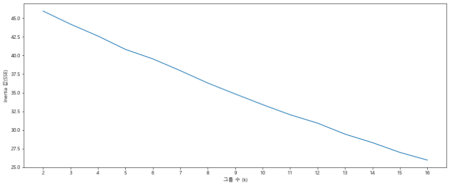

```python
# elbow 기법
# 서로 다른 K개 클러스터 분류의 오차제곱값(SSE)를 확인할 수 있다. 변곡점이 되는 지점에서 K값을 결정하면 된다.
plt.figure(figsize=(15,6))
plt.plot(k_list, inertia_list)
plt.xlabel('그룹 수 (k)')
plt.ylabel('Inertia 값(SSE)')
plt.xticks(k_list)
plt.show()
```

- 11,12,13,14,15

```python
# tf-idf => k=14!
k = 14
kmeans = KMeans(n_clusters=k, random_state=3)
cluster_label = kmeans.fit_predict(X)
```

```python
# 군집화한 레이블값을 compet_start에 추가
compet_start['cluster_label'] = cluster_label
# compet_start.sort_values(by='cluster_label')
```

```python
compet_start['cluster_label'].value_counts().sort_index()
```

```
0     9
1     5
2     5
3     3
4     3
5     2
6     3
7     2
8     2
9     6
10    2
11    3
12    2
13    3
Name: cluster_label, dtype: int64
```

```python
feature_names = cv.get_feature_names()

cluster_details = get_cluster_details(cluster_model=kmeans,
                                    cluster_data=compet_start,
                                    feature_names=feature_names,
                                    cluster_num=k,
                                    top_n_features=8)

print_cluster_details(cluster_details)
```

```
#####Cluster Num: 0
상위 10개 feature단어들:
 ['금융', '신용카드', '입법', '거래', 'nh', '증권', '투자', '병원']
Cluster 0으로 분류된 문서들: ['병원 개/폐업 분류 예측 경진대회', '신용카드 거래 데이터 시각화', 'KCB 금융스타일 시각화 경진대회', '금융 문자 분석 경진대회', '제주 신용카드 빅데이터 경진대회']
--------------------
#####Cluster Num: 1
상위 10개 feature단어들:
 ['전력', '요량', '태양광', '전량', '수요', '기상', '시즌', '프렌즈']
Cluster 1으로 분류된 문서들: ['전력 수요량 예측 경진대회', '공공 데이터 활용 온도 추정 AI 경진대회', '공공 데이터 활용 전력수요 및 SMP 예측 AI 경진대회', '꿈꾸는아이(AI) 전력 수요량 예측 경진대회', '태양광 발전량 예측 AI 경진대회']
--------------------
#####Cluster Num: 2
상위 10개 feature단어들:
 ['객체', '이미지', '위성', '천체', '강수량', '국방', '관측', '우주']
Cluster 2으로 분류된 문서들: ['위성 이미지 객체 검출 경진대회', '천체 유형 분류 대회', '위성관측 데이터 활용 강수량 산출 AI 경진대회 ', '분자구조 이미지 SMILES 변환 AI 경진대회', '아리랑 위성영상 AI 객체 검출 경진대회']
--------------------
#####Cluster Num: 3
상위 10개 feature단어들:
 ['kbo', '타자', 'ops', '스포츠', '투수', '스카우트', 'mlb', '스카우팅']
Cluster 3으로 분류된 문서들: ['KBO 타자 OPS 예측 경진대회', 'KBO 외국인 투수 스카우팅 최적화 경진대회', 'KBO 타자 OPS 시각화 경진대회']
--------------------
#####Cluster Num: 4
상위 10개 feature단어들:
 ['요약', '문서', '소설', 'bflysoft', '한국어', '추출', '작가', '문체']
Cluster 4으로 분류된 문서들: ['소설 작가 분류 AI 경진대회', '한국어 문서 추출요약 AI 경진대회', '한국어 문서 생성요약 AI 경진대회']
--------------------
#####Cluster Num: 5
상위 10개 feature단어들:
 ['버스', '교통', '시간', '운행', '위치', '승객', '승차', '퇴근']
Cluster 5으로 분류된 문서들: ['퇴근시간 버스승차인원 예측 경진대회', '버스 운행시간 예측 경진대회']
--------------------
#####Cluster Num: 6
상위 10개 feature단어들:
 ['코로나', '포스트', '의료', '마이크로소프트', '온라인', '해커', '국토교통부', '국토']
Cluster 6으로 분류된 문서들: ['코로나 데이터 시각화 AI 경진대회', '포스트 코로나 데이터 시각화 경진대회', '국토교통 빅데이터 온라인 해커톤 경진대회']
--------------------
#####Cluster Num: 7
상위 10개 feature단어들:
 ['생체', '광학', '알고리즘', '소리', '음성', '중첩', '목소리', '스타트업']
Cluster 7으로 분류된 문서들: ['생체 광학 데이터 분석 AI 경진대회', '음성 중첩 데이터 분류 AI 경진대회']
--------------------
```

[output cut: 15 more lines]

```
#####Cluster Num: 11
상위 10개 feature단어들:
 ['사용자', '행동', '게임', 'cup', '불편', '시스템', '승패', '스타크래프트']
Cluster 11으로 분류된 문서들: ['행동 데이터 분석 인공지능 AI 경진대회', '2020 DACON CUP', '시스템 품질 변화로 인한 사용자 불편 예지 AI 경진대회']
--------------------
#####Cluster Num: 12
상위 10개 feature단어들:
 ['수력', '강우', '상태', '발전소', '원자력', '원자력발전소', 'log', '판단']
Cluster 12으로 분류된 문서들: ['원자력발전소 상태 판단 경진대회', '공공데이터 활용 수력 댐 강우예측 AI 경진대회']
--------------------
#####Cluster Num: 13
상위 10개 feature단어들:
 ['컴퓨터', '이미지', 'fashion', '랜드마크', 'gap', '세분', '숫자', 'mnist']
Cluster 13으로 분류된 문서들: ['랜드마크 분류 AI 경진대회', '컴퓨터 비전 학습 경진대회', 'K-Fashion AI 경진대회']
--------------------
```

군집

1. 금융/거래/문자, 국회
2. 전력/태양광, 온도
3. 이미지 - 위성/천체, 분자구조
4. 야구(KBO)
5. 문서/소설
6. 버스
7. 코로나
8. 생체/음성
9. 소상공인 매출
10. 제조공정, 산업보안, 심리, 딥페이크/영상
11. 아파트 거래가
12. 사용자 행동
13. 수력/원자력
14. 이미지 - 랜드마크/컴퓨터비전/패션

```python
compet_start[compet_start['cluster_label'] == 0]
```

|  | period_start | prize | name | keyword | document | type | cluster_label |
| --- | --- | --- | --- | --- | --- | --- | --- |
| 1 | 2018-09-15 | 350 | 병원 개/폐업 분류 예측 경진대회 | 금융 \| 병원 재무 데이터와 AI로 개업\|폐업 예측 분석 \| 분류 \| Accuracy | 병원 개/폐업 분류 예측 경진대회 금융 \| 병원 재무 데이터와 AI로 개업\|폐업 예... | 분류 | 0 |
| 4 | 2018-12-25 | 100 | 신용카드 거래 데이터 시각화 | 금융 \| 신용카드, 시계열, 시각화 \| Python, R, Tableau, Spot... | 신용카드 거래 데이터 시각화 금융 \| 신용카드, 시계열, 시각화 \| Python, ... | 시각화 | 0 |
| 7 | 2019-05-06 | 1000 | KCB 금융스타일 시각화 경진대회 | 금융 \| 구인 \| 개인 신용카드 빅데이터 AI 분석 시각화 \| Python, R, ... | KCB 금융스타일 시각화 경진대회 금융 \| 구인 \| 개인 신용카드 빅데이터 AI 분... | 시각화 | 0 |
| 12 | 2019-11-21 | 2000 | 금융 문자 분석 경진대회 | 금융 \| KB금융그룹 \| 금융 Mobile 문자 빅데이터와 AI로 스팸을 분류 \| ... | 금융 문자 분석 경진대회 금융 \| KB금융그룹 \| 금융 Mobile 문자 빅데이터와... | 분류 | 0 |
| 27 | 2020-06-22 | 600 | 제주 신용카드 빅데이터 경진대회 | 금융 \| 제주테크노파크 \| 공공데이터 AI 활용 카드 사용량 예측 \| RMSLE | 제주 신용카드 빅데이터 경진대회 금융 \| 제주테크노파크 \| 공공데이터 AI 활용 카... | 회귀 | 0 |
| 38 | 2020-11-23 | 2500 | AI야 , 진짜 뉴스를 찾아줘! AI 경진대회 | 금융 \| NH투자증권 \| 텍스트 분류 \| Accuracy + Time \| 중복 참가... | AI야 , 진짜 뉴스를 찾아줘! AI 경진대회 금융 \| NH투자증권 \| 텍스트 분... | 분류 | 0 |
| 39 | 2020-11-23 | 2500 | Y&Z세대 투자자 프로파일링 시각화 경진대회 | 금융 \| NH투자증권 \| 시각화 \| 투표 및 심사평가 \| 중복참가 불가, 대학 재학... | Y&Z세대 투자자 프로파일링 시각화 경진대회 금융 \| NH투자증권 \| 시각화 \| 투... | 시각화 | 0 |
| 45 | 2020-11-24 | 100 | 국회 입법활동 빅데이터 시각화 경진대회 | 월간 데이콘 10 \| 입법 \| 시각화 \| 유저평가 | 국회 입법활동 빅데이터 시각화 경진대회 월간 데이콘 10 \| 입법 \| 시각화 \| 유저평가 | 시각화 | 0 |
| 47 | 2020-12-14 | 100 | 공간정보 탐색적 데이터 분석 경진대회 | 국토도시 빅데이터 윈터스쿨 \| 국토연구원 \| 시각화 \| 유저평가 | 공간정보 탐색적 데이터 분석 경진대회 국토도시 빅데이터 윈터스쿨 \| 국토연구원 \| ... | 시각화 | 0 |

```python
compet_start[compet_start['cluster_label'] == 9]
```

|  | period_start | prize | name | keyword | document | type | cluster_label |
| --- | --- | --- | --- | --- | --- | --- | --- |
| 16 | 2020-01-02 | 83 | 반도체 박막 두께 분석 경진대회 | 월간 데이콘 1 \| 산업 \| 반도체 광스펙트럼 빅데이터와 AI로 박막 두께 측정 \|... | 반도체 박막 두께 분석 경진대회 월간 데이콘 1 \| 산업 \| 반도체 광스펙트럼 빅데... | 회귀 | 9 |
| 25 | 2020-06-01 | 600 | 블럭 장난감 제조 공정 최적화 AI경진대회 | 산업 \| LG \| 인공지능 AI 활용 제조 공정 최적화 알고리즘 \| 강화학습 | 블럭 장난감 제조 공정 최적화 AI경진대회 산업 \| LG \| 인공지능 AI 활용 제... | 공정 최적화 | 9 |
| 26 | 2020-06-01 | 600 | 진동데이터 활용 충돌체 탐지 AI 경진대회 | 산업 \| 한국원자력연구원 \| 인공지능 AI 활용 충돌체 탐지 알고리즘 \| MSPE | 진동데이터 활용 충돌체 탐지 AI 경진대회 산업 \| 한국원자력연구원 \| 인공지능 A... | 이상 탐지 | 9 |
| 31 | 2020-08-17 | 2000 | 산업제어시스템 보안위협 탐지 AI 경진대회 | 산업 \| 국가보안기술연구소 \| 인공지능 AI 활용 위협 탐지 알고리즘 \| TaPR ... | 산업제어시스템 보안위협 탐지 AI 경진대회 산업 \| 국가보안기술연구소 \| 인공지능 ... | 이상 탐지 | 9 |
| 36 | 2020-09-28 | 100 | 심리 성향 예측 AI 경진대회 | 월간 데이콘 8 \| 심리 테스트 분석 \| AUC \| 분류 | 심리 성향 예측 AI 경진대회 월간 데이콘 8 \| 심리 테스트 분석 \| AUC \| 분류 | 분류 | 9 |
| 37 | 2020-10-19 | 1000 | 딥페이크 변조 영상 탐지 AI 경진대회 | 서울대 \| 영상 \| GAN \| 분류 \| Accuracy | 딥페이크 변조 영상 탐지 AI 경진대회 서울대 \| 영상 \| GAN \| 분류 \| Ac... | 이미지/영상/음성 식별 | 9 |

## train set과 병합해서 군집별 target 변수 수치 확인

```python
# 필요 컬럼만 남기기
compet_start2 = compet_start[['period_start','cluster_label']].copy()   # 'name'
compet_start2
```

|  | period_start | cluster_label |
| --- | --- | --- |
| 0 | 2018-08-14 | 8 |
| 1 | 2018-09-15 | 0 |
| 2 | 2018-10-18 | 10 |
| 3 | 2018-11-13 | 10 |
| 4 | 2018-12-25 | 0 |
| 5 | 2019-02-08 | 3 |
| 6 | 2019-03-26 | 3 |
| 7 | 2019-05-06 | 0 |
| 8 | 2019-07-11 | 8 |
| 9 | 2019-10-01 | 1 |
| 10 | 2019-11-11 | 5 |
| 11 | 2019-11-11 | 5 |
| 12 | 2019-11-21 | 0 |
| 13 | 2019-11-20 | 2 |
| 14 | 2019-02-05 | 3 |
| 15 | 2020-01-16 | 12 |
| 16 | 2020-01-02 | 9 |
| 17 | 2020-02-01 | 2 |
| 18 | 2020-03-01 | 11 |
| 19 | 2020-03-01 | 1 |
| 20 | 2020-10-20 | 13 |
| 21 | 2020-03-29 | 6 |
| 22 | 2020-04-01 | 2 |
| 23 | 2020-05-01 | 1 |
| 24 | 2020-05-15 | 7 |
| 25 | 2020-06-01 | 9 |
| 26 | 2020-06-01 | 9 |
| 27 | 2020-06-22 | 0 |
| 28 | 2020-06-25 | 7 |
| 29 | 2020-07-01 | 6 |
| 30 | 2020-07-14 | 6 |
| 31 | 2020-08-17 | 9 |
| 32 | 2020-08-03 | 13 |
| 33 | 2020-09-01 | 2 |
| 34 | 2020-09-23 | 2 |
| 35 | 2020-10-05 | 12 |
| 36 | 2020-09-28 | 9 |
| 37 | 2020-10-19 | 9 |
| 38 | 2020-11-23 | 0 |
| 39 | 2020-11-23 | 0 |
| 40 | 2020-10-29 | 1 |
| 41 | 2020-10-29 | 4 |
| 42 | 2020-11-11 | 4 |
| 43 | 2020-11-02 | 13 |
| 44 | 2020-11-11 | 4 |
| 45 | 2020-11-24 | 0 |
| 46 | 2020-12-09 | 1 |
| 47 | 2020-12-14 | 0 |
| 48 | 2020-12-18 | 11 |
| 49 | 2021-01-06 | 11 |

```python
tmp = compet_start2.groupby('period_start')[['cluster_label']].count().reset_index()
tmp.columns = ['period_start', 'cnt']
```

```python
# 해당일 대회 개수와 join
compet_start2 = pd.merge(compet_start2, tmp, on='period_start', how='left')
compet_start2
```

|  | period_start | cluster_label | cnt |
| --- | --- | --- | --- |
| 0 | 2018-08-14 | 8 | 1 |
| 1 | 2018-09-15 | 0 | 1 |
| 2 | 2018-10-18 | 10 | 1 |
| 3 | 2018-11-13 | 10 | 1 |
| 4 | 2018-12-25 | 0 | 1 |
| 5 | 2019-02-08 | 3 | 1 |
| 6 | 2019-03-26 | 3 | 1 |
| 7 | 2019-05-06 | 0 | 1 |
| 8 | 2019-07-11 | 8 | 1 |
| 9 | 2019-10-01 | 1 | 1 |
| 10 | 2019-11-11 | 5 | 2 |
| 11 | 2019-11-11 | 5 | 2 |
| 12 | 2019-11-21 | 0 | 1 |
| 13 | 2019-11-20 | 2 | 1 |
| 14 | 2019-02-05 | 3 | 1 |
| 15 | 2020-01-16 | 12 | 1 |
| 16 | 2020-01-02 | 9 | 1 |
| 17 | 2020-02-01 | 2 | 1 |
| 18 | 2020-03-01 | 11 | 2 |
| 19 | 2020-03-01 | 1 | 2 |
| 20 | 2020-10-20 | 13 | 1 |
| 21 | 2020-03-29 | 6 | 1 |
| 22 | 2020-04-01 | 2 | 1 |
| 23 | 2020-05-01 | 1 | 1 |
| 24 | 2020-05-15 | 7 | 1 |
| 25 | 2020-06-01 | 9 | 2 |
| 26 | 2020-06-01 | 9 | 2 |
| 27 | 2020-06-22 | 0 | 1 |
| 28 | 2020-06-25 | 7 | 1 |
| 29 | 2020-07-01 | 6 | 1 |
| 30 | 2020-07-14 | 6 | 1 |
| 31 | 2020-08-17 | 9 | 1 |
| 32 | 2020-08-03 | 13 | 1 |
| 33 | 2020-09-01 | 2 | 1 |
| 34 | 2020-09-23 | 2 | 1 |
| 35 | 2020-10-05 | 12 | 1 |
| 36 | 2020-09-28 | 9 | 1 |
| 37 | 2020-10-19 | 9 | 1 |
| 38 | 2020-11-23 | 0 | 2 |
| 39 | 2020-11-23 | 0 | 2 |
| 40 | 2020-10-29 | 1 | 2 |
| 41 | 2020-10-29 | 4 | 2 |
| 42 | 2020-11-11 | 4 | 2 |
| 43 | 2020-11-02 | 13 | 1 |
| 44 | 2020-11-11 | 4 | 2 |
| 45 | 2020-11-24 | 0 | 1 |
| 46 | 2020-12-09 | 1 | 1 |
| 47 | 2020-12-14 | 0 | 1 |
| 48 | 2020-12-18 | 11 | 1 |
| 49 | 2021-01-06 | 11 | 1 |

```python
compet_start2[compet_start2['cnt'] == 2]
```

|  | period_start | cluster_label | cnt |
| --- | --- | --- | --- |
| 10 | 2019-11-11 | 5 | 2 |
| 11 | 2019-11-11 | 5 | 2 |
| 18 | 2020-03-01 | 11 | 2 |
| 19 | 2020-03-01 | 1 | 2 |
| 25 | 2020-06-01 | 9 | 2 |
| 26 | 2020-06-01 | 9 | 2 |
| 38 | 2020-11-23 | 0 | 2 |
| 39 | 2020-11-23 | 0 | 2 |
| 40 | 2020-10-29 | 1 | 2 |
| 41 | 2020-10-29 | 4 | 2 |
| 42 | 2020-11-11 | 4 | 2 |
| 44 | 2020-11-11 | 4 | 2 |

```python
# 대회 2개 개최된 날 제거
print(compet_start2.shape)
compet_start2.drop(compet_start2[compet_start2['cnt'] == 2].index, inplace=True)
compet_start2.shape
```

```
(50, 3)
```

```
(38, 3)
```

```python
# cnt column 제거
compet_start2.drop('cnt', inplace=True, axis=1)
```

```python
# 컬럼 이름 변경
compet_start2.columns = ['ds','label'] #  'name'
```

```python
# train2와 병합
train2 = pd.merge(train2, compet_start2, on='ds', how='left')
train2
```

|  | ds | 사용자 | 세션 | 신규방문자 | 페이지뷰 | year | month | week | holiday | period_start | period_end | merge_deadline | type | prize | name | cnt | label |
| --- | --- | --- | --- | --- | --- | --- | --- | --- | --- | --- | --- | --- | --- | --- | --- | --- | --- |
| 0 | 2018-09-09 | 281 | 266 | 73 | 1826 | 2018 | 9 | 6 | 0 | 0 | 0 | 0 | NaN | NaN | NaN | NaN | NaN |
| 1 | 2018-09-10 | 264 | 247 | 51 | 2092 | 2018 | 9 | 0 | 0 | 0 | 0 | 0 | NaN | NaN | NaN | NaN | NaN |
| 2 | 2018-09-11 | 329 | 310 | 58 | 1998 | 2018 | 9 | 1 | 0 | 0 | 0 | 0 | NaN | NaN | NaN | NaN | NaN |
| 3 | 2018-09-12 | 300 | 287 | 45 | 2595 | 2018 | 9 | 2 | 0 | 0 | 0 | 0 | NaN | NaN | NaN | NaN | NaN |
| 4 | 2018-09-13 | 378 | 344 | 50 | 3845 | 2018 | 9 | 3 | 0 | 0 | 1 | 1 | NaN | NaN | NaN | NaN | NaN |
| ... | ... | ... | ... | ... | ... | ... | ... | ... | ... | ... | ... | ... | ... | ... | ... | ... | ... |
| 817 | 2020-12-04 | 3189 | 3068 | 743 | 75730 | 2020 | 12 | 4 | 0 | 0 | 1 | 0 | NaN | NaN | NaN | NaN | NaN |
| 818 | 2020-12-05 | 2055 | 2019 | 497 | 47638 | 2020 | 12 | 5 | 0 | 0 | 0 | 0 | NaN | NaN | NaN | NaN | NaN |
| 819 | 2020-12-06 | 2119 | 2077 | 460 | 46914 | 2020 | 12 | 6 | 0 | 0 | 0 | 0 | NaN | NaN | NaN | NaN | NaN |
| 820 | 2020-12-07 | 2979 | 2988 | 753 | 77443 | 2020 | 12 | 0 | 0 | 0 | 0 | 0 | NaN | NaN | NaN | NaN | NaN |
| 821 | 2020-12-08 | 3033 | 2990 | 772 | 68857 | 2020 | 12 | 1 | 0 | 0 | 0 | 0 | NaN | NaN | NaN | NaN | NaN |

822 rows × 17 columns

```python
train2['label'].value_counts()
```

```
0.0     6
2.0     5
9.0     4
3.0     3
13.0    3
6.0     3
10.0    2
12.0    2
7.0     2
1.0     2
8.0     1
Name: label, dtype: int64
```

```python
# period_start - box plot
fig = make_subplots(
    rows=2, cols=2,
    subplot_titles=('사용자','세션','신규방문자','페이지뷰'), horizontal_spacing=0.08, vertical_spacing=0.12
)
fig.add_trace(go.Box(x=train2['label'], y=train2['사용자'],boxpoints='all',name="사용자",showlegend=False), row=1, col=1)
fig.add_trace(go.Box(x=train2['label'], y=train2['세션'],boxpoints='all',name="세션",showlegend=False), row=1, col=2)
fig.add_trace(go.Box(x=train2['label'], y=train2['신규방문자'],boxpoints='all',name="신규방문자",showlegend=False), row=2, col=1)
fig.add_trace(go.Box(x=train2['label'], y=train2['페이지뷰'],boxpoints='all',name="페이지뷰",showlegend=False), row=2, col=2)
fig.update_layout(height=600, width=1100, template='plotly_white', title_text='대회 시작일')  # template='ggplot2'
fig.show()
```

[interactive chart not shown]

- 0,1,3,8,10번 군집 일부 상대적으로 낮게 나타남
- 0,8,10은 크게 보면 금융쪽임

```python
# period_start - box plot  # 2020년만
tmp = train2[train2['ds'].str.contains('2020')].copy()

fig = make_subplots(
    rows=2, cols=2,
    subplot_titles=('사용자','세션','신규방문자','페이지뷰'), horizontal_spacing=0.08, vertical_spacing=0.12
)
fig.add_trace(go.Box(x=tmp['label'], y=tmp['사용자'],name="사용자",showlegend=False), row=1, col=1)
fig.add_trace(go.Box(x=tmp['label'], y=tmp['세션'],name="세션",showlegend=False), row=1, col=2)
fig.add_trace(go.Box(x=tmp['label'], y=tmp['신규방문자'],name="신규방문자",showlegend=False), row=2, col=1)
fig.add_trace(go.Box(x=tmp['label'], y=tmp['페이지뷰'],name="페이지뷰",showlegend=False), row=2, col=2)
fig.update_layout(height=600, width=1100, template='plotly_white', title_text='대회 시작일')  # template='ggplot2'
fig.show()
```

[interactive chart not shown]

- 군집 1이 가장 낮음

## 대회 주제별 확인

```python
label_list = list(train2['label'].unique())
label_list
```

```
[nan, 0.0, 10.0, 3.0, 8.0, 1.0, 2.0, 9.0, 12.0, 6.0, 7.0, 13.0]
```

```python
label_list = label_list[1:].copy()   # nan 제외
label_list
```

```
[0.0, 10.0, 3.0, 8.0, 1.0, 2.0, 9.0, 12.0, 6.0, 7.0, 13.0]
```

```python
for label in label_list:
    print(label)
    # 해당 군집만 + 주말/공휴일 제외
    tmp = train2[(train2['label'] == label) & (train2['week'] != 5) & (train2['week'] != 6) & (train2['holiday'] != 1)][['ds','name','사용자','세션','신규방문자','페이지뷰']].copy()

    # 추이 & event_point
    fig = make_subplots(
        rows=2, cols=2,
        subplot_titles=('사용자','세션','신규방문자','페이지뷰'), horizontal_spacing=0.08, vertical_spacing=0.12
    )
    fig.add_trace(go.Scatter(x=train['ds'], y=train['사용자'],name="사용자",showlegend=True, line=dict(color='#BDBDBD')), row=1, col=1)
    fig.add_trace(go.Scatter(x=tmp['ds'], y = tmp['사용자'], text=tmp['name'], hoverinfo=['x','text'], mode = 'markers', name = '대회 시작일', marker=dict(size=5)), row=1, col=1)

    fig.add_trace(go.Scatter(x=train['ds'], y=train['세션'],name="세션",showlegend=True, line=dict(color='#f08069')), row=1, col=2)
    fig.add_trace(go.Scatter(x=tmp['ds'], y = tmp['세션'], text=tmp['name'], hoverinfo=['x','text'], mode = 'markers', name = '대회 시작일', marker=dict(size=5)), row=1, col=2)

    fig.add_trace(go.Scatter(x=train['ds'], y=train['신규방문자'],name="신규방문자",showlegend=True, line=dict(color='#edab4e')), row=2, col=1)
    fig.add_trace(go.Scatter(x=tmp['ds'], y = tmp['신규방문자'], text=tmp['name'], hoverinfo=['x','text'], mode = 'markers', name = '대회 시작일', marker=dict(size=5)), row=2, col=1)

    fig.add_trace(go.Scatter(x=train['ds'], y=train['페이지뷰'],name="페이지뷰",showlegend=True, line=dict(color='#89d69e')), row=2, col=2)
    fig.add_trace(go.Scatter(x=tmp['ds'], y = tmp['페이지뷰'], text=tmp['name'], hoverinfo=['x','text'], mode = 'markers', name = '대회 시작일', marker=dict(size=5, color='#f08069')), row=2, col=2)

    fig.update_layout(height=600, width =1100, template='plotly_white', title_text='대회 시작일')  # template='ggplot2'
    fig.show()
```

```
0.0
```

[interactive chart not shown]

```
10.0
```

[interactive chart not shown]

```
3.0
```

[interactive chart not shown]

```
8.0
```

[interactive chart not shown]

```
1.0
```

[interactive chart not shown]

```
2.0
```

[interactive chart not shown]

```
9.0
```

[interactive chart not shown]

```
12.0
```

[interactive chart not shown]

```
6.0
```

[interactive chart not shown]

```
7.0
```

[interactive chart not shown]

```
13.0
```

[interactive chart not shown]

## 대회 상금과 함께 시각화

```python
tmp = train2[train2['label'].notnull()].copy()

fig = go.Figure(data=px.scatter(tmp, x="prize", y="사용자", color="label", hover_name='name'))
fig.update_layout(template='plotly_white', title_text='사용자')
fig.show()
```

[interactive chart not shown]

##### 주말/공휴일 제외

```python
tmp = train2[(train2['label'].notnull()) & (train2['week'] != 5) & (train2['week'] != 6) & (train2['holiday'] != 1)].copy()

fig = go.Figure(data=px.scatter(tmp, x="prize", y="사용자", color="label", hover_name='name'))
fig.update_layout(template='plotly_white', title_text='사용자')
fig.show()
```

[interactive chart not shown]

```python
tmp.shape
```

```
(27, 17)
```

```python
# 2019년만
tmp = train2[(train2['label'].notnull()) & (train2['week'] != 5) & (train2['week'] != 6) & (train2['holiday'] != 1)].copy()
tmp = tmp[tmp['ds'].str.contains('2019')].copy()

fig = go.Figure(data=px.scatter(tmp, x="prize", y="사용자", color="label", hover_name='name'))
fig.update_layout(template='plotly_white', title_text='사용자')
fig.show()
```

[interactive chart not shown]

```python
# 2020년만
tmp = train2[(train2['label'].notnull()) & (train2['week'] != 5) & (train2['week'] != 6) & (train2['holiday'] != 1)].copy()
tmp = tmp[tmp['ds'].str.contains('2020')].copy()

fig = go.Figure(data=px.scatter(tmp, x="prize", y="사용자", color="label", hover_name='name'))
fig.update_layout(template='plotly_white', title_text='사용자')
fig.show()
```

[interactive chart not shown]

- 특정 대회 주제에서 낮은 수치를 보이지는 않는 것 같음

# 가설 1,2 합치기 및 최종 시각화

```python
train_final = pd.read_csv('data/train_final.csv', encoding='cp949')
train_final
```

|  | ds | 사용자 | 세션 | 신규방문자 | 페이지뷰 | year | month | week | holiday | period_start | period_end | merge_deadline |
| --- | --- | --- | --- | --- | --- | --- | --- | --- | --- | --- | --- | --- |
| 0 | 2018-09-09 | 281 | 266 | 73 | 1826 | 2018 | 9 | 6 | 0 | 0 | 0 | 0 |
| 1 | 2018-09-10 | 264 | 247 | 51 | 2092 | 2018 | 9 | 0 | 0 | 0 | 0 | 0 |
| 2 | 2018-09-11 | 329 | 310 | 58 | 1998 | 2018 | 9 | 1 | 0 | 0 | 0 | 0 |
| 3 | 2018-09-12 | 300 | 287 | 45 | 2595 | 2018 | 9 | 2 | 0 | 0 | 0 | 0 |
| 4 | 2018-09-13 | 378 | 344 | 50 | 3845 | 2018 | 9 | 3 | 0 | 0 | 1 | 1 |
| ... | ... | ... | ... | ... | ... | ... | ... | ... | ... | ... | ... | ... |
| 817 | 2020-12-04 | 3189 | 3068 | 743 | 75730 | 2020 | 12 | 4 | 0 | 0 | 1 | 0 |
| 818 | 2020-12-05 | 2055 | 2019 | 497 | 47638 | 2020 | 12 | 5 | 0 | 0 | 0 | 0 |
| 819 | 2020-12-06 | 2119 | 2077 | 460 | 46914 | 2020 | 12 | 6 | 0 | 0 | 0 | 0 |
| 820 | 2020-12-07 | 2979 | 2988 | 753 | 77443 | 2020 | 12 | 0 | 0 | 0 | 0 | 0 |
| 821 | 2020-12-08 | 3033 | 2990 | 772 | 68857 | 2020 | 12 | 1 | 0 | 0 | 0 | 0 |

822 rows × 12 columns

```python
# 가설2의 '대회 유형 회귀 + 상금 250만원 이하'에 해당하는 대회 시작일을 4로 labeling
# '2019-03-26','2019-07-11','2020-01-02','2020-05-01'
train_final.loc[train_final['ds'] == '2019-03-26', 'period_start'] = 4
train_final.loc[train_final['ds'] == '2019-07-11', 'period_start'] = 4
train_final.loc[train_final['ds'] == '2020-01-02', 'period_start'] = 4
train_final.loc[train_final['ds'] == '2020-05-01', 'period_start'] = 4
```

```python
train_final['period_start'].value_counts()
```

```
0    783
1     23
2      6
3      6
4      4
Name: period_start, dtype: int64
```

##### 대회 시작일

```python
tmp = train_final[(train_final['period_start'] == 1) | (train_final['period_start'] == 2)][['ds','사용자','세션','신규방문자','페이지뷰']].copy()
tmp2 = train_final[(train_final['period_start'] == 3) | (train_final['period_start'] == 4)][['ds','사용자','세션','신규방문자','페이지뷰']].copy()

# 추이 & event_point
fig = make_subplots(
    rows=2, cols=2,
    subplot_titles=('사용자','세션','신규방문자','페이지뷰'), horizontal_spacing=0.08, vertical_spacing=0.12
)
fig.add_trace(go.Scatter(x=train_final['ds'], y=train_final['사용자'],name="사용자",showlegend=True, line=dict(color='#BDBDBD')), row=1, col=1)
fig.add_trace(go.Scatter(x=tmp['ds'], y = tmp['사용자'], mode = 'markers', name = '대회 시작일', marker=dict(size=5)), row=1, col=1)
fig.add_trace(go.Scatter(x=tmp2['ds'], y = tmp2['사용자'], mode = 'markers', name = '대회 시작일(낮은 경향성)', marker=dict(size=5, color='#0091EA')), row=1, col=1)


fig.add_trace(go.Scatter(x=train_final['ds'], y=train_final['세션'],name="세션",showlegend=False, line=dict(color='#f08069')), row=1, col=2)
fig.add_trace(go.Scatter(x=tmp['ds'], y = tmp['세션'], mode = 'markers', name = '대회 시작일', marker=dict(size=5)), row=1, col=2)
fig.add_trace(go.Scatter(x=tmp2['ds'], y = tmp2['세션'], mode = 'markers', name = '대회 시작일', marker=dict(size=5, color='#9932CC')), row=1, col=2)

fig.add_trace(go.Scatter(x=train_final['ds'], y=train_final['신규방문자'],name="신규방문자",showlegend=False, line=dict(color='#edab4e')), row=2, col=1)
fig.add_trace(go.Scatter(x=tmp['ds'], y = tmp['신규방문자'], mode = 'markers', name = '대회 시작일', marker=dict(size=5)), row=2, col=1)
fig.add_trace(go.Scatter(x=tmp2['ds'], y = tmp2['신규방문자'], mode = 'markers', name = '대회 시작일', marker=dict(size=5, color='#9932CC')), row=2, col=1)

fig.add_trace(go.Scatter(x=train_final['ds'], y=train_final['페이지뷰'],name="페이지뷰",showlegend=False, line=dict(color='#89d69e')), row=2, col=2)
fig.add_trace(go.Scatter(x=tmp['ds'], y = tmp['페이지뷰'], mode = 'markers', name = '대회 시작일', marker=dict(size=5, color='#f08069')), row=2, col=2)
fig.add_trace(go.Scatter(x=tmp2['ds'], y = tmp2['페이지뷰'], mode = 'markers', name = '대회 시작일', marker=dict(size=5, color='#9932CC')), row=2, col=2)

fig.update_layout(height=600, width =1100, template='plotly_white', title_text='대회 시작일')
fig.show()
```

[interactive chart not shown]

##### 대회 종료일

```python
tmp = train_final[(train_final['period_end'] == 1) | (train_final['period_end'] == 2)][['ds','사용자','세션','신규방문자','페이지뷰']].copy()
tmp2 = train_final[(train_final['period_end'] == 3)][['ds','사용자','세션','신규방문자','페이지뷰']].copy()

# 추이 & event_point
fig = make_subplots(
    rows=2, cols=2,
    subplot_titles=('사용자','세션','신규방문자','페이지뷰'), horizontal_spacing=0.08, vertical_spacing=0.12
)
fig.add_trace(go.Scatter(x=train_final['ds'], y=train_final['사용자'],name="사용자",showlegend=True, line=dict(color='#BDBDBD')), row=1, col=1)
fig.add_trace(go.Scatter(x=tmp['ds'], y = tmp['사용자'], mode = 'markers', name = '대회 종료일', marker=dict(size=5)), row=1, col=1)
fig.add_trace(go.Scatter(x=tmp2['ds'], y = tmp2['사용자'], mode = 'markers', name = '대회 종료일(낮은 경향성)', marker=dict(size=5, color='#0091EA')), row=1, col=1)


fig.add_trace(go.Scatter(x=train_final['ds'], y=train_final['세션'],name="세션",showlegend=False, line=dict(color='#f08069')), row=1, col=2)
fig.add_trace(go.Scatter(x=tmp['ds'], y = tmp['세션'], mode = 'markers', name = '대회 종료일', marker=dict(size=5)), row=1, col=2)
fig.add_trace(go.Scatter(x=tmp2['ds'], y = tmp2['세션'], mode = 'markers', name = '대회 종료일', marker=dict(size=5, color='#9932CC')), row=1, col=2)

fig.add_trace(go.Scatter(x=train_final['ds'], y=train_final['신규방문자'],name="신규방문자",showlegend=False, line=dict(color='#edab4e')), row=2, col=1)
fig.add_trace(go.Scatter(x=tmp['ds'], y = tmp['신규방문자'], mode = 'markers', name = '대회 종료일', marker=dict(size=5)), row=2, col=1)
fig.add_trace(go.Scatter(x=tmp2['ds'], y = tmp2['신규방문자'], mode = 'markers', name = '대회 종료일', marker=dict(size=5, color='#9932CC')), row=2, col=1)

fig.add_trace(go.Scatter(x=train_final['ds'], y=train_final['페이지뷰'],name="페이지뷰",showlegend=False, line=dict(color='#89d69e')), row=2, col=2)
fig.add_trace(go.Scatter(x=tmp['ds'], y = tmp['페이지뷰'], mode = 'markers', name = '대회 종료일', marker=dict(size=5, color='#f08069')), row=2, col=2)
fig.add_trace(go.Scatter(x=tmp2['ds'], y = tmp2['페이지뷰'], mode = 'markers', name = '대회 종료일', marker=dict(size=5, color='#9932CC')), row=2, col=2)

fig.update_layout(height=600, width =1100, template='plotly_white', title_text='대회 종료일')
fig.show()
```

[interactive chart not shown]

##### 팀병합 마감일

```python
tmp = train_final[(train_final['merge_deadline'] == 1) | (train_final['merge_deadline'] == 2)][['ds','사용자','세션','신규방문자','페이지뷰']].copy()
tmp2 = train_final[(train_final['merge_deadline'] == 3)][['ds','사용자','세션','신규방문자','페이지뷰']].copy()

# 추이 & event_point
fig = make_subplots(
    rows=2, cols=2,
    subplot_titles=('사용자','세션','신규방문자','페이지뷰'), horizontal_spacing=0.08, vertical_spacing=0.12
)
fig.add_trace(go.Scatter(x=train_final['ds'], y=train_final['사용자'],name="사용자",showlegend=True, line=dict(color='#BDBDBD')), row=1, col=1)
fig.add_trace(go.Scatter(x=tmp['ds'], y = tmp['사용자'], mode = 'markers', name = '팀병합 마감일', marker=dict(size=5)), row=1, col=1)
fig.add_trace(go.Scatter(x=tmp2['ds'], y = tmp2['사용자'], mode = 'markers', name = '팀병합 마감일(낮은 경향성)', marker=dict(size=5, color='#0091EA')), row=1, col=1)


fig.add_trace(go.Scatter(x=train_final['ds'], y=train_final['세션'],name="세션",showlegend=False, line=dict(color='#f08069')), row=1, col=2)
fig.add_trace(go.Scatter(x=tmp['ds'], y = tmp['세션'], mode = 'markers', name = '팀병합 마감일', marker=dict(size=5)), row=1, col=2)
fig.add_trace(go.Scatter(x=tmp2['ds'], y = tmp2['세션'], mode = 'markers', name = '팀병합 마감일', marker=dict(size=5, color='#9932CC')), row=1, col=2)

fig.add_trace(go.Scatter(x=train_final['ds'], y=train_final['신규방문자'],name="신규방문자",showlegend=False, line=dict(color='#edab4e')), row=2, col=1)
fig.add_trace(go.Scatter(x=tmp['ds'], y = tmp['신규방문자'], mode = 'markers', name = '팀병합 마감일', marker=dict(size=5)), row=2, col=1)
fig.add_trace(go.Scatter(x=tmp2['ds'], y = tmp2['신규방문자'], mode = 'markers', name = '팀병합 마감일', marker=dict(size=5, color='#9932CC')), row=2, col=1)

fig.add_trace(go.Scatter(x=train_final['ds'], y=train_final['페이지뷰'],name="페이지뷰",showlegend=False, line=dict(color='#89d69e')), row=2, col=2)
fig.add_trace(go.Scatter(x=tmp['ds'], y = tmp['페이지뷰'], mode = 'markers', name = '팀병합 마감일', marker=dict(size=5, color='#f08069')), row=2, col=2)
fig.add_trace(go.Scatter(x=tmp2['ds'], y = tmp2['페이지뷰'], mode = 'markers', name = '팀병합 마감일', marker=dict(size=5, color='#9932CC')), row=2, col=2)

fig.update_layout(height=600, width =1100, template='plotly_white', title_text='팀병합 마감일')
fig.show()
```

[interactive chart not shown]

```python
train_final.to_csv('data/train_final2.csv', index=False, encoding='cp949')
```